# Supervised Learning : Clinical Research Prediction Model Development and Evaluation for Prognosis

[John Pauline Pineda](https://github.com/JohnPaulinePineda)

2022-09-14

# **1. Table of Contents**

This project explores the best practices when developing and evaluating prognostic models for clinical research using various helpful packages in **R**. The methods and results presented in the chapter entitled **Case Study on Survival Analysis: Prediction of Cardiovascular Events** using the **Second Manifestations of Arterial Diseases (SMART)** dataset from the book [**Clinical Prediction Models**](http://clinicalpredictionmodels.org/) were replicated. The general requirements for the clinical study were defined including the formulation of the research question, intended application, outcome, predictors, study design, statistical model and sample size computation. The individual steps involved in model development were presented including the data quality assessment, predictor coding, data preprocessing, as well as the specification, selection, performance estimation, performance validation and presentation of the model used in the study. Additional details on model validity evaluation was also provided. All results were consolidated in a **Summary** presented at the end of the document.  
**Clinical Prediction Models** estimate the risk of existing disease (diagnostic prediction model) or future outcome (prognostic prediction model) for an individual, which is conditional on the values of multiple predictors (prognostic or risk factors) such as clinicopathological characteristics and biomarkers. As an explicit and empirical approach to estimating probabilities or outcomes of a disease, these models relate to evidence-based medicine which aims to use the current best evidence in making decisions about the care of individual patients. Evidence-based medicine applies the scientific method to medical practice. Its laudable intentions are to make clinical practice more scientific and empirically grounded and thereby achieving safer, more consistent, and more cost-effective care.  
Various guidelines such as the [**TRIPOD**](https://www.acpjournals.org/doi/10.7326/M14-0698) (**Transparent Reporting of a Multivariable Prediction Model for Individual Prognosis Or Diagnosis**), [**STARD**](https://www.equator-network.org/reporting-guidelines/stard/) (**Standards for Reporting Diagnostic Accuracy Studies**) and [**PROBAST**](https://www.acpjournals.org/doi/10.7326/M18-1377) (**Prediction Model Risk of Bias Assessment Tool**) have been formulated which aim to improve the transparency in the reporting of clinical research studies developing, validating, or updating multivariable prediction models, whether for diagnostic or prognostic purposes.  
Multivariable prediction models fall into two broad categories: diagnostic and prognostic prediction models. In both the diagnostic and prognostic setting, probability estimates are commonly based on combining information from multiple predictors observed or measured from an individual. In a diagnostic model, multiple predictors (often referred to as diagnostic test results) are combined to estimate the probability that a certain condition or disease is present (or absent) at the moment of prediction. In a prognostic model, multiple predictors are combined to estimate the probability of a particular outcome or event (for example, mortality, disease recurrence, complication, or therapy response) occurring in a certain period in the future. In virtually all medical domains, diagnostic and prognostic multivariable (risk) prediction models are being developed, validated, updated, and implemented with the aim to assist doctors and individuals in estimating probabilities and potentially influence their decision making.

## 1.1 General Considerations

### 1.1.1 Research Question

The aim of the study was to develop a prediction model for long term outcome. Given the available follow-up, the yearly risks could be assessed reliably. Achieving adequate predictions was more prominent than insight in the predictor effects.

### 1.1.2 Intended Application

The intended application of the study was more toward clinical practice rather than experimental research - particularly on inpatient counseling where a high absolute risk might motivate patients to change inappropriate lifestyles and to comply with their medication regimens.

### 1.1.3 Outcome

The primary outcome was any cardiovascular event, comprised of cardiovascular death, non-fatal stroke, and non-fatal myocardial infarction. Combining different events was made to increase statistical power (which is a common approach for vascular research).

### 1.1.4 Predictors

The selection of predictors was motivated by characteristics included in the [Framingham](https://pubmed.ncbi.nlm.nih.gov/5921755/) and [SCORE](https://pubmed.ncbi.nlm.nih.gov/12788299/) models. The relationship with future events has also been established for several traditional risk factors, including hyperhomocysteinemia, intima-media thickness (IMT) and creatinine. Other candidate predictors were demographics (sex and age) and risk factors for vascular events in the general population (smoking, alcohol use, body mass index, diastolic and systolic blood pressure, lipids and diabetes). In addition, indicators of atherosclerosis were added as relevant predictors in the study including location of symptomatic vascular disease (cerebral, coronary, peripheral arterial disease or abdominal aortic aneurysm (AAA)) and markers of the extent of atherosclerosis (homocysteine, creatinine, albumin, intima-media thickness (IMT) and presence of carotid artery stenosis).

### 1.1.5 Study Design

The study was designed as a prospective dynamic cohort study. Patients were enrolled when presenting at the hospital with follow-up starting from study inclusion.

### 1.1.6 Statistical Model

The default statistical model for survival outcomes - Cox proportional hazard regression model was used which was deemed appropriate for such a relatively short-term study as 5-year cumulative incidence of cardiovascular events.

## 1.2 Modelling Steps

### 1.2.1 Sample Data

**Code Chunk | Output**

```r
##################################
# Loading R libraries
##################################
library("survival")
library("survminer")
library("mice")
library("foreign")
library("rms")
library("Hmisc")
library("VIM")
library("gridExtra")
library("finalfit")
library("knitr")
library("dplyr")
library("gtsummary")
library("tidyr")
library("purrr")
library("moments")
library("lattice")

##################################
# Defining file paths
##################################
DATASETS_PATH <- file.path("datasets")

##################################
# Loading dataset
##################################
SMART <- read.spss(file.path("..", DATASETS_PATH, "SMARTst.sav"),
                   use.value.labels=F,
                   to.data.frame=T)

##################################
# Performing a general exploration of the dataset
##################################
dim(SMART)
```

```
## [1] 3873   29
```

```r
summary(SMART)
```

```
##      TEVENT           EVENT             SEX             AGE
##  Min.   :   0.1   Min.   :0.0000   Min.   :1.000   Min.   :19.00
##  1st Qu.: 555.0   1st Qu.:0.0000   1st Qu.:1.000   1st Qu.:52.00
##  Median :1213.0   Median :0.0000   Median :1.000   Median :60.00
##  Mean   :1370.3   Mean   :0.1188   Mean   :1.252   Mean   :59.56
##  3rd Qu.:2165.0   3rd Qu.:0.0000   3rd Qu.:2.000   3rd Qu.:68.00
##  Max.   :3466.0   Max.   :1.0000   Max.   :2.000   Max.   :82.00
##
##     DIABETES         CEREBRAL         CARDIAC            AAA
##  Min.   :0.0000   Min.   :0.0000   Min.   :0.0000   Min.   :0.0000
##  1st Qu.:0.0000   1st Qu.:0.0000   1st Qu.:0.0000   1st Qu.:0.0000
##  Median :0.0000   Median :0.0000   Median :1.0000   Median :0.0000
##  Mean   :0.2207   Mean   :0.2962   Mean   :0.5577   Mean   :0.1074
##  3rd Qu.:0.0000   3rd Qu.:1.0000   3rd Qu.:1.0000   3rd Qu.:0.0000
##  Max.   :1.0000   Max.   :1.0000   Max.   :1.0000   Max.   :1.0000
##  NA's   :40
##      PERIPH          STENOSIS         SYSTBP         DIASTBP
##  Min.   :0.0000   Min.   :0.000   Min.   : 96.0   Min.   : 46.0
##  1st Qu.:0.0000   1st Qu.:0.000   1st Qu.:127.0   1st Qu.: 73.0
##  Median :0.0000   Median :0.000   Median :139.0   Median : 79.0
##  Mean   :0.2427   Mean   :0.191   Mean   :141.3   Mean   : 79.7
##  3rd Qu.:0.0000   3rd Qu.:0.000   3rd Qu.:154.0   3rd Qu.: 86.0
##  Max.   :1.0000   Max.   :1.000   Max.   :216.0   Max.   :127.0
##                   NA's   :93      NA's   :1223    NA's   :1221
##      SYSTH           DIASTH           LENGTH         WEIGHT         BMI
##  Min.   : 79.0   Min.   : 45.00   Min.   :1.53   Min.   : 50   Min.   :18.70
##  1st Qu.:126.0   1st Qu.: 75.00   1st Qu.:1.68   1st Qu.: 72   1st Qu.:24.11
##  Median :140.0   Median : 82.00   Median :1.75   Median : 80   Median :26.30
##  Mean   :142.2   Mean   : 82.44   Mean   :1.74   Mean   : 81   Mean   :26.70
##  3rd Qu.:156.0   3rd Qu.: 90.00   3rd Qu.:1.80   3rd Qu.: 89   3rd Qu.:28.73
##  Max.   :244.0   Max.   :136.00   Max.   :1.94   Max.   :124   Max.   :39.80
##  NA's   :1498    NA's   :1499     NA's   :1      NA's   :2     NA's   :3
##       CHOL            HDL            LDL             TRIG           HOMOC
##  Min.   :2.800   Min.   :0.58   Min.   :1.100   Min.   :0.560   Min.   : 6.10
##  1st Qu.:4.400   1st Qu.:0.96   1st Qu.:2.390   1st Qu.:1.120   1st Qu.:10.32
##  Median :5.100   Median :1.17   Median :3.060   Median :1.540   Median :12.80
##  Mean   :5.191   Mean   :1.23   Mean   :3.144   Mean   :1.854   Mean   :13.84
##  3rd Qu.:5.900   3rd Qu.:1.42   3rd Qu.:3.830   3rd Qu.:2.230   3rd Qu.:15.70
##  Max.   :9.400   Max.   :2.51   Max.   :6.600   Max.   :8.960   Max.   :38.30
##  NA's   :18      NA's   :30     NA's   :216     NA's   :28      NA's   :463
##       GLUT            CREAT             IMT            albumin
##  Min.   : 4.300   Min.   : 54.00   Min.   :0.4700   Min.   :1.000
##  1st Qu.: 5.300   1st Qu.: 78.00   1st Qu.:0.7500   1st Qu.:1.000
##  Median : 5.700   Median : 89.00   Median :0.8800   Median :1.000
##  Mean   : 6.333   Mean   : 98.39   Mean   :0.9346   Mean   :1.241
##  3rd Qu.: 6.500   3rd Qu.:101.00   3rd Qu.:1.0700   3rd Qu.:1.000
##  Max.   :18.700   Max.   :825.00   Max.   :1.8300   Max.   :3.000
##  NA's   :19       NA's   :17       NA's   :98       NA's   :207
##     SMOKING         packyrs          alcohol
##  Min.   :1.000   Min.   :  0.00   Min.   :1.000
##  1st Qu.:2.000   1st Qu.:  5.90   1st Qu.:2.000
##  Median :2.000   Median : 19.50   Median :3.000
##  Mean   :1.935   Mean   : 22.62   Mean   :2.504
##  3rd Qu.:2.000   3rd Qu.: 34.20   3rd Qu.:3.000
##  Max.   :3.000   Max.   :120.00   Max.   :3.000
##  NA's   :25      NA's   :21       NA's   :25
```

```r
describe(SMART)
```

```
## SMART
##
##  29  Variables      3873  Observations
## --------------------------------------------------------------------------------
## TEVENT
##        n  missing distinct     Info     Mean      Gmd      .05      .10
##     3873        0     1934        1     1370     1078     98.6    197.0
##      .25      .50      .75      .90      .95
##    555.0   1213.0   2165.0   2762.4   3017.4
##
## lowest : 0.1  1    2    3    4   , highest: 3451 3452 3463 3465 3466
## --------------------------------------------------------------------------------
## EVENT
##        n  missing distinct     Info      Sum     Mean      Gmd
##     3873        0        2    0.314      460   0.1188   0.2094
##
## --------------------------------------------------------------------------------
## SEX
##        n  missing distinct     Info     Mean      Gmd
##     3873        0        2    0.565    1.252   0.3771
##
## Value          1     2
## Frequency   2897   976
## Proportion 0.748 0.252
## --------------------------------------------------------------------------------
## AGE
##        n  missing distinct     Info     Mean      Gmd      .05      .10
##     3873        0       62    0.999    59.56    11.94       41       46
##      .25      .50      .75      .90      .95
##       52       60       68       73       76
##
## lowest : 19 20 23 24 25, highest: 78 79 80 81 82
## --------------------------------------------------------------------------------
## DIABETES
##        n  missing distinct     Info      Sum     Mean      Gmd
##     3833       40        2    0.516      846   0.2207   0.3441
##
## --------------------------------------------------------------------------------
## CEREBRAL
##        n  missing distinct     Info      Sum     Mean      Gmd
```

[output cut: 166 more lines]

```
##      .25      .50      .75      .90      .95
##      5.9     19.5     34.2     50.4     62.0
##
## lowest : 0   0.3 0.6 0.7 0.8, highest: 100 102 104 110 120
## --------------------------------------------------------------------------------
## alcohol
##        n  missing distinct     Info     Mean      Gmd
##     3848       25        3     0.65    2.504   0.7353
##
## Value          1     2     3
## Frequency    751   408  2689
## Proportion 0.195 0.106 0.699
##
## For the frequency table, variable is rounded to the nearest 0
## --------------------------------------------------------------------------------
```

```r
##################################
# Performing re-categorization and re-grouping
# of factor variables
##################################
SMART$EVENT     <- as.factor(SMART$EVENT)
SMART$SEX       <- as.factor(SMART$SEX)
SMART$DIABETES  <- as.factor(SMART$DIABETES)
SMART$CEREBRAL  <- as.factor(SMART$CEREBRAL)
SMART$CARDIAC   <- as.factor(SMART$CARDIAC)
SMART$AAA       <- as.factor(SMART$AAA)
SMART$PERIPH    <- as.factor(SMART$PERIPH)
SMART$STENOSIS  <- as.factor(SMART$STENOSIS)
SMART$albumin   <- as.factor(SMART$albumin)
SMART$SMOKING   <- as.factor(SMART$SMOKING)
SMART$alcohol   <- as.factor(SMART$alcohol)

##################################
# Formulating a data type assessment summary
##################################
PDA <- SMART
(PDA.Summary <- data.frame(
  Column.Index=c(1:length(names(PDA))),
  Column.Name= names(PDA),
  Column.Type=sapply(PDA, function(x) class(x)),
  row.names=NULL)
)
```

```
##    Column.Index Column.Name Column.Type
## 1             1      TEVENT     numeric
## 2             2       EVENT      factor
## 3             3         SEX      factor
## 4             4         AGE     numeric
## 5             5    DIABETES      factor
## 6             6    CEREBRAL      factor
## 7             7     CARDIAC      factor
## 8             8         AAA      factor
## 9             9      PERIPH      factor
## 10           10    STENOSIS      factor
## 11           11      SYSTBP     numeric
## 12           12     DIASTBP     numeric
## 13           13       SYSTH     numeric
## 14           14      DIASTH     numeric
## 15           15      LENGTH     numeric
## 16           16      WEIGHT     numeric
## 17           17         BMI     numeric
## 18           18        CHOL     numeric
## 19           19         HDL     numeric
## 20           20         LDL     numeric
## 21           21        TRIG     numeric
## 22           22       HOMOC     numeric
## 23           23        GLUT     numeric
## 24           24       CREAT     numeric
## 25           25         IMT     numeric
## 26           26     albumin      factor
## 27           27     SMOKING      factor
## 28           28     packyrs     numeric
## 29           29     alcohol      factor
```

### 1.2.2 Data Quality Assessment

**Code Chunk | Output**

```r
##################################
# Loading dataset
##################################
DQA <- SMART

##################################
# Listing all predictors
##################################
DQA.Predictors <- DQA[,!names(DQA) %in% c("TEVENT","EVENT")]

##################################
# Formulating an overall data quality assessment summary
##################################
(DQA.Summary <- data.frame(
  Column.Index=c(1:length(names(DQA))),
  Column.Name= names(DQA),
  Column.Type=sapply(DQA, function(x) class(x)),
  Row.Count=sapply(DQA, function(x) nrow(DQA)),
  NA.Count=sapply(DQA,function(x)sum(is.na(x))),
  Fill.Rate=sapply(DQA,function(x)format(round((sum(!is.na(x))/nrow(DQA)),3),nsmall=3)),
  row.names=NULL)
)
```

```
##    Column.Index Column.Name Column.Type Row.Count NA.Count Fill.Rate
## 1             1      TEVENT     numeric      3873        0     1.000
## 2             2       EVENT      factor      3873        0     1.000
## 3             3         SEX      factor      3873        0     1.000
## 4             4         AGE     numeric      3873        0     1.000
## 5             5    DIABETES      factor      3873       40     0.990
## 6             6    CEREBRAL      factor      3873        0     1.000
## 7             7     CARDIAC      factor      3873        0     1.000
## 8             8         AAA      factor      3873        0     1.000
## 9             9      PERIPH      factor      3873        0     1.000
## 10           10    STENOSIS      factor      3873       93     0.976
## 11           11      SYSTBP     numeric      3873     1223     0.684
## 12           12     DIASTBP     numeric      3873     1221     0.685
## 13           13       SYSTH     numeric      3873     1498     0.613
## 14           14      DIASTH     numeric      3873     1499     0.613
## 15           15      LENGTH     numeric      3873        1     1.000
## 16           16      WEIGHT     numeric      3873        2     0.999
## 17           17         BMI     numeric      3873        3     0.999
## 18           18        CHOL     numeric      3873       18     0.995
## 19           19         HDL     numeric      3873       30     0.992
## 20           20         LDL     numeric      3873      216     0.944
## 21           21        TRIG     numeric      3873       28     0.993
## 22           22       HOMOC     numeric      3873      463     0.880
## 23           23        GLUT     numeric      3873       19     0.995
## 24           24       CREAT     numeric      3873       17     0.996
## 25           25         IMT     numeric      3873       98     0.975
## 26           26     albumin      factor      3873      207     0.947
## 27           27     SMOKING      factor      3873       25     0.994
## 28           28     packyrs     numeric      3873       21     0.995
## 29           29     alcohol      factor      3873       25     0.994
```

```r
##################################
# Listing all numeric predictors
##################################
DQA.Predictors.Numeric <- DQA.Predictors[,sapply(DQA.Predictors, is.numeric)]

if (length(names(DQA.Predictors.Numeric))>0) {
    print(paste0("There are ",
               (length(names(DQA.Predictors.Numeric))),
               " numeric predictor variable(s)."))
} else {
  print("There are no numeric predictor variables.")
}
```

```
## [1] "There are 17 numeric predictor variable(s)."
```

```r
##################################
# Listing all factor predictors
##################################
DQA.Predictors.Factor <- DQA.Predictors[,sapply(DQA.Predictors, is.factor)]

if (length(names(DQA.Predictors.Factor))>0) {
    print(paste0("There are ",
               (length(names(DQA.Predictors.Factor))),
               " factor predictor variable(s)."))
} else {
  print("There are no factor predictor variables.")
}
```

```
## [1] "There are 10 factor predictor variable(s)."
```

```r
##################################
# Formulating a data quality assessment summary for factor predictors
##################################
if (length(names(DQA.Predictors.Factor))>0) {

  ##################################
  # Formulating a function to determine the first mode
  ##################################
  FirstModes <- function(x) {
    ux <- unique(na.omit(x))
    tab <- tabulate(match(x, ux))
    ux[tab == max(tab)]
  }

  ##################################
  # Formulating a function to determine the second mode
  ##################################
  SecondModes <- function(x) {
    ux <- unique(na.omit(x))
    tab <- tabulate(match(x, ux))
    fm = ux[tab == max(tab)]
    sm = x[!(x %in% fm)]
    usm <- unique(sm)
    tabsm <- tabulate(match(sm, usm))
    usm[tabsm == max(tabsm)]
  }

  (DQA.Predictors.Factor.Summary <- data.frame(
  Column.Name= names(DQA.Predictors.Factor),
  Column.Type=sapply(DQA.Predictors.Factor, function(x) class(x)),
  Unique.Count=sapply(DQA.Predictors.Factor, function(x) length(unique(x))),
  First.Mode.Value=sapply(DQA.Predictors.Factor, function(x) as.character(FirstModes(x)[1])),
  Second.Mode.Value=sapply(DQA.Predictors.Factor, function(x) as.character(SecondModes(x)[1])),
  First.Mode.Count=sapply(DQA.Predictors.Factor, function(x) sum(na.omit(x) == FirstModes(x)[1])),
  Second.Mode.Count=sapply(DQA.Predictors.Factor, function(x) sum(na.omit(x) == SecondModes(x)[1])),
  Unique.Count.Ratio=sapply(DQA.Predictors.Factor, function(x) format(round((length(unique(x))/nrow(DQA.Predictors.Factor)),3), nsmall=3)),
  First.Second.Mode.Ratio=sapply(DQA.Predictors.Factor, function(x) format(round((sum(na.omit(x) == FirstModes(x)[1])/sum(na.omit(x) == SecondModes(x)[1])),3), nsmall=3)),
  row.names=NULL)
  )

}
```

```
##    Column.Name Column.Type Unique.Count First.Mode.Value Second.Mode.Value
## 1          SEX      factor            2                1                 2
## 2     DIABETES      factor            3                0                 1
## 3     CEREBRAL      factor            2                0                 1
## 4      CARDIAC      factor            2                1                 0
## 5          AAA      factor            2                0                 1
## 6       PERIPH      factor            2                0                 1
## 7     STENOSIS      factor            3                0                 1
## 8      albumin      factor            4                1                 2
## 9      SMOKING      factor            4                2                 1
## 10     alcohol      factor            4                3                 1
##    First.Mode.Count Second.Mode.Count Unique.Count.Ratio
## 1              2897               976              0.001
## 2              2987               846              0.001
## 3              2726              1147              0.001
```

[output cut: 18 more lines]

```r
##################################
# Formulating a data quality assessment summary for numeric predictors
##################################
if (length(names(DQA.Predictors.Numeric))>0) {

  ##################################
  # Formulating a function to determine the first mode
  ##################################
  FirstModes <- function(x) {
    ux <- unique(na.omit(x))
    tab <- tabulate(match(x, ux))
    ux[tab == max(tab)]
  }

  ##################################
  # Formulating a function to determine the second mode
  ##################################
  SecondModes <- function(x) {
    ux <- unique(na.omit(x))
    tab <- tabulate(match(x, ux))
    fm = ux[tab == max(tab)]
    sm = na.omit(x)[!(na.omit(x) %in% fm)]
    usm <- unique(sm)
    tabsm <- tabulate(match(sm, usm))
    usm[tabsm == max(tabsm)]
  }

  (DQA.Predictors.Numeric.Summary <- data.frame(
  Column.Name= names(DQA.Predictors.Numeric),
  Column.Type=sapply(DQA.Predictors.Numeric, function(x) class(x)),
  Unique.Count=sapply(DQA.Predictors.Numeric, function(x) length(unique(x))),
  Unique.Count.Ratio=sapply(DQA.Predictors.Numeric, function(x) format(round((length(unique(x))/nrow(DQA.Predictors.Numeric)),3), nsmall=3)),
  First.Mode.Value=sapply(DQA.Predictors.Numeric, function(x) format(round((FirstModes(x)[1]),3),nsmall=3)),
  Second.Mode.Value=sapply(DQA.Predictors.Numeric, function(x) format(round((SecondModes(x)[1]),3),nsmall=3)),
  First.Mode.Count=sapply(DQA.Predictors.Numeric, function(x) sum(na.omit(x) == FirstModes(x)[1])),
  Second.Mode.Count=sapply(DQA.Predictors.Numeric, function(x) sum(na.omit(x) == SecondModes(x)[1])),
  First.Second.Mode.Ratio=sapply(DQA.Predictors.Numeric, function(x) format(round((sum(na.omit(x) == FirstModes(x)[1])/sum(na.omit(x) == SecondModes(x)[1])),3), nsmall=3)),
  Minimum=sapply(DQA.Predictors.Numeric, function(x) format(round(min(x,na.rm = TRUE),3), nsmall=3)),
  Mean=sapply(DQA.Predictors.Numeric, function(x) format(round(mean(x,na.rm = TRUE),3), nsmall=3)),
  Median=sapply(DQA.Predictors.Numeric, function(x) format(round(median(x,na.rm = TRUE),3), nsmall=3)),
  Maximum=sapply(DQA.Predictors.Numeric, function(x) format(round(max(x,na.rm = TRUE),3), nsmall=3)),
  Skewness=sapply(DQA.Predictors.Numeric, function(x) format(round(moments::skewness(x,na.rm = TRUE),3), nsmall=3)),
  Kurtosis=sapply(DQA.Predictors.Numeric, function(x) format(round(moments::kurtosis(x,na.rm = TRUE),3), nsmall=3)),
  Percentile25th=sapply(DQA.Predictors.Numeric, function(x) format(round(quantile(x,probs=0.25,na.rm = TRUE),3), nsmall=3)),
  Percentile75th=sapply(DQA.Predictors.Numeric, function(x) format(round(quantile(x,probs=0.75,na.rm = TRUE),3), nsmall=3)),
  row.names=NULL)
  )

}
```

```
##    Column.Name Column.Type Unique.Count Unique.Count.Ratio First.Mode.Value
## 1          AGE     numeric           62              0.016           58.000
## 2       SYSTBP     numeric          115              0.030          127.000
## 3      DIASTBP     numeric           71              0.018           77.000
## 4        SYSTH     numeric          133              0.034          140.000
## 5       DIASTH     numeric           78              0.020           80.000
## 6       LENGTH     numeric           43              0.011            1.780
## 7       WEIGHT     numeric           76              0.020           80.000
## 8          BMI     numeric          996              0.257           28.090
## 9         CHOL     numeric           66              0.017            4.800
## 10         HDL     numeric          189              0.049            1.160
## 11         LDL     numeric          479              0.124            1.100
## 12        TRIG     numeric          462              0.119            1.100
## 13       HOMOC     numeric          256              0.066           11.600
## 14        GLUT     numeric          126              0.033            5.400
```

[output cut: 57 more lines]

```r
##################################
# Identifying potential data quality issues
##################################

##################################
# Checking for missing observations
##################################
if ((nrow(DQA.Summary[DQA.Summary$NA.Count>0,]))>0){
  print(paste0("Missing observations noted for ",
               (nrow(DQA.Summary[DQA.Summary$NA.Count>0,])),
               " variable(s) with NA.Count>0 and Fill.Rate<1.0."))
  DQA.Summary[DQA.Summary$NA.Count>0,]
} else {
  print("No missing observations noted.")
}
```

```
## [1] "Missing observations noted for 21 variable(s) with NA.Count>0 and Fill.Rate<1.0."
```

```
##    Column.Index Column.Name Column.Type Row.Count NA.Count Fill.Rate
## 5             5    DIABETES      factor      3873       40     0.990
## 10           10    STENOSIS      factor      3873       93     0.976
## 11           11      SYSTBP     numeric      3873     1223     0.684
## 12           12     DIASTBP     numeric      3873     1221     0.685
## 13           13       SYSTH     numeric      3873     1498     0.613
## 14           14      DIASTH     numeric      3873     1499     0.613
## 15           15      LENGTH     numeric      3873        1     1.000
## 16           16      WEIGHT     numeric      3873        2     0.999
## 17           17         BMI     numeric      3873        3     0.999
## 18           18        CHOL     numeric      3873       18     0.995
## 19           19         HDL     numeric      3873       30     0.992
## 20           20         LDL     numeric      3873      216     0.944
## 21           21        TRIG     numeric      3873       28     0.993
## 22           22       HOMOC     numeric      3873      463     0.880
## 23           23        GLUT     numeric      3873       19     0.995
## 24           24       CREAT     numeric      3873       17     0.996
## 25           25         IMT     numeric      3873       98     0.975
## 26           26     albumin      factor      3873      207     0.947
## 27           27     SMOKING      factor      3873       25     0.994
## 28           28     packyrs     numeric      3873       21     0.995
## 29           29     alcohol      factor      3873       25     0.994
```

```r
##################################
# Checking for zero or near-zero variance predictors
##################################
if (length(names(DQA.Predictors.Factor))==0) {
  print("No factor predictors noted.")
} else if (nrow(DQA.Predictors.Factor.Summary[as.numeric(as.character(DQA.Predictors.Factor.Summary$First.Second.Mode.Ratio))>5,])>0){
  print(paste0("Low variance observed for ",
               (nrow(DQA.Predictors.Factor.Summary[as.numeric(as.character(DQA.Predictors.Factor.Summary$First.Second.Mode.Ratio))>5,])),
               " factor variable(s) with First.Second.Mode.Ratio>5."))
  DQA.Predictors.Factor.Summary[as.numeric(as.character(DQA.Predictors.Factor.Summary$First.Second.Mode.Ratio))>5,]
} else {
  print("No low variance factor predictors due to high first-second mode ratio noted.")
}
```

```
## [1] "Low variance observed for 1 factor variable(s) with First.Second.Mode.Ratio>5."
```

```
##   Column.Name Column.Type Unique.Count First.Mode.Value Second.Mode.Value
## 5         AAA      factor            2                0                 1
##   First.Mode.Count Second.Mode.Count Unique.Count.Ratio First.Second.Mode.Ratio
## 5             3457               416              0.001                   8.310
```

```r
if (length(names(DQA.Predictors.Numeric))==0) {
  print("No numeric predictors noted.")
} else if (nrow(DQA.Predictors.Numeric.Summary[as.numeric(as.character(DQA.Predictors.Numeric.Summary$First.Second.Mode.Ratio))>5,])>0){
  print(paste0("Low variance observed for ",
               (nrow(DQA.Predictors.Numeric.Summary[as.numeric(as.character(DQA.Predictors.Numeric.Summary$First.Second.Mode.Ratio))>5,])),
               " numeric variable(s) with First.Second.Mode.Ratio>5."))
  DQA.Predictors.Numeric.Summary[as.numeric(as.character(DQA.Predictors.Numeric.Summary$First.Second.Mode.Ratio))>5,]
} else {
  print("No low variance numeric predictors due to high first-second mode ratio noted.")
}
```

```
## [1] "Low variance observed for 1 numeric variable(s) with First.Second.Mode.Ratio>5."
```

```
##    Column.Name Column.Type Unique.Count Unique.Count.Ratio First.Mode.Value
## 17     packyrs     numeric          264              0.068            0.000
##    Second.Mode.Value First.Mode.Count Second.Mode.Count First.Second.Mode.Ratio
## 17            30.600              697                42                  16.595
##    Minimum   Mean Median Maximum Skewness Kurtosis Percentile25th
## 17   0.000 22.623 19.500 120.000    0.965    3.650          5.900
##    Percentile75th
## 17         34.200
```

```r
if (length(names(DQA.Predictors.Numeric))==0) {
  print("No numeric predictors noted.")
} else if (nrow(DQA.Predictors.Numeric.Summary[as.numeric(as.character(DQA.Predictors.Numeric.Summary$Unique.Count.Ratio))<0.01,])>0){
  print(paste0("Low variance observed for ",
               (nrow(DQA.Predictors.Numeric.Summary[as.numeric(as.character(DQA.Predictors.Numeric.Summary$Unique.Count.Ratio))<0.01,])),
               " numeric variable(s) with Unique.Count.Ratio<0.01."))
  DQA.Predictors.Numeric.Summary[as.numeric(as.character(DQA.Predictors.Numeric.Summary$Unique.Count.Ratio))<0.01,]
} else {
  print("No low variance numeric predictors due to low unique count ratio noted.")
}
```

```
## [1] "No low variance numeric predictors due to low unique count ratio noted."
```

```r
##################################
# Checking for skewed predictors
##################################
if (length(names(DQA.Predictors.Numeric))==0) {
  print("No numeric predictors noted.")
} else if (nrow(DQA.Predictors.Numeric.Summary[as.numeric(as.character(DQA.Predictors.Numeric.Summary$Skewness))>3 |
                                               as.numeric(as.character(DQA.Predictors.Numeric.Summary$Skewness))<(-3),])>0){
  print(paste0("High skewness observed for ",
  (nrow(DQA.Predictors.Numeric.Summary[as.numeric(as.character(DQA.Predictors.Numeric.Summary$Skewness))>3 |
                                               as.numeric(as.character(DQA.Predictors.Numeric.Summary$Skewness))<(-3),])),
  " numeric variable(s) with Skewness>3 or Skewness<(-3)."))
  DQA.Predictors.Numeric.Summary[as.numeric(as.character(DQA.Predictors.Numeric.Summary$Skewness))>3 |
                                 as.numeric(as.character(DQA.Predictors.Numeric.Summary$Skewness))<(-3),]
} else {
  print("No skewed numeric predictors noted.")
}
```

```
## [1] "High skewness observed for 1 numeric variable(s) with Skewness>3 or Skewness<(-3)."
```

```
##    Column.Name Column.Type Unique.Count Unique.Count.Ratio First.Mode.Value
## 15       CREAT     numeric          195              0.050           86.000
##    Second.Mode.Value First.Mode.Count Second.Mode.Count First.Second.Mode.Ratio
## 15            93.000               99                93                   1.065
##    Minimum   Mean Median Maximum Skewness Kurtosis Percentile25th
## 15  54.000 98.394 89.000 825.000    8.636   88.940         78.000
##    Percentile75th
## 15        101.000
```

### 1.2.3 Predictor Coding

**[A]** Considering prognostic significance (determined using the Wald Chi-squared value from the formulated Cox regression models) as a criterion while maintaining model parsimony (minimal variable transformation), most predictors can be coded linearly during model development except for the following variables where a transformation might improve their performance:  
**[A.1]** The AGE variable (numeric) was coded using its squared value after 50 years [if (AGE>50) then (AGE-50)^2 else 0] since this demonstrated a better Wald Chi-squared value as compared to other transformation types.  
**[A.2]** The CREAT variable (numeric) was coded using its logarithm [log(CREAT)] since this demonstrated a better Wald Chi-squared value as compared to other transformation types.  
**[A.3]** The CEREBRAL variable (numeric), CARDIAC variable (numeric), AAA variable (numeric) and PERIPH variable (numeric) were coded using their linear combination [CEREBRAL + CARDIAC + (2*AAA) + PERIPH] since this demonstrated a better Wald Chi-squared value as compared to other transformation types.

**Code Chunk | Output**

```r
##################################
# Loading dataset
##################################
PC <- SMART
PC$EVENT <- as.numeric(PC$EVENT)

##################################
# Evaluating the impact of predictor coding
# for AGE as applied in a univariate Cox regression model
#################################

##################################
# Relationship of AGE with prognostic outcome = Linear
# (TEVENT,EVENT) ~ AGE
#################################
AGE_CoxPHFit_Linear <- cph(Surv(TEVENT,EVENT) ~  AGE, data=PC)
anova(AGE_CoxPHFit_Linear)
```

```
##                 Wald Statistics          Response: Surv(TEVENT, EVENT)
##
##  Factor     Chi-Square d.f. P
##  AGE        97.17      1    <.0001
##  TOTAL      97.17      1    <.0001
```

```r
(AGE_CoxPHFit_Linear_WaldX2 <- anova(AGE_CoxPHFit_Linear)[1])
```

```
## [1] 97.17258
```

```r
##################################
# Relationship of AGE with prognostic outcome = Squared
# (TEVENT,EVENT) ~ AGE +AGE^2
#################################
AGE_CoxPHFit_Squared <- cph(Surv(TEVENT,EVENT) ~  pol(AGE,2), data=PC)
anova(AGE_CoxPHFit_Squared)
```

```
##                 Wald Statistics          Response: Surv(TEVENT, EVENT)
##
##  Factor     Chi-Square d.f. P
##  AGE        124.99     2    <.0001
##   Nonlinear  15.00     1    1e-04
##  TOTAL      124.99     2    <.0001
```

```r
(AGE_CoxPHFit_Squared_WaldX2 <- anova(AGE_CoxPHFit_Squared)[1])
```

```
## [1] 124.9852
```

```r
##################################
# Relationship of AGE with prognostic outcome = Linear after 55
# (TEVENT,EVENT) ~ if (AGE>55) then (AGE-55) else 0
#################################
AGE_CoxPHFit_LinearAfter55 <- cph(Surv(TEVENT,EVENT) ~  ifelse(AGE>55, (AGE-55),0), data=PC)
anova(AGE_CoxPHFit_LinearAfter55)
```

```
##                 Wald Statistics          Response: Surv(TEVENT, EVENT)
##
##  Factor     Chi-Square d.f. P
##  AGE        118.59     1    <.0001
##  TOTAL      118.59     1    <.0001
```

```r
(AGE_CoxPHFit_LinearAfter55_WaldX2 <- anova(AGE_CoxPHFit_LinearAfter55)[1])
```

```
## [1] 118.591
```

```r
##################################
# Relationship of AGE with prognostic outcome = Squared after 50
# (TEVENT,EVENT) ~ if (AGE>50) then (AGE-50)^2 else 0
#################################
AGE_CoxPHFit_SquaredAfter50 <- cph(Surv(TEVENT,EVENT) ~  ifelse(AGE>50, (AGE-50)^2,0), data=PC)
anova(AGE_CoxPHFit_SquaredAfter50)
```

```
##                 Wald Statistics          Response: Surv(TEVENT, EVENT)
##
##  Factor     Chi-Square d.f. P
##  AGE        129.64     1    <.0001
##  TOTAL      129.64     1    <.0001
```

```r
(AGE_CoxPHFit_SquaredAfter50_WaldX2 <- anova(AGE_CoxPHFit_SquaredAfter50)[1])
```

```
## [1] 129.6405
```

```r
##################################
# Relationship of AGE with prognostic outcome = Restricted cubic spline (4 knots)
# (TEVENT,EVENT) ~ Restricted Cubic Spline(AGE,4)
#################################
AGE_CoxPHFit_RCS4Knots <- cph(Surv(TEVENT,EVENT) ~  rcs(AGE,4), data=PC)
anova(AGE_CoxPHFit_RCS4Knots)
```

```
##                 Wald Statistics          Response: Surv(TEVENT, EVENT)
##
##  Factor     Chi-Square d.f. P
##  AGE        125.30     3    <.0001
##   Nonlinear  13.77     2    0.001
##  TOTAL      125.30     3    <.0001
```

```r
(AGE_CoxPHFit_RCS4Knots_WaldX2 <- anova(AGE_CoxPHFit_RCS4Knots)[1])
```

```
## [1] 125.3017
```

```r
##################################
# Relationship of AGE with prognostic outcome = Quartiles
# (TEVENT,EVENT) ~ AGE(Quartile1, Quartile2, Quartile3, Quartile4)
#################################
tapply(PC$AGE, ifelse(PC$AGE<50,1,
                      ifelse(PC$AGE<60,2,
                             ifelse(PC$AGE<70,3,4))),mean)
```

```
##        1        2        3        4
## 43.20362 54.78531 64.53566 73.59654
```

```r
PC$AGEQuartile  <- as.factor(ifelse(PC$AGE<50,43,
                                    ifelse(PC$AGE<60,55,
                                           ifelse(PC$AGE<70,65,74))))
PC$AGEQuartile <- as.factor(PC$AGEQuartile)
AGE_CoxPHFit_Quartile <- cph(Surv(TEVENT,EVENT) ~  AGEQuartile, data=PC)
anova(AGE_CoxPHFit_Quartile)
```

```
##                 Wald Statistics          Response: Surv(TEVENT, EVENT)
##
##  Factor      Chi-Square d.f. P
##  AGEQuartile 93.22      3    <.0001
##  TOTAL       93.22      3    <.0001
```

```r
(AGE_CoxPHFit_Quartile_WaldX2 <- anova(AGE_CoxPHFit_Quartile)[1])
```

```
## [1] 93.22204
```

```r
##################################
# Relationship of AGE with prognostic outcome = Quartiles
# (TEVENT,EVENT) ~ AGE(Half1, Half2)
#################################
tapply(PC$AGE, cut2(PC$AGE,g=2), mean)
```

```
##  [19,61)  [61,82]
## 51.29891 68.50350
```

```r
AGE_CoxPHFit_Dichotomized <- cph(Surv(TEVENT,EVENT) ~  ifelse(SMART$AGE<61,51,69), data=PC)
anova(AGE_CoxPHFit_Dichotomized)
```

```
##                 Wald Statistics          Response: Surv(TEVENT, EVENT)
##
##  Factor     Chi-Square d.f. P
##  SMART      72.47      1    <.0001
##  TOTAL      72.47      1    <.0001
```

```r
(AGE_CoxPHFit_Dichotomized_WaldX2 <- anova(AGE_CoxPHFit_Dichotomized)[1])
```

```
## [1] 72.46705
```

```r
##################################
# Evaluating the impact of predictor coding
# for CREAT as applied in a univariate Cox regression model
#################################

##################################
# Relationship of CREAT with prognostic outcome = Linear
# (TEVENT,EVENT) ~ CREAT
#################################
CREAT_CoxPHFit_Linear <- cph(Surv(TEVENT,EVENT) ~  CREAT, data=PC)
anova(CREAT_CoxPHFit_Linear)
```

```
##                 Wald Statistics          Response: Surv(TEVENT, EVENT)
##
##  Factor     Chi-Square d.f. P
##  CREAT      93.42      1    <.0001
##  TOTAL      93.42      1    <.0001
```

```r
(CREAT_CoxPHFit_Linear_WaldX2 <- anova(CREAT_CoxPHFit_Linear)[1])
```

```
## [1] 93.42011
```

```r
##################################
# Relationship of CREAT with prognostic outcome = Restricted cubic spline (4 knots)
# (TEVENT,EVENT) ~ Restricted Cubic Spline(CREAT,4)
#################################
CREAT_CoxPHFit_RCS4Knots <- cph(Surv(TEVENT,EVENT) ~  rcs(CREAT,4), data=PC)
anova(CREAT_CoxPHFit_RCS4Knots)
```

```
##                 Wald Statistics          Response: Surv(TEVENT, EVENT)
##
##  Factor     Chi-Square d.f. P
##  CREAT      116.1      3    <.0001
##   Nonlinear  42.6      2    <.0001
##  TOTAL      116.1      3    <.0001
```

```r
(CREAT_CoxPHFit_RCS4Knots_WaldX2 <- anova(CREAT_CoxPHFit_RCS4Knots)[1])
```

```
## [1] 116.102
```

```r
##################################
# Relationship of CREAT with prognostic outcome = Restricted cubic spline (3 knots)
# (TEVENT,EVENT) ~ Restricted Cubic Spline(CREAT,3)
#################################
CREAT_CoxPHFit_RCS3Knots <- cph(Surv(TEVENT,EVENT) ~  rcs(CREAT,3), data=PC)
anova(CREAT_CoxPHFit_RCS3Knots)
```

```
##                 Wald Statistics          Response: Surv(TEVENT, EVENT)
##
##  Factor     Chi-Square d.f. P
##  CREAT      99.03      2    <.0001
##   Nonlinear 20.32      1    <.0001
##  TOTAL      99.03      2    <.0001
```

```r
(CREAT_CoxPHFit_RCS3Knots_WaldX2 <- anova(CREAT_CoxPHFit_RCS3Knots)[1])
```

```
## [1] 99.02755
```

```r
##################################
# Relationship of CREAT with prognostic outcome = Logarithm
# (TEVENT,EVENT) ~ Logarithm(CREAT)
#################################
CREAT_CoxPHFit_Log <- cph(Surv(TEVENT,EVENT) ~  log(CREAT), data=PC)
anova(CREAT_CoxPHFit_Log)
```

```
##                 Wald Statistics          Response: Surv(TEVENT, EVENT)
##
##  Factor     Chi-Square d.f. P
##  CREAT      131.01     1    <.0001
##  TOTAL      131.01     1    <.0001
```

```r
(CREAT_CoxPHFit_Log_WaldX2 <- anova(CREAT_CoxPHFit_Log)[1])
```

```
## [1] 131.0105
```

```r
##################################
# Evaluating the impact of predictor coding
# for SYSTH as applied in a univariate Cox regression model
#################################

##################################
# Relationship of SYSTH with prognostic outcome = Linear
# (TEVENT,EVENT) ~ SYSTH
#################################
SYSTH_CoxPHFit_Linear <- cph(Surv(TEVENT,EVENT) ~  SYSTH, data=PC)
anova(SYSTH_CoxPHFit_Linear)
```

```
##                 Wald Statistics          Response: Surv(TEVENT, EVENT)
##
##  Factor     Chi-Square d.f. P
##  SYSTH      15.49      1    1e-04
##  TOTAL      15.49      1    1e-04
```

```r
(SYSTH_CoxPHFit_Linear_WaldX2 <- anova(SYSTH_CoxPHFit_Linear)[1])
```

```
## [1] 15.49085
```

```r
##################################
# Relationship of SYSTH with prognostic outcome = Restricted cubic spline (4 knots)
# (TEVENT,EVENT) ~ Restricted Cubic Spline(SYSTH,4)
#################################
SYSTH_CoxPHFit_RCS4Knots <- cph(Surv(TEVENT,EVENT) ~  rcs(SYSTH,4), data=PC)
anova(SYSTH_CoxPHFit_RCS4Knots)
```

```
##                 Wald Statistics          Response: Surv(TEVENT, EVENT)
##
##  Factor     Chi-Square d.f. P
##  SYSTH      15.60      3    0.0014
##   Nonlinear  0.25      2    0.8841
##  TOTAL      15.60      3    0.0014
```

```r
(SYSTH_CoxPHFit_RCS4Knots_WaldX2 <- anova(SYSTH_CoxPHFit_RCS4Knots)[1])
```

```
## [1] 15.5989
```

```r
##################################
# Relationship of SYSTH with prognostic outcome = Restricted cubic spline (3 knots)
# (TEVENT,EVENT) ~ Restricted Cubic Spline(SYSTH,3)
#################################
SYSTH_CoxPHFit_RCS3Knots <- cph(Surv(TEVENT,EVENT) ~  rcs(SYSTH,3), data=PC)
anova(SYSTH_CoxPHFit_RCS3Knots)
```

```
##                 Wald Statistics          Response: Surv(TEVENT, EVENT)
##
##  Factor     Chi-Square d.f. P
##  SYSTH      15.17      2    0.0005
##   Nonlinear  0.05      1    0.8261
##  TOTAL      15.17      2    0.0005
```

```r
(SYSTH_CoxPHFit_RCS3Knots_WaldX2 <- anova(SYSTH_CoxPHFit_RCS3Knots)[1])
```

```
## [1] 15.16692
```

```r
##################################
# Relationship of SYSTH with prognostic outcome = Logarithm
# (TEVENT,EVENT) ~ Logarithm(SYSTH)
#################################
SYSTH_CoxPHFit_Log <- cph(Surv(TEVENT,EVENT) ~  log(SYSTH), data=PC)
anova(SYSTH_CoxPHFit_Log)
```

```
##                 Wald Statistics          Response: Surv(TEVENT, EVENT)
##
##  Factor     Chi-Square d.f. P
##  SYSTH      14.39      1    1e-04
##  TOTAL      14.39      1    1e-04
```

```r
(SYSTH_CoxPHFit_Log_WaldX2 <- anova(SYSTH_CoxPHFit_Log)[1])
```

```
## [1] 14.39016
```

```r
##################################
# Evaluating the impact of predictor coding
# for DIASTH as applied in a univariate Cox regression model
#################################

##################################
# Relationship of DIASTH with prognostic outcome = Linear
# (TEVENT,EVENT) ~ DIASTH
#################################
DIASTH_CoxPHFit_Linear <- cph(Surv(TEVENT,EVENT) ~  DIASTH, data=PC)
anova(DIASTH_CoxPHFit_Linear)
```

```
##                 Wald Statistics          Response: Surv(TEVENT, EVENT)
##
##  Factor     Chi-Square d.f. P
##  DIASTH     0.73       1    0.3916
##  TOTAL      0.73       1    0.3916
```

```r
(DIASTH_CoxPHFit_Linear_WaldX2 <- anova(DIASTH_CoxPHFit_Linear)[1])
```

```
## [1] 0.7339729
```

```r
##################################
# Relationship of DIASTH with prognostic outcome = Restricted cubic spline (4 knots)
# (TEVENT,EVENT) ~ Restricted Cubic Spline(DIASTH,4)
#################################
DIASTH_CoxPHFit_RCS4Knots <- cph(Surv(TEVENT,EVENT) ~  rcs(DIASTH,4), data=PC)
anova(DIASTH_CoxPHFit_RCS4Knots)
```

```
##                 Wald Statistics          Response: Surv(TEVENT, EVENT)
##
##  Factor     Chi-Square d.f. P
##  DIASTH     2.62       3    0.4540
##   Nonlinear 1.91       2    0.3851
##  TOTAL      2.62       3    0.4540
```

```r
(DIASTH_CoxPHFit_RCS4Knots_WaldX2 <- anova(DIASTH_CoxPHFit_RCS4Knots)[1])
```

```
## [1] 2.620047
```

```r
##################################
# Relationship of DIASTH with prognostic outcome = Restricted cubic spline (3 knots)
# (TEVENT,EVENT) ~ Restricted Cubic Spline(DIASTH,3)
#################################
DIASTH_CoxPHFit_RCS3Knots <- cph(Surv(TEVENT,EVENT) ~  rcs(DIASTH,3), data=PC)
anova(DIASTH_CoxPHFit_RCS3Knots)
```

```
##                 Wald Statistics          Response: Surv(TEVENT, EVENT)
##
##  Factor     Chi-Square d.f. P
##  DIASTH     2.08       2    0.3528
##   Nonlinear 1.24       1    0.2659
##  TOTAL      2.08       2    0.3528
```

```r
(DIASTH_CoxPHFit_RCS3Knots_WaldX2 <- anova(DIASTH_CoxPHFit_RCS3Knots)[1])
```

```
## [1] 2.083467
```

```r
##################################
# Relationship of DIASTH with prognostic outcome = Logarithm
# (TEVENT,EVENT) ~ Logarithm(DIASTH)
#################################
DIASTH_CoxPHFit_Log <- cph(Surv(TEVENT,EVENT) ~  log(DIASTH), data=PC)
anova(DIASTH_CoxPHFit_Log)
```

```
##                 Wald Statistics          Response: Surv(TEVENT, EVENT)
##
##  Factor     Chi-Square d.f. P
##  DIASTH     0.47       1    0.492
##  TOTAL      0.47       1    0.492
```

```r
(DIASTH_CoxPHFit_Log_WaldX2 <- anova(DIASTH_CoxPHFit_Log)[1])
```

```
## [1] 0.4721145
```

```r
##################################
# Evaluating the impact of predictor coding
# for SYSTBP as applied in a univariate Cox regression model
#################################

##################################
# Relationship of SYSTBP with prognostic outcome = Linear
# (TEVENT,EVENT) ~ SYSTBP
#################################
SYSTBP_CoxPHFit_Linear <- cph(Surv(TEVENT,EVENT) ~  SYSTBP, data=PC)
anova(SYSTBP_CoxPHFit_Linear)
```

```
##                 Wald Statistics          Response: Surv(TEVENT, EVENT)
##
##  Factor     Chi-Square d.f. P
##  SYSTBP     23.22      1    <.0001
##  TOTAL      23.22      1    <.0001
```

```r
(SYSTBP_CoxPHFit_Linear_WaldX2 <- anova(SYSTBP_CoxPHFit_Linear)[1])
```

```
## [1] 23.22008
```

```r
##################################
# Relationship of SYSTBP with prognostic outcome = Restricted cubic spline (4 knots)
# (TEVENT,EVENT) ~ Restricted Cubic Spline(SYSTBP,4)
#################################
SYSTBP_CoxPHFit_RCS4Knots <- cph(Surv(TEVENT,EVENT) ~  rcs(SYSTBP,4), data=PC)
anova(SYSTBP_CoxPHFit_RCS4Knots)
```

```
##                 Wald Statistics          Response: Surv(TEVENT, EVENT)
##
##  Factor     Chi-Square d.f. P
##  SYSTBP     26.27      3    <.0001
##   Nonlinear  1.73      2    0.4219
##  TOTAL      26.27      3    <.0001
```

```r
(SYSTBP_CoxPHFit_RCS4Knots_WaldX2 <- anova(SYSTBP_CoxPHFit_RCS4Knots)[1])
```

```
## [1] 26.27116
```

```r
##################################
# Relationship of SYSTBP with prognostic outcome = Restricted cubic spline (3 knots)
# (TEVENT,EVENT) ~ Restricted Cubic Spline(SYSTBP,3)
#################################
SYSTBP_CoxPHFit_RCS3Knots <- cph(Surv(TEVENT,EVENT) ~  rcs(SYSTBP,3), data=PC)
anova(SYSTBP_CoxPHFit_RCS3Knots)
```

```
##                 Wald Statistics          Response: Surv(TEVENT, EVENT)
##
##  Factor     Chi-Square d.f. P
##  SYSTBP     26.26      2    <.0001
##   Nonlinear  1.37      1    0.2422
##  TOTAL      26.26      2    <.0001
```

```r
(SYSTBP_CoxPHFit_RCS3Knots_WaldX2 <- anova(SYSTBP_CoxPHFit_RCS3Knots)[1])
```

```
## [1] 26.26421
```

```r
##################################
# Relationship of SYSTBP with prognostic outcome = Logarithm
# (TEVENT,EVENT) ~ Logarithm(SYSTBP)
#################################
SYSTBP_CoxPHFit_Log <- cph(Surv(TEVENT,EVENT) ~  log(SYSTBP), data=PC)
anova(SYSTBP_CoxPHFit_Log)
```

```
##                 Wald Statistics          Response: Surv(TEVENT, EVENT)
##
##  Factor     Chi-Square d.f. P
##  SYSTBP     21.2       1    <.0001
##  TOTAL      21.2       1    <.0001
```

```r
(SYSTBP_CoxPHFit_Log_WaldX2 <- anova(SYSTBP_CoxPHFit_Log)[1])
```

```
## [1] 21.20011
```

```r
##################################
# Evaluating the impact of predictor coding
# for DIASTBP as applied in a univariate Cox regression model
#################################

##################################
# Relationship of DIASTBP with prognostic outcome = Linear
# (TEVENT,EVENT) ~ DIASTBP
#################################
DIASTBP_CoxPHFit_Linear <- cph(Surv(TEVENT,EVENT) ~  DIASTBP, data=PC)
anova(DIASTBP_CoxPHFit_Linear)
```

```
##                 Wald Statistics          Response: Surv(TEVENT, EVENT)
##
##  Factor     Chi-Square d.f. P
##  DIASTBP    1.67       1    0.1962
##  TOTAL      1.67       1    0.1962
```

```r
(DIASTBP_CoxPHFit_Linear_WaldX2 <- anova(DIASTBP_CoxPHFit_Linear)[1])
```

```
## [1] 1.670766
```

```r
##################################
# Relationship of DIASTBP with prognostic outcome = Restricted cubic spline (4 knots)
# (TEVENT,EVENT) ~ Restricted Cubic Spline(DIASTBP,4)
#################################
DIASTBP_CoxPHFit_RCS4Knots <- cph(Surv(TEVENT,EVENT) ~  rcs(DIASTBP,4), data=PC)
anova(DIASTBP_CoxPHFit_RCS4Knots)
```

```
##                 Wald Statistics          Response: Surv(TEVENT, EVENT)
##
##  Factor     Chi-Square d.f. P
##  DIASTBP    25.15      3    <.0001
##   Nonlinear 23.22      2    <.0001
##  TOTAL      25.15      3    <.0001
```

```r
(DIASTBP_CoxPHFit_RCS4Knots_WaldX2 <- anova(DIASTBP_CoxPHFit_RCS4Knots)[1])
```

```
## [1] 25.14634
```

```r
##################################
# Relationship of DIASTBP with prognostic outcome = Restricted cubic spline (3 knots)
# (TEVENT,EVENT) ~ Restricted Cubic Spline(DIASTBP,3)
#################################
DIASTBP_CoxPHFit_RCS3Knots <- cph(Surv(TEVENT,EVENT) ~  rcs(DIASTBP,3), data=PC)
anova(DIASTBP_CoxPHFit_RCS3Knots)
```

```
##                 Wald Statistics          Response: Surv(TEVENT, EVENT)
##
##  Factor     Chi-Square d.f. P
##  DIASTBP    24.84      2    <.0001
##   Nonlinear 22.29      1    <.0001
##  TOTAL      24.84      2    <.0001
```

```r
(DIASTBP_CoxPHFit_RCS3Knots_WaldX2 <- anova(DIASTBP_CoxPHFit_RCS3Knots)[1])
```

```
## [1] 24.84403
```

```r
##################################
# Relationship of DIASTBP with prognostic outcome = Logarithm
# (TEVENT,EVENT) ~ Logarithm(DIASTBP)
#################################
DIASTBP_CoxPHFit_Log <- cph(Surv(TEVENT,EVENT) ~  log(DIASTBP), data=PC)
anova(DIASTBP_CoxPHFit_Log)
```

```
##                 Wald Statistics          Response: Surv(TEVENT, EVENT)
##
##  Factor     Chi-Square d.f. P
##  DIASTBP    0.68       1    0.4092
##  TOTAL      0.68       1    0.4092
```

```r
(DIASTBP_CoxPHFit_Log_WaldX2 <- anova(DIASTBP_CoxPHFit_Log)[1])
```

```
## [1] 0.6810459
```

```r
##################################
# Evaluating the impact of predictor coding
# for CHOL as applied in a univariate Cox regression model
#################################

##################################
# Relationship of CHOL with prognostic outcome = Linear
# (TEVENT,EVENT) ~ CHOL
#################################
CHOL_CoxPHFit_Linear <- cph(Surv(TEVENT,EVENT) ~  CHOL, data=PC)
anova(CHOL_CoxPHFit_Linear)
```

```
##                 Wald Statistics          Response: Surv(TEVENT, EVENT)
##
##  Factor     Chi-Square d.f. P
##  CHOL       0.32       1    0.5717
##  TOTAL      0.32       1    0.5717
```

```r
(CHOL_CoxPHFit_Linear_WaldX2 <- anova(CHOL_CoxPHFit_Linear)[1])
```

```
## [1] 0.3199142
```

```r
##################################
# Relationship of CHOL with prognostic outcome = Restricted cubic spline (4 knots)
# (TEVENT,EVENT) ~ Restricted Cubic Spline(CHOL,4)
#################################
CHOL_CoxPHFit_RCS4Knots <- cph(Surv(TEVENT,EVENT) ~  rcs(CHOL,4), data=PC)
anova(CHOL_CoxPHFit_RCS4Knots)
```

```
##                 Wald Statistics          Response: Surv(TEVENT, EVENT)
##
##  Factor     Chi-Square d.f. P
##  CHOL       0.60       3    0.8964
##   Nonlinear 0.27       2    0.8720
##  TOTAL      0.60       3    0.8964
```

```r
(CHOL_CoxPHFit_RCS4Knots_WaldX2 <- anova(CHOL_CoxPHFit_RCS4Knots)[1])
```

```
## [1] 0.5999714
```

```r
##################################
# Relationship of CHOL with prognostic outcome = Restricted cubic spline (3 knots)
# (TEVENT,EVENT) ~ Restricted Cubic Spline(CHOL,3)
#################################
CHOL_CoxPHFit_RCS3Knots <- cph(Surv(TEVENT,EVENT) ~  rcs(CHOL,3), data=PC)
anova(CHOL_CoxPHFit_RCS3Knots)
```

```
##                 Wald Statistics          Response: Surv(TEVENT, EVENT)
##
##  Factor     Chi-Square d.f. P
##  CHOL       0.60       2    0.7399
##   Nonlinear 0.25       1    0.6161
##  TOTAL      0.60       2    0.7399
```

```r
(CHOL_CoxPHFit_RCS3Knots_WaldX2 <- anova(CHOL_CoxPHFit_RCS3Knots)[1])
```

```
## [1] 0.6024457
```

```r
##################################
# Relationship of CHOL with prognostic outcome = Logarithm
# (TEVENT,EVENT) ~ Logarithm(CHOL)
#################################
CHOL_CoxPHFit_Log <- cph(Surv(TEVENT,EVENT) ~  log(CHOL), data=PC)
anova(CHOL_CoxPHFit_Log)
```

```
##                 Wald Statistics          Response: Surv(TEVENT, EVENT)
##
##  Factor     Chi-Square d.f. P
##  CHOL       0.25       1    0.6171
##  TOTAL      0.25       1    0.6171
```

```r
(CHOL_CoxPHFit_Log_WaldX2 <- anova(CHOL_CoxPHFit_Log)[1])
```

```
## [1] 0.2499827
```

```r
##################################
# Evaluating the impact of predictor coding
# for HDL as applied in a univariate Cox regression model
#################################

##################################
# Relationship of HDL with prognostic outcome = Linear
# (TEVENT,EVENT) ~ HDL
#################################
HDL_CoxPHFit_Linear <- cph(Surv(TEVENT,EVENT) ~  HDL, data=PC)
anova(HDL_CoxPHFit_Linear)
```

```
##                 Wald Statistics          Response: Surv(TEVENT, EVENT)
##
##  Factor     Chi-Square d.f. P
##  HDL        11.83      1    6e-04
##  TOTAL      11.83      1    6e-04
```

```r
(HDL_CoxPHFit_Linear_WaldX2 <- anova(HDL_CoxPHFit_Linear)[1])
```

```
## [1] 11.83362
```

```r
##################################
# Relationship of HDL with prognostic outcome = Restricted cubic spline (4 knots)
# (TEVENT,EVENT) ~ Restricted Cubic Spline(HDL,4)
#################################
HDL_CoxPHFit_RCS4Knots <- cph(Surv(TEVENT,EVENT) ~  rcs(HDL,4), data=PC)
anova(HDL_CoxPHFit_RCS4Knots)
```

```
##                 Wald Statistics          Response: Surv(TEVENT, EVENT)
##
##  Factor     Chi-Square d.f. P
##  HDL        11.94      3    0.0076
##   Nonlinear  0.63      2    0.7302
##  TOTAL      11.94      3    0.0076
```

```r
(HDL_CoxPHFit_RCS4Knots_WaldX2 <- anova(HDL_CoxPHFit_RCS4Knots)[1])
```

```
## [1] 11.93661
```

```r
##################################
# Relationship of HDL with prognostic outcome = Restricted cubic spline (3 knots)
# (TEVENT,EVENT) ~ Restricted Cubic Spline(HDL,3)
#################################
HDL_CoxPHFit_RCS3Knots <- cph(Surv(TEVENT,EVENT) ~  rcs(HDL,3), data=PC)
anova(HDL_CoxPHFit_RCS3Knots)
```

```
##                 Wald Statistics          Response: Surv(TEVENT, EVENT)
##
##  Factor     Chi-Square d.f. P
##  HDL        11.61      2    0.0030
##   Nonlinear  0.08      1    0.7741
##  TOTAL      11.61      2    0.0030
```

```r
(HDL_CoxPHFit_RCS3Knots_WaldX2 <- anova(HDL_CoxPHFit_RCS3Knots)[1])
```

```
## [1] 11.60599
```

```r
##################################
# Relationship of HDL with prognostic outcome = Logarithm
# (TEVENT,EVENT) ~ Logarithm(HDL)
#################################
HDL_CoxPHFit_Log <- cph(Surv(TEVENT,EVENT) ~  log(HDL), data=PC)
anova(HDL_CoxPHFit_Log)
```

```
##                 Wald Statistics          Response: Surv(TEVENT, EVENT)
##
##  Factor     Chi-Square d.f. P
##  HDL        11.8       1    6e-04
##  TOTAL      11.8       1    6e-04
```

```r
(HDL_CoxPHFit_Log_WaldX2 <- anova(HDL_CoxPHFit_Log)[1])
```

```
## [1] 11.79606
```

```r
##################################
# Evaluating the impact of predictor coding
# for LDL as applied in a univariate Cox regression model
#################################

##################################
# Relationship of LDL with prognostic outcome = Linear
# (TEVENT,EVENT) ~ LDL
#################################
LDL_CoxPHFit_Linear <- cph(Surv(TEVENT,EVENT) ~  LDL, data=PC)
anova(LDL_CoxPHFit_Linear)
```

```
##                 Wald Statistics          Response: Surv(TEVENT, EVENT)
##
##  Factor     Chi-Square d.f. P
##  LDL        1.28       1    0.2584
##  TOTAL      1.28       1    0.2584
```

```r
(LDL_CoxPHFit_Linear_WaldX2 <- anova(LDL_CoxPHFit_Linear)[1])
```

```
## [1] 1.2771
```

```r
##################################
# Relationship of LDL with prognostic outcome = Restricted cubic spline (4 knots)
# (TEVENT,EVENT) ~ Restricted Cubic Spline(LDL,4)
#################################
LDL_CoxPHFit_RCS4Knots <- cph(Surv(TEVENT,EVENT) ~  rcs(LDL,4), data=PC)
anova(LDL_CoxPHFit_RCS4Knots)
```

```
##                 Wald Statistics          Response: Surv(TEVENT, EVENT)
##
##  Factor     Chi-Square d.f. P
##  LDL        1.52       3    0.6777
##   Nonlinear 0.25       2    0.8812
##  TOTAL      1.52       3    0.6777
```

```r
(LDL_CoxPHFit_RCS4Knots_WaldX2 <- anova(LDL_CoxPHFit_RCS4Knots)[1])
```

```
## [1] 1.519874
```

```r
##################################
# Relationship of LDL with prognostic outcome = Restricted cubic spline (3 knots)
# (TEVENT,EVENT) ~ Restricted Cubic Spline(LDL,3)
#################################
LDL_CoxPHFit_RCS3Knots <- cph(Surv(TEVENT,EVENT) ~  rcs(LDL,3), data=PC)
anova(LDL_CoxPHFit_RCS3Knots)
```

```
##                 Wald Statistics          Response: Surv(TEVENT, EVENT)
##
##  Factor     Chi-Square d.f. P
##  LDL        1.28       2    0.5260
##   Nonlinear 0.00       1    0.9537
##  TOTAL      1.28       2    0.5260
```

```r
(LDL_CoxPHFit_RCS3Knots_WaldX2 <- anova(LDL_CoxPHFit_RCS3Knots)[1])
```

```
## [1] 1.284805
```

```r
##################################
# Relationship of LDL with prognostic outcome = Logarithm
# (TEVENT,EVENT) ~ Logarithm(LDL)
#################################
LDL_CoxPHFit_Log <- cph(Surv(TEVENT,EVENT) ~  log(LDL), data=PC)
anova(LDL_CoxPHFit_Log)
```

```
##                 Wald Statistics          Response: Surv(TEVENT, EVENT)
##
##  Factor     Chi-Square d.f. P
##  LDL        1.15       1    0.2839
##  TOTAL      1.15       1    0.2839
```

```r
(LDL_CoxPHFit_Log_WaldX2 <- anova(LDL_CoxPHFit_Log)[1])
```

```
## [1] 1.148225
```

```r
##################################
# Evaluating the impact of predictor coding
# for TRIG as applied in a univariate Cox regression model
#################################

##################################
# Relationship of TRIG with prognostic outcome = Linear
# (TEVENT,EVENT) ~ TRIG
#################################
TRIG_CoxPHFit_Linear <- cph(Surv(TEVENT,EVENT) ~  TRIG, data=PC)
anova(TRIG_CoxPHFit_Linear)
```

```
##                 Wald Statistics          Response: Surv(TEVENT, EVENT)
##
##  Factor     Chi-Square d.f. P
##  TRIG       1.4        1    0.2366
##  TOTAL      1.4        1    0.2366
```

```r
(TRIG_CoxPHFit_Linear_WaldX2 <- anova(TRIG_CoxPHFit_Linear)[1])
```

```
## [1] 1.400792
```

```r
##################################
# Relationship of TRIG with prognostic outcome = Restricted cubic spline (4 knots)
# (TEVENT,EVENT) ~ Restricted Cubic Spline(TRIG,4)
#################################
TRIG_CoxPHFit_RCS4Knots <- cph(Surv(TEVENT,EVENT) ~  rcs(TRIG,4), data=PC)
anova(TRIG_CoxPHFit_RCS4Knots)
```

```
##                 Wald Statistics          Response: Surv(TEVENT, EVENT)
##
##  Factor     Chi-Square d.f. P
##  TRIG       3.51       3    0.3192
##   Nonlinear 2.12       2    0.3456
##  TOTAL      3.51       3    0.3192
```

```r
(TRIG_CoxPHFit_RCS4Knots_WaldX2 <- anova(TRIG_CoxPHFit_RCS4Knots)[1])
```

```
## [1] 3.512266
```

```r
##################################
# Relationship of TRIG with prognostic outcome = Restricted cubic spline (3 knots)
# (TEVENT,EVENT) ~ Restricted Cubic Spline(TRIG,3)
#################################
TRIG_CoxPHFit_RCS3Knots <- cph(Surv(TEVENT,EVENT) ~  rcs(TRIG,3), data=PC)
anova(TRIG_CoxPHFit_RCS3Knots)
```

```
##                 Wald Statistics          Response: Surv(TEVENT, EVENT)
##
##  Factor     Chi-Square d.f. P
##  TRIG       3.25       2    0.1965
##   Nonlinear 1.94       1    0.1642
##  TOTAL      3.25       2    0.1965
```

```r
(TRIG_CoxPHFit_RCS3Knots_WaldX2 <- anova(TRIG_CoxPHFit_RCS3Knots)[1])
```

```
## [1] 3.253776
```

```r
##################################
# Relationship of TRIG with prognostic outcome = Logarithm
# (TEVENT,EVENT) ~ Logarithm(TRIG)
#################################
TRIG_CoxPHFit_Log <- cph(Surv(TEVENT,EVENT) ~  log(TRIG), data=PC)
anova(TRIG_CoxPHFit_Log)
```

```
##                 Wald Statistics          Response: Surv(TEVENT, EVENT)
##
##  Factor     Chi-Square d.f. P
##  TRIG       2.47       1    0.1164
##  TOTAL      2.47       1    0.1164
```

```r
(TRIG_CoxPHFit_Log_WaldX2 <- anova(TRIG_CoxPHFit_Log)[1])
```

```
## [1] 2.46539
```

```r
##################################
# Evaluating the impact of predictor coding
# for HOMOC as applied in a univariate Cox regression model
#################################

##################################
# Relationship of HOMOC with prognostic outcome = Linear
# (TEVENT,EVENT) ~ HOMOC
#################################
HOMOC_CoxPHFit_Linear <- cph(Surv(TEVENT,EVENT) ~  HOMOC, data=PC)
anova(HOMOC_CoxPHFit_Linear)
```

```
##                 Wald Statistics          Response: Surv(TEVENT, EVENT)
##
##  Factor     Chi-Square d.f. P
##  HOMOC      49.59      1    <.0001
##  TOTAL      49.59      1    <.0001
```

```r
(HOMOC_CoxPHFit_Linear_WaldX2 <- anova(HOMOC_CoxPHFit_Linear)[1])
```

```
## [1] 49.59385
```

```r
##################################
# Relationship of HOMOC with prognostic outcome = Restricted cubic spline (4 knots)
# (TEVENT,EVENT) ~ Restricted Cubic Spline(HOMOC,4)
#################################
HOMOC_CoxPHFit_RCS4Knots <- cph(Surv(TEVENT,EVENT) ~  rcs(HOMOC,4), data=PC)
anova(HOMOC_CoxPHFit_RCS4Knots)
```

```
##                 Wald Statistics          Response: Surv(TEVENT, EVENT)
##
##  Factor     Chi-Square d.f. P
##  HOMOC      50.68      3    <.0001
##   Nonlinear  7.97      2    0.0186
##  TOTAL      50.68      3    <.0001
```

```r
(HOMOC_CoxPHFit_RCS4Knots_WaldX2 <- anova(HOMOC_CoxPHFit_RCS4Knots)[1])
```

```
## [1] 50.67529
```

```r
##################################
# Relationship of HOMOC with prognostic outcome = Restricted cubic spline (3 knots)
# (TEVENT,EVENT) ~ Restricted Cubic Spline(HOMOC,3)
#################################
HOMOC_CoxPHFit_RCS3Knots <- cph(Surv(TEVENT,EVENT) ~  rcs(HOMOC,3), data=PC)
anova(HOMOC_CoxPHFit_RCS3Knots)
```

```
##                 Wald Statistics          Response: Surv(TEVENT, EVENT)
##
##  Factor     Chi-Square d.f. P
##  HOMOC      47.32      2    <.0001
##   Nonlinear  3.64      1    0.0563
##  TOTAL      47.32      2    <.0001
```

```r
(HOMOC_CoxPHFit_RCS3Knots_WaldX2 <- anova(HOMOC_CoxPHFit_RCS3Knots)[1])
```

```
## [1] 47.32265
```

```r
##################################
# Relationship of HOMOC with prognostic outcome = Logarithm
# (TEVENT,EVENT) ~ Logarithm(HOMOC)
#################################
HOMOC_CoxPHFit_Log <- cph(Surv(TEVENT,EVENT) ~  log(HOMOC), data=PC)
anova(HOMOC_CoxPHFit_Log)
```

```
##                 Wald Statistics          Response: Surv(TEVENT, EVENT)
##
##  Factor     Chi-Square d.f. P
##  HOMOC      52.46      1    <.0001
##  TOTAL      52.46      1    <.0001
```

```r
(HOMOC_CoxPHFit_Log_WaldX2 <- anova(HOMOC_CoxPHFit_Log)[1])
```

```
## [1] 52.46239
```

```r
##################################
# Evaluating the impact of predictor coding
# for GLUT as applied in a univariate Cox regression model
#################################

##################################
# Relationship of GLUT with prognostic outcome = Linear
# (TEVENT,EVENT) ~ GLUT
#################################
GLUT_CoxPHFit_Linear <- cph(Surv(TEVENT,EVENT) ~  GLUT, data=PC)
anova(GLUT_CoxPHFit_Linear)
```

```
##                 Wald Statistics          Response: Surv(TEVENT, EVENT)
##
##  Factor     Chi-Square d.f. P
##  GLUT       12.69      1    4e-04
##  TOTAL      12.69      1    4e-04
```

```r
(GLUT_CoxPHFit_Linear_WaldX2 <- anova(GLUT_CoxPHFit_Linear)[1])
```

```
## [1] 12.68661
```

```r
##################################
# Relationship of GLUT with prognostic outcome = Restricted cubic spline (4 knots)
# (TEVENT,EVENT) ~ Restricted Cubic Spline(GLUT,4)
#################################
GLUT_CoxPHFit_RCS4Knots <- cph(Surv(TEVENT,EVENT) ~  rcs(GLUT,4), data=PC)
anova(GLUT_CoxPHFit_RCS4Knots)
```

```
##                 Wald Statistics          Response: Surv(TEVENT, EVENT)
##
##  Factor     Chi-Square d.f. P
##  GLUT       15.43      3    0.0015
##   Nonlinear  3.16      2    0.2059
##  TOTAL      15.43      3    0.0015
```

```r
(GLUT_CoxPHFit_RCS4Knots_WaldX2 <- anova(GLUT_CoxPHFit_RCS4Knots)[1])
```

```
## [1] 15.42745
```

```r
##################################
# Relationship of GLUT with prognostic outcome = Restricted cubic spline (3 knots)
# (TEVENT,EVENT) ~ Restricted Cubic Spline(GLUT,3)
#################################
GLUT_CoxPHFit_RCS3Knots <- cph(Surv(TEVENT,EVENT) ~  rcs(GLUT,3), data=PC)
anova(GLUT_CoxPHFit_RCS3Knots)
```

```
##                 Wald Statistics          Response: Surv(TEVENT, EVENT)
##
##  Factor     Chi-Square d.f. P
##  GLUT       13.03      2    0.0015
##   Nonlinear  0.11      1    0.7407
##  TOTAL      13.03      2    0.0015
```

```r
(GLUT_CoxPHFit_RCS3Knots_WaldX2 <- anova(GLUT_CoxPHFit_RCS3Knots)[1])
```

```
## [1] 13.03222
```

```r
##################################
# Relationship of GLUT with prognostic outcome = Logarithm
# (TEVENT,EVENT) ~ Logarithm(GLUT)
#################################
GLUT_CoxPHFit_Log <- cph(Surv(TEVENT,EVENT) ~  log(GLUT), data=PC)
anova(GLUT_CoxPHFit_Log)
```

```
##                 Wald Statistics          Response: Surv(TEVENT, EVENT)
##
##  Factor     Chi-Square d.f. P
##  GLUT       12.08      1    5e-04
##  TOTAL      12.08      1    5e-04
```

```r
(GLUT_CoxPHFit_Log_WaldX2 <- anova(GLUT_CoxPHFit_Log)[1])
```

```
## [1] 12.08488
```

```r
##################################
# Evaluating the impact of predictor coding
# for LENGTH as applied in a univariate Cox regression model
#################################

##################################
# Relationship of LENGTH with prognostic outcome = Linear
# (TEVENT,EVENT) ~ LENGTH
#################################
LENGTH_CoxPHFit_Linear <- cph(Surv(TEVENT,EVENT) ~  LENGTH, data=PC)
anova(LENGTH_CoxPHFit_Linear)
```

```
##                 Wald Statistics          Response: Surv(TEVENT, EVENT)
##
##  Factor     Chi-Square d.f. P
##  LENGTH     0.01       1    0.9284
##  TOTAL      0.01       1    0.9284
```

```r
(LENGTH_CoxPHFit_Linear_WaldX2 <- anova(LENGTH_CoxPHFit_Linear)[1])
```

```
## [1] 0.008063822
```

```r
##################################
# Relationship of LENGTH with prognostic outcome = Restricted cubic spline (4 knots)
# (TEVENT,EVENT) ~ Restricted Cubic Spline(LENGTH,4)
#################################
LENGTH_CoxPHFit_RCS4Knots <- cph(Surv(TEVENT,EVENT) ~  rcs(LENGTH,4), data=PC)
anova(LENGTH_CoxPHFit_RCS4Knots)
```

```
##                 Wald Statistics          Response: Surv(TEVENT, EVENT)
##
##  Factor     Chi-Square d.f. P
##  LENGTH     4.19       3    0.2417
##   Nonlinear 4.17       2    0.1243
##  TOTAL      4.19       3    0.2417
```

```r
(LENGTH_CoxPHFit_RCS4Knots_WaldX2 <- anova(LENGTH_CoxPHFit_RCS4Knots)[1])
```

```
## [1] 4.189518
```

```r
##################################
# Relationship of LENGTH with prognostic outcome = Restricted cubic spline (3 knots)
# (TEVENT,EVENT) ~ Restricted Cubic Spline(LENGTH,3)
#################################
LENGTH_CoxPHFit_RCS3Knots <- cph(Surv(TEVENT,EVENT) ~  rcs(LENGTH,3), data=PC)
anova(LENGTH_CoxPHFit_RCS3Knots)
```

```
##                 Wald Statistics          Response: Surv(TEVENT, EVENT)
##
##  Factor     Chi-Square d.f. P
##  LENGTH     4.11       2    0.1280
##   Nonlinear 4.11       1    0.0427
##  TOTAL      4.11       2    0.1280
```

```r
(LENGTH_CoxPHFit_RCS3Knots_WaldX2 <- anova(LENGTH_CoxPHFit_RCS3Knots)[1])
```

```
## [1] 4.111306
```

```r
##################################
# Relationship of LENGTH with prognostic outcome = Logarithm
# (TEVENT,EVENT) ~ Logarithm(LENGTH)
#################################
LENGTH_CoxPHFit_Log <- cph(Surv(TEVENT,EVENT) ~  log(LENGTH), data=PC)
anova(LENGTH_CoxPHFit_Log)
```

```
##                 Wald Statistics          Response: Surv(TEVENT, EVENT)
##
##  Factor     Chi-Square d.f. P
##  LENGTH     0          1    0.9751
##  TOTAL      0          1    0.9751
```

```r
(LENGTH_CoxPHFit_Log_WaldX2 <- anova(LENGTH_CoxPHFit_Log)[1])
```

```
## [1] 0.0009703188
```

```r
##################################
# Evaluating the impact of predictor coding
# for WEIGHT as applied in a univariate Cox regression model
#################################

##################################
# Relationship of WEIGHT with prognostic outcome = Linear
# (TEVENT,EVENT) ~ WEIGHT
#################################
WEIGHT_CoxPHFit_Linear <- cph(Surv(TEVENT,EVENT) ~  WEIGHT, data=PC)
anova(WEIGHT_CoxPHFit_Linear)
```

```
##                 Wald Statistics          Response: Surv(TEVENT, EVENT)
##
##  Factor     Chi-Square d.f. P
##  WEIGHT     3.21       1    0.073
##  TOTAL      3.21       1    0.073
```

```r
(WEIGHT_CoxPHFit_Linear_WaldX2 <- anova(WEIGHT_CoxPHFit_Linear)[1])
```

```
## [1] 3.213383
```

```r
##################################
# Relationship of WEIGHT with prognostic outcome = Restricted cubic spline (4 knots)
# (TEVENT,EVENT) ~ Restricted Cubic Spline(WEIGHT,4)
#################################
WEIGHT_CoxPHFit_RCS4Knots <- cph(Surv(TEVENT,EVENT) ~  rcs(WEIGHT,4), data=PC)
anova(WEIGHT_CoxPHFit_RCS4Knots)
```

```
##                 Wald Statistics          Response: Surv(TEVENT, EVENT)
##
##  Factor     Chi-Square d.f. P
##  WEIGHT     4.55       3    0.2080
##   Nonlinear 1.85       2    0.3966
##  TOTAL      4.55       3    0.2080
```

```r
(WEIGHT_CoxPHFit_RCS4Knots_WaldX2 <- anova(WEIGHT_CoxPHFit_RCS4Knots)[1])
```

```
## [1] 4.548998
```

```r
##################################
# Relationship of WEIGHT with prognostic outcome = Restricted cubic spline (3 knots)
# (TEVENT,EVENT) ~ Restricted Cubic Spline(WEIGHT,3)
#################################
WEIGHT_CoxPHFit_RCS3Knots <- cph(Surv(TEVENT,EVENT) ~  rcs(WEIGHT,3), data=PC)
anova(WEIGHT_CoxPHFit_RCS3Knots)
```

```
##                 Wald Statistics          Response: Surv(TEVENT, EVENT)
##
##  Factor     Chi-Square d.f. P
##  WEIGHT     4.08       2    0.1300
##   Nonlinear 1.14       1    0.2847
##  TOTAL      4.08       2    0.1300
```

```r
(WEIGHT_CoxPHFit_RCS3Knots_WaldX2 <- anova(WEIGHT_CoxPHFit_RCS3Knots)[1])
```

```
## [1] 4.080816
```

```r
##################################
# Relationship of WEIGHT with prognostic outcome = Logarithm
# (TEVENT,EVENT) ~ Logarithm(WEIGHT)
#################################
WEIGHT_CoxPHFit_Log <- cph(Surv(TEVENT,EVENT) ~  log(WEIGHT), data=PC)
anova(WEIGHT_CoxPHFit_Log)
```

```
##                 Wald Statistics          Response: Surv(TEVENT, EVENT)
##
##  Factor     Chi-Square d.f. P
##  WEIGHT     2.73       1    0.0982
##  TOTAL      2.73       1    0.0982
```

```r
(WEIGHT_CoxPHFit_Log_WaldX2 <- anova(WEIGHT_CoxPHFit_Log)[1])
```

```
## [1] 2.734381
```

```r
##################################
# Evaluating the impact of predictor coding
# for BMI as applied in a univariate Cox regression model
#################################

##################################
# Relationship of BMI with prognostic outcome = Linear
# (TEVENT,EVENT) ~ BMI
#################################
BMI_CoxPHFit_Linear <- cph(Surv(TEVENT,EVENT) ~  BMI, data=PC)
anova(BMI_CoxPHFit_Linear)
```

```
##                 Wald Statistics          Response: Surv(TEVENT, EVENT)
##
##  Factor     Chi-Square d.f. P
##  BMI        3.87       1    0.0492
##  TOTAL      3.87       1    0.0492
```

```r
(BMI_CoxPHFit_Linear_WaldX2 <- anova(BMI_CoxPHFit_Linear)[1])
```

```
## [1] 3.867475
```

```r
##################################
# Relationship of BMI with prognostic outcome = Restricted cubic spline (4 knots)
# (TEVENT,EVENT) ~ Restricted Cubic Spline(BMI,4)
#################################
BMI_CoxPHFit_RCS4Knots <- cph(Surv(TEVENT,EVENT) ~  rcs(BMI,4), data=PC)
anova(BMI_CoxPHFit_RCS4Knots)
```

```
##                 Wald Statistics          Response: Surv(TEVENT, EVENT)
##
##  Factor     Chi-Square d.f. P
##  BMI        7.64       3    0.0542
##   Nonlinear 3.77       2    0.1516
##  TOTAL      7.64       3    0.0542
```

```r
(BMI_CoxPHFit_RCS4Knots_WaldX2 <- anova(BMI_CoxPHFit_RCS4Knots)[1])
```

```
## [1] 7.635769
```

```r
##################################
# Relationship of BMI with prognostic outcome = Restricted cubic spline (3 knots)
# (TEVENT,EVENT) ~ Restricted Cubic Spline(BMI,3)
#################################
BMI_CoxPHFit_RCS3Knots <- cph(Surv(TEVENT,EVENT) ~  rcs(BMI,3), data=PC)
anova(BMI_CoxPHFit_RCS3Knots)
```

```
##                 Wald Statistics          Response: Surv(TEVENT, EVENT)
##
##  Factor     Chi-Square d.f. P
##  BMI        4.02       2    0.1342
##   Nonlinear 0.08       1    0.7811
##  TOTAL      4.02       2    0.1342
```

```r
(BMI_CoxPHFit_RCS3Knots_WaldX2 <- anova(BMI_CoxPHFit_RCS3Knots)[1])
```

```
## [1] 4.01637
```

```r
##################################
# Relationship of BMI with prognostic outcome = Logarithm
# (TEVENT,EVENT) ~ Logarithm(BMI)
#################################
BMI_CoxPHFit_Log <- cph(Surv(TEVENT,EVENT) ~  log(BMI), data=PC)
anova(BMI_CoxPHFit_Log)
```

```
##                 Wald Statistics          Response: Surv(TEVENT, EVENT)
##
##  Factor     Chi-Square d.f. P
##  BMI        3.9        1    0.0482
##  TOTAL      3.9        1    0.0482
```

```r
(BMI_CoxPHFit_Log_WaldX2 <- anova(BMI_CoxPHFit_Log)[1])
```

```
## [1] 3.902606
```

```r
##################################
# Evaluating the impact of predictor coding
# for PACKYRS as applied in a univariate Cox regression model
#################################

##################################
# Relationship of PACKYRS with prognostic outcome = Linear
# (TEVENT,EVENT) ~ PACKYRS
#################################
PACKYRS_CoxPHFit_Linear <- cph(Surv(TEVENT,EVENT) ~  packyrs, data=PC)
anova(PACKYRS_CoxPHFit_Linear)
```

```
##                 Wald Statistics          Response: Surv(TEVENT, EVENT)
##
##  Factor     Chi-Square d.f. P
##  packyrs    12.95      1    3e-04
##  TOTAL      12.95      1    3e-04
```

```r
(PACKYRS_CoxPHFit_Linear_WaldX2 <- anova(PACKYRS_CoxPHFit_Linear)[1])
```

```
## [1] 12.95089
```

```r
##################################
# Relationship of PACKYRS with prognostic outcome = Restricted cubic spline (4 knots)
# (TEVENT,EVENT) ~ Restricted Cubic Spline(PACKYRS,4)
#################################
PACKYRS_CoxPHFit_RCS4Knots <- cph(Surv(TEVENT,EVENT) ~  rcs(packyrs,4), data=PC)
anova(PACKYRS_CoxPHFit_RCS4Knots)
```

```
##                 Wald Statistics          Response: Surv(TEVENT, EVENT)
##
##  Factor     Chi-Square d.f. P
##  packyrs    14.85      3    0.0019
##   Nonlinear  1.54      2    0.4640
##  TOTAL      14.85      3    0.0019
```

```r
(PACKYRS_CoxPHFit_RCS4Knots_WaldX2 <- anova(PACKYRS_CoxPHFit_RCS4Knots)[1])
```

```
## [1] 14.85005
```

```r
##################################
# Relationship of PACKYRS with prognostic outcome = Restricted cubic spline (3 knots)
# (TEVENT,EVENT) ~ Restricted Cubic Spline(PACKYRS,3)
#################################
PACKYRS_CoxPHFit_RCS3Knots <- cph(Surv(TEVENT,EVENT) ~  rcs(packyrs,3), data=PC)
anova(PACKYRS_CoxPHFit_RCS3Knots)
```

```
##                 Wald Statistics          Response: Surv(TEVENT, EVENT)
##
##  Factor     Chi-Square d.f. P
##  packyrs    13.48      2    0.0012
##   Nonlinear  0.13      1    0.7152
##  TOTAL      13.48      2    0.0012
```

```r
(PACKYRS_CoxPHFit_RCS3Knots_WaldX2 <- anova(PACKYRS_CoxPHFit_RCS3Knots)[1])
```

```
## [1] 13.47873
```

```r
##################################
# Evaluating the impact of predictor coding
# for CEREBRAL, CARDIAC, AAA and PERIPH
# as applied in a univariate and multivariate Cox regression model
#################################
PC$CEREBRAL  <- as.numeric(as.character(PC$CEREBRAL))
PC$CARDIAC   <- as.numeric(as.character(PC$CARDIAC))
PC$AAA       <- as.numeric(as.character(PC$AAA))
PC$PERIPH    <- as.numeric(as.character(PC$PERIPH))

##################################
# Relationship of CEREBRAL, CARDIAC, AAA and PERIPH
# with prognostic outcome = Linear
# (TEVENT,EVENT) ~ CEREBRAL + CARDIAC + AAA + PERIPH
#################################
COMBINED_CoxPHFit_Linear <- cph(Surv(TEVENT,EVENT) ~  CEREBRAL + CARDIAC + AAA + PERIPH, data=PC)
anova(COMBINED_CoxPHFit_Linear)
```

```
##                 Wald Statistics          Response: Surv(TEVENT, EVENT)
##
##  Factor     Chi-Square d.f. P
##  CEREBRAL    35.73     1    <.0001
##  CARDIAC     19.11     1    <.0001
##  AAA         96.62     1    <.0001
##  PERIPH      23.13     1    <.0001
##  TOTAL      122.61     4    <.0001
```

```r
(CEREBRAL_CoxPHFit_Linear_WaldX2 <- anova(COMBINED_CoxPHFit_Linear)[1])
```

```
## [1] 35.72751
```

```r
(CARDIAC_CoxPHFit_Linear_WaldX2 <- anova(COMBINED_CoxPHFit_Linear)[2])
```

```
## [1] 19.11319
```

```r
(AAA_CoxPHFit_Linear_WaldX2 <- anova(COMBINED_CoxPHFit_Linear)[3])
```

```
## [1] 96.62462
```

```r
(PERIPH_CoxPHFit_Linear_WaldX2 <- anova(COMBINED_CoxPHFit_Linear)[4])
```

```
## [1] 23.12629
```

```r
(COMBINED_CoxPHFit_Linear_WaldX2 <- anova(COMBINED_CoxPHFit_Linear)[5])
```

```
## [1] 122.6137
```

```r
##################################
# Relationship of (CEREBRAL + CARDIAC + AAA + PERIPH)
# with prognostic outcome = Linear
# (TEVENT,EVENT) ~ (CEREBRAL + CARDIAC + AAA + PERIPH)
#################################
PC$SUMSCORE_4LEVELS  <- PC$CEREBRAL + PC$CARDIAC + PC$AAA + PC$PERIPH
SUMSCORE_4LEVELS_CoxPHFit_Linear <- cph(Surv(TEVENT,EVENT) ~  SUMSCORE_4LEVELS, data=PC)
(SUMSCORE_4LEVELS_CoxPHFit_Linear_WaldX2 <- anova(SUMSCORE_4LEVELS_CoxPHFit_Linear)[1])
```

```
## [1] 95.98494
```

```r
##################################
# Relationship of (CEREBRAL + CARDIAC + 2*AAA + PERIPH)
# with prognostic outcome = Linear
# (TEVENT,EVENT) ~ (CEREBRAL + CARDIAC + 2*AAA + PERIPH)
#################################
PC$SUMSCORE_5LEVELS  <- PC$CEREBRAL + PC$CARDIAC + (2*PC$AAA) + PC$PERIPH
SUMSCORE_5LEVELS_CoxPHFit_Linear <- cph(Surv(TEVENT,EVENT) ~  SUMSCORE_5LEVELS, data=PC)
(SUMSCORE_5LEVELS_CoxPHFit_Linear_WaldX2 <- anova(SUMSCORE_5LEVELS_CoxPHFit_Linear)[1])
```

```
## [1] 119.3857
```

```r
##################################
# Consolidating all results
# of predictor coding evaluation
#################################
PredictorInformation <- c(rep("AGE",7),
                          rep("CREAT",4),
                          rep("SYSTH",4),
                          rep("DIASTH",4),
                          rep("SYSTBP",4),
                          rep("DIASTBP",4),
                          rep("CHOL",4),
                          rep("HDL",4),
                          rep("LDL",4),
                          rep("TRIG",4),
                          rep("HOMOC",4),
                          rep("GLUT",4),
                          rep("LENGTH",4),
                          rep("WEIGHT",4),
                          rep("BMI",4),
                          rep("PACKYRS",3),
                          rep("A-CEREBRAL",1),
                          rep("B-CARDIAC",1),
                          rep("C-AAA",1),
                          rep("D-PERIPH",1),
                          rep("(A,B,C,D)",1),
                          rep("(A+B+C+D)",1),
                          rep("[A+B+(2*C)+D]",1))
CodingInformation <- c("Linear",
                       "Squared",
                       "Linear Effect After 55",
                       "Squared Effect After 50",
                       "Restricted Cubic Spline (4 knots)",
                       "Quartiles",
                       "Dichotomized",
                       "Linear",
                       "Restricted Cubic Spline (4 knots)",
                       "Restricted Cubic Spline (3 knots)",
                       "Logarithm",
                       "Linear",
                       "Restricted Cubic Spline (4 knots)",
                       "Restricted Cubic Spline (3 knots)",
                       "Logarithm",
                       "Linear",
                       "Restricted Cubic Spline (4 knots)",
                       "Restricted Cubic Spline (3 knots)",
                       "Logarithm",
                       "Linear",
                       "Restricted Cubic Spline (4 knots)",
                       "Restricted Cubic Spline (3 knots)",
                       "Logarithm",
                       "Linear",
                       "Restricted Cubic Spline (4 knots)",
                       "Restricted Cubic Spline (3 knots)",
                       "Logarithm",
                       "Linear",
                       "Restricted Cubic Spline (4 knots)",
                       "Restricted Cubic Spline (3 knots)",
                       "Logarithm",
                       "Linear",
                       "Restricted Cubic Spline (4 knots)",
                       "Restricted Cubic Spline (3 knots)",
                       "Logarithm",
                       "Linear",
                       "Restricted Cubic Spline (4 knots)",
                       "Restricted Cubic Spline (3 knots)",
                       "Logarithm",
                       "Linear",
                       "Restricted Cubic Spline (4 knots)",
                       "Restricted Cubic Spline (3 knots)",
                       "Logarithm",
                       "Linear",
                       "Restricted Cubic Spline (4 knots)",
                       "Restricted Cubic Spline (3 knots)",
                       "Logarithm",
                       "Linear",
                       "Restricted Cubic Spline (4 knots)",
                       "Restricted Cubic Spline (3 knots)",
                       "Logarithm",
                       "Linear",
                       "Restricted Cubic Spline (4 knots)",
                       "Restricted Cubic Spline (3 knots)",
                       "Logarithm",
                       "Linear",
                       "Restricted Cubic Spline (4 knots)",
                       "Restricted Cubic Spline (3 knots)",
                       "Logarithm",
                       "Linear",
                       "Restricted Cubic Spline (4 knots)",
                       "Restricted Cubic Spline (3 knots)",
                       "Logarithm",
                       "Linear",
                       "Restricted Cubic Spline (4 knots)",
                       "Restricted Cubic Spline (3 knots)",
                       "Linear",
                       "Linear",
                       "Linear",
                       "Linear",
                       "Linear",
                       "Linear",
                       "Linear")
WaldX2Information <- c(AGE_CoxPHFit_Linear_WaldX2,
                       AGE_CoxPHFit_Squared_WaldX2,
                       AGE_CoxPHFit_LinearAfter55_WaldX2,
                       AGE_CoxPHFit_SquaredAfter50_WaldX2,
                       AGE_CoxPHFit_RCS4Knots_WaldX2,
                       AGE_CoxPHFit_Quartile_WaldX2,
                       AGE_CoxPHFit_Dichotomized_WaldX2,
                       CREAT_CoxPHFit_Linear_WaldX2,
                       CREAT_CoxPHFit_RCS4Knots_WaldX2,
                       CREAT_CoxPHFit_RCS3Knots_WaldX2,
                       CREAT_CoxPHFit_Log_WaldX2,
                       SYSTH_CoxPHFit_Linear_WaldX2,
                       SYSTH_CoxPHFit_RCS4Knots_WaldX2,
                       SYSTH_CoxPHFit_RCS3Knots_WaldX2,
                       SYSTH_CoxPHFit_Log_WaldX2,
                       DIASTH_CoxPHFit_Linear_WaldX2,
                       DIASTH_CoxPHFit_RCS4Knots_WaldX2,
                       DIASTH_CoxPHFit_RCS3Knots_WaldX2,
                       DIASTH_CoxPHFit_Log_WaldX2,
                       SYSTBP_CoxPHFit_Linear_WaldX2,
                       SYSTBP_CoxPHFit_RCS4Knots_WaldX2,
                       SYSTBP_CoxPHFit_RCS3Knots_WaldX2,
                       SYSTBP_CoxPHFit_Log_WaldX2,
                       DIASTBP_CoxPHFit_Linear_WaldX2,
                       DIASTBP_CoxPHFit_RCS4Knots_WaldX2,
                       DIASTBP_CoxPHFit_RCS3Knots_WaldX2,
                       DIASTBP_CoxPHFit_Log_WaldX2,
                       CHOL_CoxPHFit_Linear_WaldX2,
                       CHOL_CoxPHFit_RCS4Knots_WaldX2,
                       CHOL_CoxPHFit_RCS3Knots_WaldX2,
                       CHOL_CoxPHFit_Log_WaldX2,
                       HDL_CoxPHFit_Linear_WaldX2,
                       HDL_CoxPHFit_RCS4Knots_WaldX2,
                       HDL_CoxPHFit_RCS3Knots_WaldX2,
                       HDL_CoxPHFit_Log_WaldX2,
                       LDL_CoxPHFit_Linear_WaldX2,
                       LDL_CoxPHFit_RCS4Knots_WaldX2,
                       LDL_CoxPHFit_RCS3Knots_WaldX2,
                       LDL_CoxPHFit_Log_WaldX2,
                       TRIG_CoxPHFit_Linear_WaldX2,
                       TRIG_CoxPHFit_RCS4Knots_WaldX2,
                       TRIG_CoxPHFit_RCS3Knots_WaldX2,
                       TRIG_CoxPHFit_Log_WaldX2,
                       HOMOC_CoxPHFit_Linear_WaldX2,
                       HOMOC_CoxPHFit_RCS4Knots_WaldX2,
                       HOMOC_CoxPHFit_RCS3Knots_WaldX2,
                       HOMOC_CoxPHFit_Log_WaldX2,
                       GLUT_CoxPHFit_Linear_WaldX2,
                       GLUT_CoxPHFit_RCS4Knots_WaldX2,
                       GLUT_CoxPHFit_RCS3Knots_WaldX2,
                       GLUT_CoxPHFit_Log_WaldX2,
                       LENGTH_CoxPHFit_Linear_WaldX2,
                       LENGTH_CoxPHFit_RCS4Knots_WaldX2,
                       LENGTH_CoxPHFit_RCS3Knots_WaldX2,
                       LENGTH_CoxPHFit_Log_WaldX2,
                       WEIGHT_CoxPHFit_Linear_WaldX2,
                       WEIGHT_CoxPHFit_RCS4Knots_WaldX2,
                       WEIGHT_CoxPHFit_RCS3Knots_WaldX2,
                       WEIGHT_CoxPHFit_Log_WaldX2,
                       BMI_CoxPHFit_Linear_WaldX2,
                       BMI_CoxPHFit_RCS4Knots_WaldX2,
                       BMI_CoxPHFit_RCS3Knots_WaldX2,
                       BMI_CoxPHFit_Log_WaldX2,
                       PACKYRS_CoxPHFit_Linear_WaldX2,
                       PACKYRS_CoxPHFit_RCS4Knots_WaldX2,
                       PACKYRS_CoxPHFit_RCS3Knots_WaldX2,
                       CEREBRAL_CoxPHFit_Linear_WaldX2,
                       CARDIAC_CoxPHFit_Linear_WaldX2,
                       AAA_CoxPHFit_Linear_WaldX2,
                       PERIPH_CoxPHFit_Linear_WaldX2,
                       COMBINED_CoxPHFit_Linear_WaldX2,
                       SUMSCORE_4LEVELS_CoxPHFit_Linear_WaldX2,
                       SUMSCORE_5LEVELS_CoxPHFit_Linear_WaldX2)

PredictorCodingSummary <- as.data.frame(cbind(PredictorInformation,
                                CodingInformation,
                                WaldX2Information))

PredictorCodingSummary$WaldX2Information <- round(as.numeric(as.character(PredictorCodingSummary$WaldX2Information)),2)

colnames(PredictorCodingSummary)<- c("Predictor",
                                     "Coding",
                                     "Wald Chi-Squared")

##################################
# Summarizing all results
# of predictor coding evaluation
#################################
(PredictorCodingSummary)
```

```
##        Predictor                            Coding Wald Chi-Squared
## 1            AGE                            Linear            97.17
## 2            AGE                           Squared           124.99
## 3            AGE            Linear Effect After 55           118.59
## 4            AGE           Squared Effect After 50           129.64
## 5            AGE Restricted Cubic Spline (4 knots)           125.30
## 6            AGE                         Quartiles            93.22
## 7            AGE                      Dichotomized            72.47
## 8          CREAT                            Linear            93.42
## 9          CREAT Restricted Cubic Spline (4 knots)           116.10
## 10         CREAT Restricted Cubic Spline (3 knots)            99.03
## 11         CREAT                         Logarithm           131.01
## 12         SYSTH                            Linear            15.49
## 13         SYSTH Restricted Cubic Spline (4 knots)            15.60
## 14         SYSTH Restricted Cubic Spline (3 knots)            15.17
```

[output cut: 59 more lines]

### 1.2.4 Data Preprocessing

**Code Chunk | Output**

```r
##################################
# Loading dataset
##################################
DPP <- SMART

##################################
# Exploring the missing data patterns
##################################
DPP.Profile <- aggr(DPP,
                   plot = FALSE)

DPP.Profile.Summary <- summary(DPP.Profile)

nrow(DPP.Profile.Summary)
```

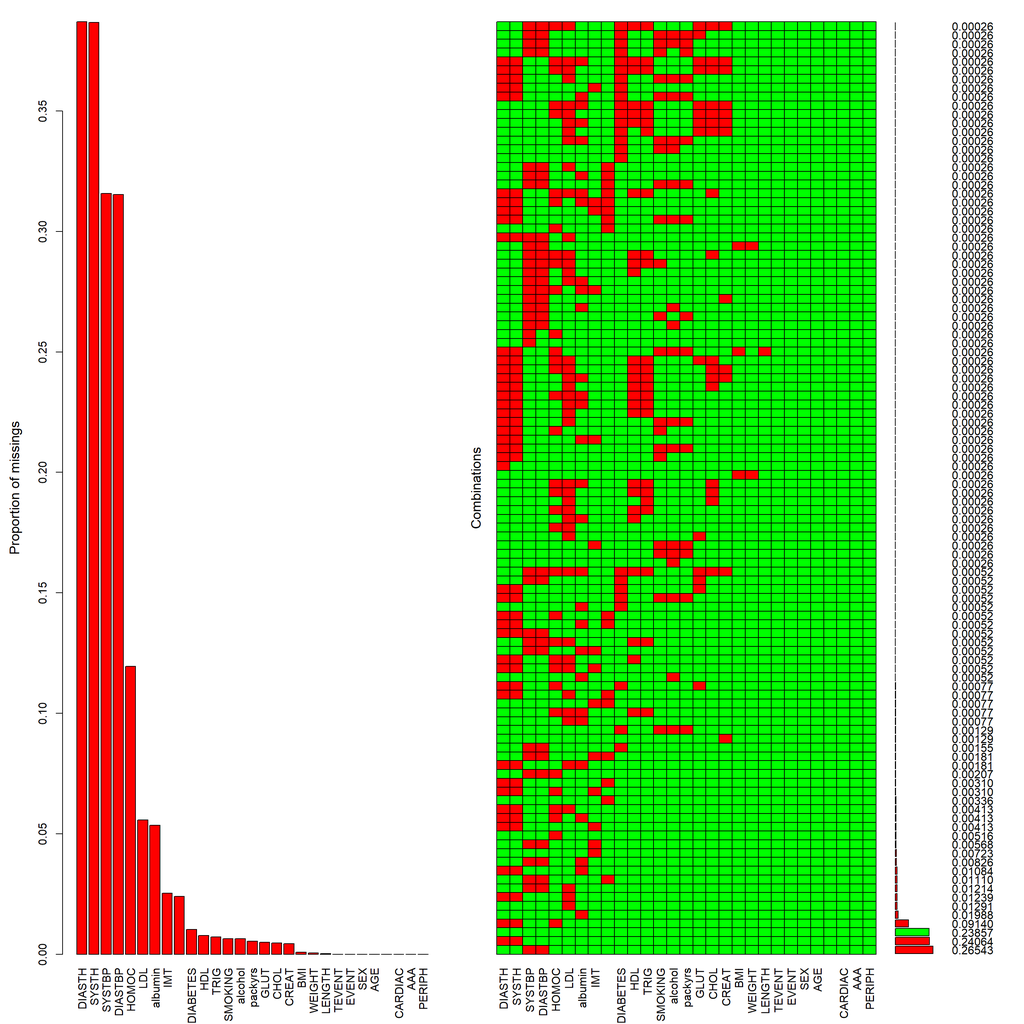

```
##
##  Variables sorted by number of missings:
##  Variable        Count
##    DIASTH 0.3870384715
##     SYSTH 0.3867802737
##    SYSTBP 0.3157758843
##   DIASTBP 0.3152594888
##     HOMOC 0.1195455719
##       LDL 0.0557707204
##   albumin 0.0534469404
##       IMT 0.0253033824
##  STENOSIS 0.0240123935
##  DIABETES 0.0103279112
##       HDL 0.0077459334
##      TRIG 0.0072295378
##   SMOKING 0.0064549445
##   alcohol 0.0064549445
##   packyrs 0.0054221534
##      GLUT 0.0049057578
##      CHOL 0.0046475600
##     CREAT 0.0043893623
##       BMI 0.0007745933
##    WEIGHT 0.0005163956
##    LENGTH 0.0002581978
##    TEVENT 0.0000000000
##     EVENT 0.0000000000
##       SEX 0.0000000000
##       AGE 0.0000000000
##  CEREBRAL 0.0000000000
##   CARDIAC 0.0000000000
##       AAA 0.0000000000
##    PERIPH 0.0000000000
```

```r
plot(DPP.Profile,
     numbers = TRUE,
     prop = TRUE,
     sortVars = TRUE,
     col=c("green","red"))
```

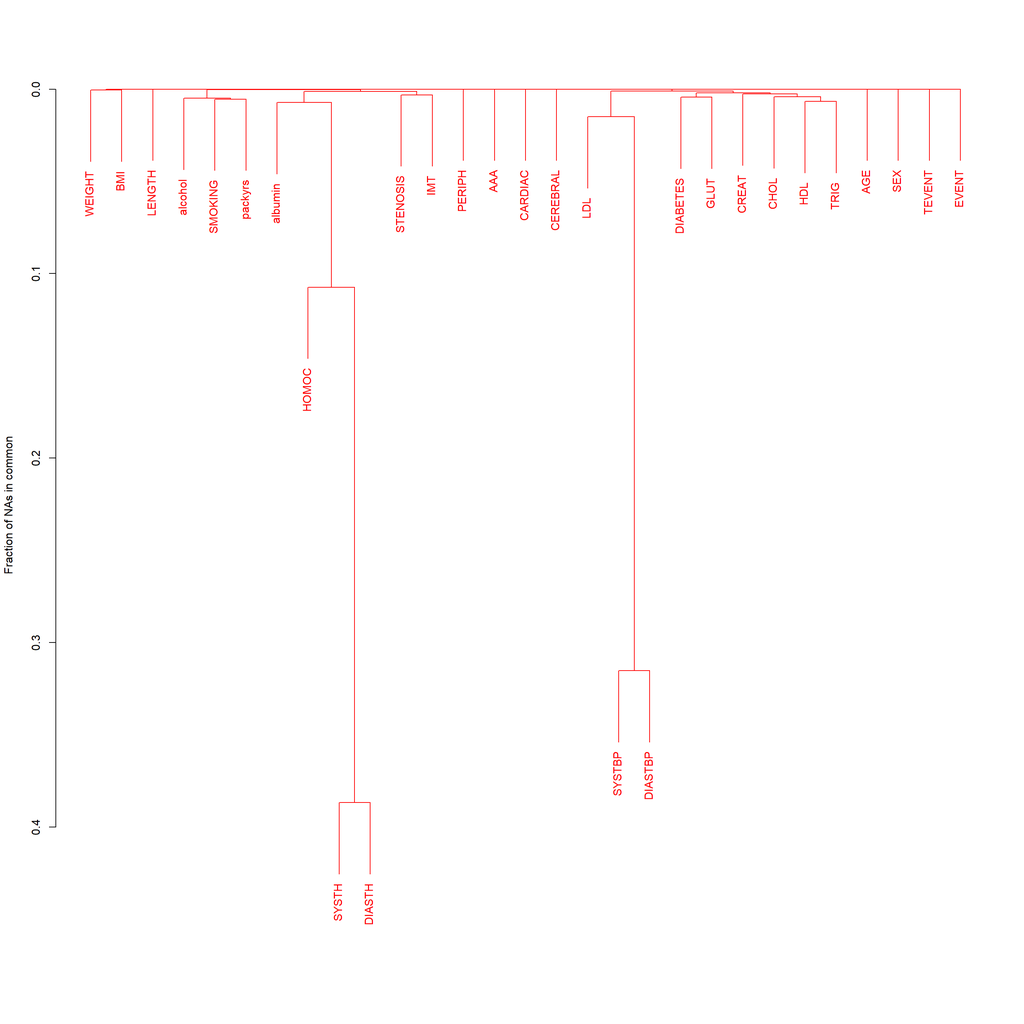

```r
par(mfrow=c(1,1))
DPP.Patterns <- naclus(DPP)
plot(DPP.Patterns,
     ylab="Fraction of NAs in common",
     col="red")
```

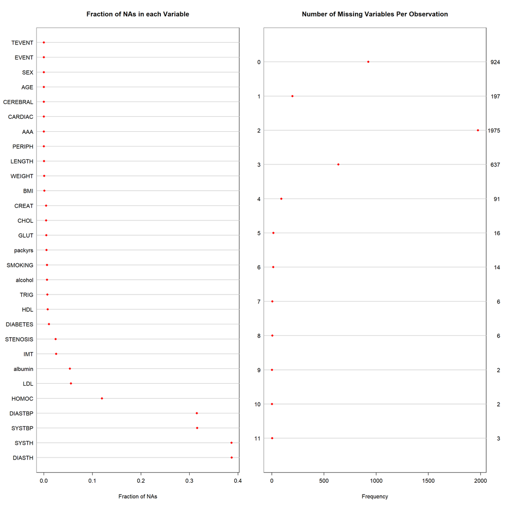

```r
par(mfrow=c(1,2))
naplot(DPP.Patterns, which=c('na per var'),col="red")
naplot(DPP.Patterns, which=c('na per obs'),col="red")
```

```r
##################################
# Conducting missing data imputation
# using AREGIMPUTE
# (Multiple Imputation using Additive Regression, Bootstrapping, and Predictive Mean Matching)
##################################
DPP$CEREBRAL  <- as.numeric(as.character(DPP$CEREBRAL))
DPP$CARDIAC   <- as.numeric(as.character(DPP$CARDIAC))
DPP$AAA       <- as.numeric(as.character(DPP$AAA))
DPP$PERIPH    <- as.numeric(as.character(DPP$PERIPH))
DPP$SUMSCORE_5LEVELS  <- DPP$CEREBRAL +
  DPP$CARDIAC +
  (2*DPP$AAA) +
  DPP$PERIPH

set.seed(123456789)
DPP.AREGIMPUTED  <-aregImpute(~I(TEVENT)+EVENT+SEX+I(AGE)+
                       SYSTBP+DIASTBP+SYSTH+DIASTH+
                       DIABETES+CEREBRAL+CARDIAC+AAA+PERIPH+I(SUMSCORE_5LEVELS)+STENOSIS+
                       I(LENGTH)+I(WEIGHT)+I(BMI)+
                       I(CHOL)+I(HDL)+I(LDL)+I(TRIG)+I(HOMOC)+I(GLUT)+I(CREAT)+I(IMT)+
                       as.factor(albumin) +as.factor(SMOKING) + I(packyrs) + as.factor(alcohol),
                     n.impute=5,data=DPP)
```

```
## Iteration 1 Iteration 2 Iteration 3 Iteration 4 Iteration 5 Iteration 6 Iteration 7 Iteration 8
```

```r
##################################
# Evaluating the plausibility of the
# AREG-imputed values for the
# numerical variables
##################################

SYSTBP_complete <- (DPP$SYSTBP[complete.cases(DPP$SYSTBP)])

DPP.AREGIMPUTED_aregImpute_SYSTBP <- as.data.frame(DPP.AREGIMPUTED$imputed$SYSTBP)

SYSTBP_aregImpute_1 <- DPP.AREGIMPUTED_aregImpute_SYSTBP$V1
SYSTBP_aregImpute_2 <- DPP.AREGIMPUTED_aregImpute_SYSTBP$V2
SYSTBP_aregImpute_3 <- DPP.AREGIMPUTED_aregImpute_SYSTBP$V3
SYSTBP_aregImpute_4 <- DPP.AREGIMPUTED_aregImpute_SYSTBP$V4
SYSTBP_aregImpute_5 <- DPP.AREGIMPUTED_aregImpute_SYSTBP$V5

SYSTBP_values <- c(SYSTBP_complete,
                       SYSTBP_aregImpute_1,
                       SYSTBP_aregImpute_2,
                       SYSTBP_aregImpute_3,
                       SYSTBP_aregImpute_4,
                       SYSTBP_aregImpute_5)

SYSTBP_labels <- c(rep("Original",length(SYSTBP_complete)),
            rep("aregImputed_1",length(SYSTBP_aregImpute_1)),
            rep("aregImputed_2",length(SYSTBP_aregImpute_2)),
            rep("aregImputed_3",length(SYSTBP_aregImpute_3)),
            rep("aregImputed_4",length(SYSTBP_aregImpute_4)),
            rep("aregImputed_5",length(SYSTBP_aregImpute_5)))

DIASTBP_complete <- (DPP$DIASTBP[complete.cases(DPP$DIASTBP)])

DPP.AREGIMPUTED_aregImpute_DIASTBP <- as.data.frame(DPP.AREGIMPUTED$imputed$DIASTBP)

DIASTBP_aregImpute_1 <- DPP.AREGIMPUTED_aregImpute_DIASTBP$V1
DIASTBP_aregImpute_2 <- DPP.AREGIMPUTED_aregImpute_DIASTBP$V2
DIASTBP_aregImpute_3 <- DPP.AREGIMPUTED_aregImpute_DIASTBP$V3
DIASTBP_aregImpute_4 <- DPP.AREGIMPUTED_aregImpute_DIASTBP$V4
DIASTBP_aregImpute_5 <- DPP.AREGIMPUTED_aregImpute_DIASTBP$V5

DIASTBP_values <- c(DIASTBP_complete,
                    DIASTBP_aregImpute_1,
                    DIASTBP_aregImpute_2,
                    DIASTBP_aregImpute_3,
                    DIASTBP_aregImpute_4,
                    DIASTBP_aregImpute_5)

DIASTBP_labels <- c(rep("Original",length(DIASTBP_complete)),
                    rep("aregImputed_1",length(DIASTBP_aregImpute_1)),
                    rep("aregImputed_2",length(DIASTBP_aregImpute_2)),
                    rep("aregImputed_3",length(DIASTBP_aregImpute_3)),
                    rep("aregImputed_4",length(DIASTBP_aregImpute_4)),
                    rep("aregImputed_5",length(DIASTBP_aregImpute_5)))

SYSTH_complete <- (DPP$SYSTH[complete.cases(DPP$SYSTH)])

DPP.AREGIMPUTED_aregImpute_SYSTH <- as.data.frame(DPP.AREGIMPUTED$imputed$SYSTH)

SYSTH_aregImpute_1 <- DPP.AREGIMPUTED_aregImpute_SYSTH$V1
SYSTH_aregImpute_2 <- DPP.AREGIMPUTED_aregImpute_SYSTH$V2
SYSTH_aregImpute_3 <- DPP.AREGIMPUTED_aregImpute_SYSTH$V3
SYSTH_aregImpute_4 <- DPP.AREGIMPUTED_aregImpute_SYSTH$V4
SYSTH_aregImpute_5 <- DPP.AREGIMPUTED_aregImpute_SYSTH$V5

SYSTH_values <- c(SYSTH_complete,
                  SYSTH_aregImpute_1,
                  SYSTH_aregImpute_2,
                  SYSTH_aregImpute_3,
                  SYSTH_aregImpute_4,
                  SYSTH_aregImpute_5)

SYSTH_labels <- c(rep("Original",length(SYSTH_complete)),
                  rep("aregImputed_1",length(SYSTH_aregImpute_1)),
                  rep("aregImputed_2",length(SYSTH_aregImpute_2)),
                  rep("aregImputed_3",length(SYSTH_aregImpute_3)),
                  rep("aregImputed_4",length(SYSTH_aregImpute_4)),
                  rep("aregImputed_5",length(SYSTH_aregImpute_5)))

DIASTH_complete <- (DPP$DIASTH[complete.cases(DPP$DIASTH)])

DPP.AREGIMPUTED_aregImpute_DIASTH <- as.data.frame(DPP.AREGIMPUTED$imputed$DIASTH)

DIASTH_aregImpute_1 <- DPP.AREGIMPUTED_aregImpute_DIASTH$V1
DIASTH_aregImpute_2 <- DPP.AREGIMPUTED_aregImpute_DIASTH$V2
DIASTH_aregImpute_3 <- DPP.AREGIMPUTED_aregImpute_DIASTH$V3
DIASTH_aregImpute_4 <- DPP.AREGIMPUTED_aregImpute_DIASTH$V4
DIASTH_aregImpute_5 <- DPP.AREGIMPUTED_aregImpute_DIASTH$V5

DIASTH_values <- c(DIASTH_complete,
                   DIASTH_aregImpute_1,
                   DIASTH_aregImpute_2,
                   DIASTH_aregImpute_3,
                   DIASTH_aregImpute_4,
                   DIASTH_aregImpute_5)

DIASTH_labels <- c(rep("Original",length(DIASTH_complete)),
                   rep("aregImputed_1",length(DIASTH_aregImpute_1)),
                   rep("aregImputed_2",length(DIASTH_aregImpute_2)),
                   rep("aregImputed_3",length(DIASTH_aregImpute_3)),
                   rep("aregImputed_4",length(DIASTH_aregImpute_4)),
                   rep("aregImputed_5",length(DIASTH_aregImpute_5)))

LENGTH_complete <- (DPP$LENGTH[complete.cases(DPP$LENGTH)])

DPP.AREGIMPUTED_aregImpute_LENGTH <- as.data.frame(DPP.AREGIMPUTED$imputed$LENGTH)

LENGTH_aregImpute_1 <- DPP.AREGIMPUTED_aregImpute_LENGTH$V1
LENGTH_aregImpute_2 <- DPP.AREGIMPUTED_aregImpute_LENGTH$V2
LENGTH_aregImpute_3 <- DPP.AREGIMPUTED_aregImpute_LENGTH$V3
LENGTH_aregImpute_4 <- DPP.AREGIMPUTED_aregImpute_LENGTH$V4
LENGTH_aregImpute_5 <- DPP.AREGIMPUTED_aregImpute_LENGTH$V5

LENGTH_values <- c(LENGTH_complete,
                   LENGTH_aregImpute_1,
                   LENGTH_aregImpute_2,
                   LENGTH_aregImpute_3,
                   LENGTH_aregImpute_4,
                   LENGTH_aregImpute_5)

LENGTH_labels <- c(rep("Original",length(LENGTH_complete)),
                   rep("aregImputed_1",length(LENGTH_aregImpute_1)),
                   rep("aregImputed_2",length(LENGTH_aregImpute_2)),
                   rep("aregImputed_3",length(LENGTH_aregImpute_3)),
                   rep("aregImputed_4",length(LENGTH_aregImpute_4)),
                   rep("aregImputed_5",length(LENGTH_aregImpute_5)))

WEIGHT_complete <- (DPP$WEIGHT[complete.cases(DPP$WEIGHT)])

DPP.AREGIMPUTED_aregImpute_WEIGHT <- as.data.frame(DPP.AREGIMPUTED$imputed$WEIGHT)

WEIGHT_aregImpute_1 <- DPP.AREGIMPUTED_aregImpute_WEIGHT$V1
WEIGHT_aregImpute_2 <- DPP.AREGIMPUTED_aregImpute_WEIGHT$V2
WEIGHT_aregImpute_3 <- DPP.AREGIMPUTED_aregImpute_WEIGHT$V3
WEIGHT_aregImpute_4 <- DPP.AREGIMPUTED_aregImpute_WEIGHT$V4
WEIGHT_aregImpute_5 <- DPP.AREGIMPUTED_aregImpute_WEIGHT$V5
```

```r
WEIGHT_values <- c(WEIGHT_complete,
                   WEIGHT_aregImpute_1,
                   WEIGHT_aregImpute_2,
                   WEIGHT_aregImpute_3,
                   WEIGHT_aregImpute_4,
                   WEIGHT_aregImpute_5)

WEIGHT_labels <- c(rep("Original",length(WEIGHT_complete)),
                   rep("aregImputed_1",length(WEIGHT_aregImpute_1)),
                   rep("aregImputed_2",length(WEIGHT_aregImpute_2)),
                   rep("aregImputed_3",length(WEIGHT_aregImpute_3)),
                   rep("aregImputed_4",length(WEIGHT_aregImpute_4)),
                   rep("aregImputed_5",length(WEIGHT_aregImpute_5)))


BMI_complete <- (DPP$BMI[complete.cases(DPP$BMI)])

DPP.AREGIMPUTED_aregImpute_BMI <- as.data.frame(DPP.AREGIMPUTED$imputed$BMI)

BMI_aregImpute_1 <- DPP.AREGIMPUTED_aregImpute_BMI$V1
BMI_aregImpute_2 <- DPP.AREGIMPUTED_aregImpute_BMI$V2
BMI_aregImpute_3 <- DPP.AREGIMPUTED_aregImpute_BMI$V3
BMI_aregImpute_4 <- DPP.AREGIMPUTED_aregImpute_BMI$V4
BMI_aregImpute_5 <- DPP.AREGIMPUTED_aregImpute_BMI$V5

BMI_values <- c(BMI_complete,
                   BMI_aregImpute_1,
                   BMI_aregImpute_2,
                   BMI_aregImpute_3,
                   BMI_aregImpute_4,
                   BMI_aregImpute_5)

BMI_labels <- c(rep("Original",length(BMI_complete)),
                   rep("aregImputed_1",length(BMI_aregImpute_1)),
                   rep("aregImputed_2",length(BMI_aregImpute_2)),
                   rep("aregImputed_3",length(BMI_aregImpute_3)),
                   rep("aregImputed_4",length(BMI_aregImpute_4)),
                   rep("aregImputed_5",length(BMI_aregImpute_5)))


CHOL_complete <- (DPP$CHOL[complete.cases(DPP$CHOL)])

DPP.AREGIMPUTED_aregImpute_CHOL <- as.data.frame(DPP.AREGIMPUTED$imputed$CHOL)

CHOL_aregImpute_1 <- DPP.AREGIMPUTED_aregImpute_CHOL$V1
CHOL_aregImpute_2 <- DPP.AREGIMPUTED_aregImpute_CHOL$V2
CHOL_aregImpute_3 <- DPP.AREGIMPUTED_aregImpute_CHOL$V3
CHOL_aregImpute_4 <- DPP.AREGIMPUTED_aregImpute_CHOL$V4
CHOL_aregImpute_5 <- DPP.AREGIMPUTED_aregImpute_CHOL$V5

CHOL_values <- c(CHOL_complete,
                   CHOL_aregImpute_1,
                   CHOL_aregImpute_2,
                   CHOL_aregImpute_3,
                   CHOL_aregImpute_4,
                   CHOL_aregImpute_5)

CHOL_labels <- c(rep("Original",length(CHOL_complete)),
                   rep("aregImputed_1",length(CHOL_aregImpute_1)),
                   rep("aregImputed_2",length(CHOL_aregImpute_2)),
                   rep("aregImputed_3",length(CHOL_aregImpute_3)),
                   rep("aregImputed_4",length(CHOL_aregImpute_4)),
                   rep("aregImputed_5",length(CHOL_aregImpute_5)))

HDL_complete <- (DPP$HDL[complete.cases(DPP$HDL)])

DPP.AREGIMPUTED_aregImpute_HDL <- as.data.frame(DPP.AREGIMPUTED$imputed$HDL)

HDL_aregImpute_1 <- DPP.AREGIMPUTED_aregImpute_HDL$V1
HDL_aregImpute_2 <- DPP.AREGIMPUTED_aregImpute_HDL$V2
HDL_aregImpute_3 <- DPP.AREGIMPUTED_aregImpute_HDL$V3
HDL_aregImpute_4 <- DPP.AREGIMPUTED_aregImpute_HDL$V4
HDL_aregImpute_5 <- DPP.AREGIMPUTED_aregImpute_HDL$V5

HDL_values <- c(HDL_complete,
                   HDL_aregImpute_1,
                   HDL_aregImpute_2,
                   HDL_aregImpute_3,
                   HDL_aregImpute_4,
                   HDL_aregImpute_5)

HDL_labels <- c(rep("Original",length(HDL_complete)),
                   rep("aregImputed_1",length(HDL_aregImpute_1)),
                   rep("aregImputed_2",length(HDL_aregImpute_2)),
                   rep("aregImputed_3",length(HDL_aregImpute_3)),
                   rep("aregImputed_4",length(HDL_aregImpute_4)),
                   rep("aregImputed_5",length(HDL_aregImpute_5)))


LDL_complete <- (DPP$LDL[complete.cases(DPP$LDL)])

DPP.AREGIMPUTED_aregImpute_LDL <- as.data.frame(DPP.AREGIMPUTED$imputed$LDL)

LDL_aregImpute_1 <- DPP.AREGIMPUTED_aregImpute_LDL$V1
LDL_aregImpute_2 <- DPP.AREGIMPUTED_aregImpute_LDL$V2
LDL_aregImpute_3 <- DPP.AREGIMPUTED_aregImpute_LDL$V3
LDL_aregImpute_4 <- DPP.AREGIMPUTED_aregImpute_LDL$V4
LDL_aregImpute_5 <- DPP.AREGIMPUTED_aregImpute_LDL$V5

LDL_values <- c(LDL_complete,
                   LDL_aregImpute_1,
                   LDL_aregImpute_2,
                   LDL_aregImpute_3,
                   LDL_aregImpute_4,
                   LDL_aregImpute_5)

LDL_labels <- c(rep("Original",length(LDL_complete)),
                   rep("aregImputed_1",length(LDL_aregImpute_1)),
                   rep("aregImputed_2",length(LDL_aregImpute_2)),
                   rep("aregImputed_3",length(LDL_aregImpute_3)),
                   rep("aregImputed_4",length(LDL_aregImpute_4)),
                   rep("aregImputed_5",length(LDL_aregImpute_5)))

TRIG_complete <- (DPP$TRIG[complete.cases(DPP$TRIG)])

DPP.AREGIMPUTED_aregImpute_TRIG <- as.data.frame(DPP.AREGIMPUTED$imputed$TRIG)

TRIG_aregImpute_1 <- DPP.AREGIMPUTED_aregImpute_TRIG$V1
TRIG_aregImpute_2 <- DPP.AREGIMPUTED_aregImpute_TRIG$V2
TRIG_aregImpute_3 <- DPP.AREGIMPUTED_aregImpute_TRIG$V3
TRIG_aregImpute_4 <- DPP.AREGIMPUTED_aregImpute_TRIG$V4
TRIG_aregImpute_5 <- DPP.AREGIMPUTED_aregImpute_TRIG$V5

TRIG_values <- c(TRIG_complete,
                   TRIG_aregImpute_1,
                   TRIG_aregImpute_2,
                   TRIG_aregImpute_3,
                   TRIG_aregImpute_4,
                   TRIG_aregImpute_5)

TRIG_labels <- c(rep("Original",length(TRIG_complete)),
                   rep("aregImputed_1",length(TRIG_aregImpute_1)),
                   rep("aregImputed_2",length(TRIG_aregImpute_2)),
                   rep("aregImputed_3",length(TRIG_aregImpute_3)),
                   rep("aregImputed_4",length(TRIG_aregImpute_4)),
                   rep("aregImputed_5",length(TRIG_aregImpute_5)))

HOMOC_complete <- (DPP$HOMOC[complete.cases(DPP$HOMOC)])

DPP.AREGIMPUTED_aregImpute_HOMOC <- as.data.frame(DPP.AREGIMPUTED$imputed$HOMOC)

HOMOC_aregImpute_1 <- DPP.AREGIMPUTED_aregImpute_HOMOC$V1
HOMOC_aregImpute_2 <- DPP.AREGIMPUTED_aregImpute_HOMOC$V2
HOMOC_aregImpute_3 <- DPP.AREGIMPUTED_aregImpute_HOMOC$V3
HOMOC_aregImpute_4 <- DPP.AREGIMPUTED_aregImpute_HOMOC$V4
HOMOC_aregImpute_5 <- DPP.AREGIMPUTED_aregImpute_HOMOC$V5
```

```r
HOMOC_values <- c(HOMOC_complete,
                   HOMOC_aregImpute_1,
                   HOMOC_aregImpute_2,
                   HOMOC_aregImpute_3,
                   HOMOC_aregImpute_4,
                   HOMOC_aregImpute_5)

HOMOC_labels <- c(rep("Original",length(HOMOC_complete)),
                   rep("aregImputed_1",length(HOMOC_aregImpute_1)),
                   rep("aregImputed_2",length(HOMOC_aregImpute_2)),
                   rep("aregImputed_3",length(HOMOC_aregImpute_3)),
                   rep("aregImputed_4",length(HOMOC_aregImpute_4)),
                   rep("aregImputed_5",length(HOMOC_aregImpute_5)))


GLUT_complete <- (DPP$GLUT[complete.cases(DPP$GLUT)])

DPP.AREGIMPUTED_aregImpute_GLUT <- as.data.frame(DPP.AREGIMPUTED$imputed$GLUT)

GLUT_aregImpute_1 <- DPP.AREGIMPUTED_aregImpute_GLUT$V1
GLUT_aregImpute_2 <- DPP.AREGIMPUTED_aregImpute_GLUT$V2
GLUT_aregImpute_3 <- DPP.AREGIMPUTED_aregImpute_GLUT$V3
GLUT_aregImpute_4 <- DPP.AREGIMPUTED_aregImpute_GLUT$V4
GLUT_aregImpute_5 <- DPP.AREGIMPUTED_aregImpute_GLUT$V5

GLUT_values <- c(GLUT_complete,
                   GLUT_aregImpute_1,
                   GLUT_aregImpute_2,
                   GLUT_aregImpute_3,
                   GLUT_aregImpute_4,
                   GLUT_aregImpute_5)

GLUT_labels <- c(rep("Original",length(GLUT_complete)),
                   rep("aregImputed_1",length(GLUT_aregImpute_1)),
                   rep("aregImputed_2",length(GLUT_aregImpute_2)),
                   rep("aregImputed_3",length(GLUT_aregImpute_3)),
                   rep("aregImputed_4",length(GLUT_aregImpute_4)),
                   rep("aregImputed_5",length(GLUT_aregImpute_5)))


CREAT_complete <- (DPP$CREAT[complete.cases(DPP$CREAT)])

DPP.AREGIMPUTED_aregImpute_CREAT <- as.data.frame(DPP.AREGIMPUTED$imputed$CREAT)

CREAT_aregImpute_1 <- DPP.AREGIMPUTED_aregImpute_CREAT$V1
CREAT_aregImpute_2 <- DPP.AREGIMPUTED_aregImpute_CREAT$V2
CREAT_aregImpute_3 <- DPP.AREGIMPUTED_aregImpute_CREAT$V3
CREAT_aregImpute_4 <- DPP.AREGIMPUTED_aregImpute_CREAT$V4
CREAT_aregImpute_5 <- DPP.AREGIMPUTED_aregImpute_CREAT$V5

CREAT_values <- c(CREAT_complete,
                   CREAT_aregImpute_1,
                   CREAT_aregImpute_2,
                   CREAT_aregImpute_3,
                   CREAT_aregImpute_4,
                   CREAT_aregImpute_5)

CREAT_labels <- c(rep("Original",length(CREAT_complete)),
                   rep("aregImputed_1",length(CREAT_aregImpute_1)),
                   rep("aregImputed_2",length(CREAT_aregImpute_2)),
                   rep("aregImputed_3",length(CREAT_aregImpute_3)),
                   rep("aregImputed_4",length(CREAT_aregImpute_4)),
                   rep("aregImputed_5",length(CREAT_aregImpute_5)))


IMT_complete <- (DPP$IMT[complete.cases(DPP$IMT)])

DPP.AREGIMPUTED_aregImpute_IMT <- as.data.frame(DPP.AREGIMPUTED$imputed$IMT)

IMT_aregImpute_1 <- DPP.AREGIMPUTED_aregImpute_IMT$V1
IMT_aregImpute_2 <- DPP.AREGIMPUTED_aregImpute_IMT$V2
IMT_aregImpute_3 <- DPP.AREGIMPUTED_aregImpute_IMT$V3
IMT_aregImpute_4 <- DPP.AREGIMPUTED_aregImpute_IMT$V4
IMT_aregImpute_5 <- DPP.AREGIMPUTED_aregImpute_IMT$V5

IMT_values <- c(IMT_complete,
                   IMT_aregImpute_1,
                   IMT_aregImpute_2,
                   IMT_aregImpute_3,
                   IMT_aregImpute_4,
                   IMT_aregImpute_5)

IMT_labels <- c(rep("Original",length(IMT_complete)),
                   rep("aregImputed_1",length(IMT_aregImpute_1)),
                   rep("aregImputed_2",length(IMT_aregImpute_2)),
                   rep("aregImputed_3",length(IMT_aregImpute_3)),
                   rep("aregImputed_4",length(IMT_aregImpute_4)),
                   rep("aregImputed_5",length(IMT_aregImpute_5)))


PACKYRS_complete <- (DPP$packyrs[complete.cases(DPP$packyrs)])

DPP.AREGIMPUTED_aregImpute_PACKYRS <- as.data.frame(DPP.AREGIMPUTED$imputed$packyrs)

PACKYRS_aregImpute_1 <- DPP.AREGIMPUTED_aregImpute_PACKYRS$V1
PACKYRS_aregImpute_2 <- DPP.AREGIMPUTED_aregImpute_PACKYRS$V2
PACKYRS_aregImpute_3 <- DPP.AREGIMPUTED_aregImpute_PACKYRS$V3
PACKYRS_aregImpute_4 <- DPP.AREGIMPUTED_aregImpute_PACKYRS$V4
PACKYRS_aregImpute_5 <- DPP.AREGIMPUTED_aregImpute_PACKYRS$V5

PACKYRS_values <- c(PACKYRS_complete,
                   PACKYRS_aregImpute_1,
                   PACKYRS_aregImpute_2,
                   PACKYRS_aregImpute_3,
                   PACKYRS_aregImpute_4,
                   PACKYRS_aregImpute_5)

PACKYRS_labels <- c(rep("Original",length(PACKYRS_complete)),
                   rep("aregImputed_1",length(PACKYRS_aregImpute_1)),
                   rep("aregImputed_2",length(PACKYRS_aregImpute_2)),
                   rep("aregImputed_3",length(PACKYRS_aregImpute_3)),
                   rep("aregImputed_4",length(PACKYRS_aregImpute_4)),
                   rep("aregImputed_5",length(PACKYRS_aregImpute_5)))


VARIABLE_labels <- c(rep("SYSTBP",length(SYSTBP_labels)),
                     rep("DIASTBP",length(DIASTBP_labels)),
                     rep("SYSTH",length(SYSTH_labels)),
                     rep("DIASTH",length(DIASTH_labels)),
                     rep("LENGTH",length(LENGTH_labels)),
                     rep("WEIGHT",length(WEIGHT_labels)),
                     rep("BMI",length(BMI_labels)),
                     rep("CHOL",length(CHOL_labels)),
                     rep("HDL",length(HDL_labels)),
                     rep("LDL",length(LDL_labels)),
                     rep("TRIG",length(TRIG_labels)),
                     rep("HOMOC",length(HOMOC_labels)),
                     rep("GLUT",length(GLUT_labels)),
                     rep("CREAT",length(CREAT_labels)),
                     rep("IMT",length(IMT_labels)),
                     rep("PACKYRS",length(PACKYRS_labels)))

NUMERIC_VARIABLES_postimputation <- cbind(VARIABLE_labels,
                                        c(SYSTBP_labels,
                                          DIASTBP_labels,
                                          SYSTH_labels,
                                          DIASTH_labels,
                                          LENGTH_labels,
                                          WEIGHT_labels,
                                          BMI_labels,
                                          CHOL_labels,
                                          HDL_labels,
                                          LDL_labels,
                                          TRIG_labels,
                                          HOMOC_labels,
                                          GLUT_labels,
                                          CREAT_labels,
                                          IMT_labels,
                                          PACKYRS_labels),
                                        c(SYSTBP_values,
                                          DIASTBP_values,
                                          SYSTH_values,
                                          DIASTH_values,
                                          LENGTH_values,
                                          WEIGHT_values,
                                          BMI_values,
                                          CHOL_values,
                                          HDL_values,
                                          LDL_values,
                                          TRIG_values,
                                          HOMOC_values,
                                          GLUT_values,
                                          CREAT_values,
                                          IMT_values,
                                          PACKYRS_values))
NUMERIC_VARIABLES_postimputation <- as.data.frame(NUMERIC_VARIABLES_postimputation)
```

```r
colnames(NUMERIC_VARIABLES_postimputation) <- c("Variable",
                                                "Category",
                                                "Value")

NUMERIC_VARIABLES_postimputation$Variable <- factor(NUMERIC_VARIABLES_postimputation$Variable,
                                         levels=c("PACKYRS",
                                                  "IMT",
                                                  "CREAT",
                                                  "GLUT",
                                                  "HOMOC",
                                                  "TRIG",
                                                  "LDL",
                                                  "HDL",
                                                  "CHOL",
                                                  "BMI",
                                                  "WEIGHT",
                                                  "LENGTH",
                                                  "DIASTH",
                                                  "SYSTH",
                                                  "DIASTBP",
                                                  "SYSTBP"))

NUMERIC_VARIABLES_postimputation$Category <- factor(NUMERIC_VARIABLES_postimputation$Category,
                                         levels=c("Original",
                                                  "aregImputed_1",
                                                  "aregImputed_2",
                                                  "aregImputed_3",
                                                  "aregImputed_4",
                                                  "aregImputed_5"))

NUMERIC_VARIABLES_postimputation_SYSTBP <- NUMERIC_VARIABLES_postimputation[NUMERIC_VARIABLES_postimputation$Variable=="SYSTBP",]
NUMERIC_VARIABLES_postimputation_SYSTH <- NUMERIC_VARIABLES_postimputation[NUMERIC_VARIABLES_postimputation$Variable=="SYSTH",]
NUMERIC_VARIABLES_postimputation_DIASTBP <- NUMERIC_VARIABLES_postimputation[NUMERIC_VARIABLES_postimputation$Variable=="DIASTBP",]
NUMERIC_VARIABLES_postimputation_DIASTH <- NUMERIC_VARIABLES_postimputation[NUMERIC_VARIABLES_postimputation$Variable=="DIASTH",]
NUMERIC_VARIABLES_postimputation_LENGTH <- NUMERIC_VARIABLES_postimputation[NUMERIC_VARIABLES_postimputation$Variable=="LENGTH",]
NUMERIC_VARIABLES_postimputation_WEIGHT <- NUMERIC_VARIABLES_postimputation[NUMERIC_VARIABLES_postimputation$Variable=="WEIGHT",]
NUMERIC_VARIABLES_postimputation_BMI <- NUMERIC_VARIABLES_postimputation[NUMERIC_VARIABLES_postimputation$Variable=="BMI",]
NUMERIC_VARIABLES_postimputation_CHOL <- NUMERIC_VARIABLES_postimputation[NUMERIC_VARIABLES_postimputation$Variable=="CHOL",]
NUMERIC_VARIABLES_postimputation_HDL <- NUMERIC_VARIABLES_postimputation[NUMERIC_VARIABLES_postimputation$Variable=="HDL",]
NUMERIC_VARIABLES_postimputation_LDL <- NUMERIC_VARIABLES_postimputation[NUMERIC_VARIABLES_postimputation$Variable=="LDL",]
NUMERIC_VARIABLES_postimputation_TRIG <- NUMERIC_VARIABLES_postimputation[NUMERIC_VARIABLES_postimputation$Variable=="TRIG",]
NUMERIC_VARIABLES_postimputation_HOMOC <- NUMERIC_VARIABLES_postimputation[NUMERIC_VARIABLES_postimputation$Variable=="HOMOC",]
NUMERIC_VARIABLES_postimputation_GLUT <- NUMERIC_VARIABLES_postimputation[NUMERIC_VARIABLES_postimputation$Variable=="GLUT",]
NUMERIC_VARIABLES_postimputation_CREAT <- NUMERIC_VARIABLES_postimputation[NUMERIC_VARIABLES_postimputation$Variable=="CREAT",]
NUMERIC_VARIABLES_postimputation_IMT <- NUMERIC_VARIABLES_postimputation[NUMERIC_VARIABLES_postimputation$Variable=="IMT",]
NUMERIC_VARIABLES_postimputation_PACKYRS <- NUMERIC_VARIABLES_postimputation[NUMERIC_VARIABLES_postimputation$Variable=="PACKYRS",]

DENSITY_SYSTBP <- densityplot(~ Value | Variable,
            data = NUMERIC_VARIABLES_postimputation_SYSTBP,
            groups = Category,
            plot.points = FALSE,
            ref = TRUE,
            scales=list(relation="free"),
            auto.key = list(adj=1, space="top", columns=1),
            par.settings = list(superpose.line = list(lwd=2)))

DENSITY_SYSTH <- densityplot(~ Value | Variable,
                              data = NUMERIC_VARIABLES_postimputation_SYSTH,
                              groups = Category,
                              plot.points = FALSE,
                              ref = TRUE,
                              scales=list(relation="free"),
                              auto.key = list(adj=1, space="top", columns=1),
                              par.settings = list(superpose.line = list(lwd=2)))

DENSITY_DIASTBP <- densityplot(~ Value | Variable,
                               data = NUMERIC_VARIABLES_postimputation_DIASTBP,
                               groups = Category,
                               plot.points = FALSE,
                               ref = TRUE,
                               scales=list(relation="free"),
                               auto.key = list(adj=1, space="top", columns=1),
                               par.settings = list(superpose.line = list(lwd=2)))

DENSITY_DIASTH <- densityplot(~ Value | Variable,
                              data = NUMERIC_VARIABLES_postimputation_DIASTH,
                              groups = Category,
                              plot.points = FALSE,
                              ref = TRUE,
                              scales=list(relation="free"),
                              auto.key = list(adj=1, space="top", columns=1),
                              par.settings = list(superpose.line = list(lwd=2)))

DENSITY_LENGTH <- densityplot(~ Value | Variable,
                              data = NUMERIC_VARIABLES_postimputation_LENGTH,
                              groups = Category,
                              plot.points = FALSE,
                              ref = TRUE,
                              scales=list(relation="free"),
                              auto.key = list(adj=1, space="top", columns=1),
                              par.settings = list(superpose.line = list(lwd=2)))
```

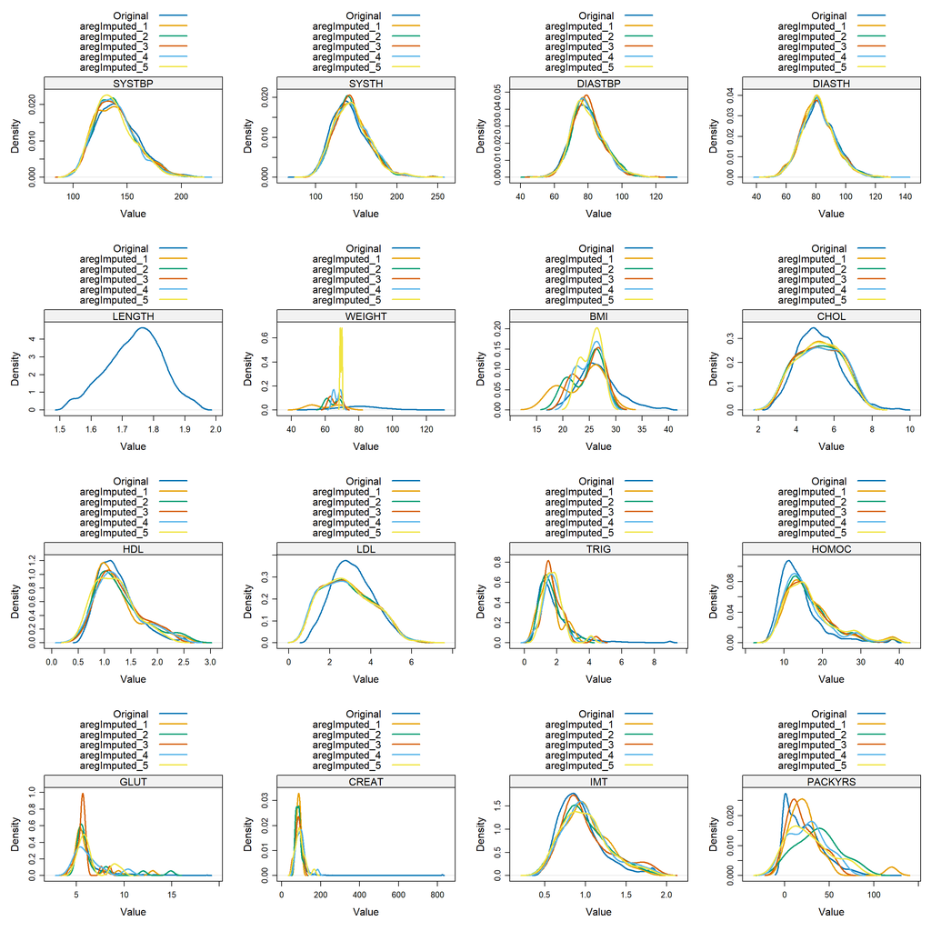

```r
DENSITY_WEIGHT <- densityplot(~ Value | Variable,
                              data = NUMERIC_VARIABLES_postimputation_WEIGHT,
                              groups = Category,
                              plot.points = FALSE,
                              ref = TRUE,
                              scales=list(relation="free"),
                              auto.key = list(adj=1, space="top", columns=1),
                              par.settings = list(superpose.line = list(lwd=2)))

DENSITY_BMI <- densityplot(~ Value | Variable,
                              data = NUMERIC_VARIABLES_postimputation_BMI,
                              groups = Category,
                              plot.points = FALSE,
                              ref = TRUE,
                              scales=list(relation="free"),
                              auto.key = list(adj=1, space="top", columns=1),
                              par.settings = list(superpose.line = list(lwd=2)))

DENSITY_CHOL <- densityplot(~ Value | Variable,
                              data = NUMERIC_VARIABLES_postimputation_CHOL,
                              groups = Category,
                              plot.points = FALSE,
                              ref = TRUE,
                              scales=list(relation="free"),
                              auto.key = list(adj=1, space="top", columns=1),
                              par.settings = list(superpose.line = list(lwd=2)))

DENSITY_HDL <- densityplot(~ Value | Variable,
                              data = NUMERIC_VARIABLES_postimputation_HDL,
                              groups = Category,
                              plot.points = FALSE,
                              ref = TRUE,
                              scales=list(relation="free"),
                              auto.key = list(adj=1, space="top", columns=1),
                              par.settings = list(superpose.line = list(lwd=2)))

DENSITY_LDL <- densityplot(~ Value | Variable,
                              data = NUMERIC_VARIABLES_postimputation_LDL,
                              groups = Category,
                              plot.points = FALSE,
                              ref = TRUE,
                              scales=list(relation="free"),
                              auto.key = list(adj=1, space="top", columns=1),
                              par.settings = list(superpose.line = list(lwd=2)))

DENSITY_TRIG <- densityplot(~ Value | Variable,
                              data = NUMERIC_VARIABLES_postimputation_TRIG,
                              groups = Category,
                              plot.points = FALSE,
                              ref = TRUE,
                              scales=list(relation="free"),
                              auto.key = list(adj=1, space="top", columns=1),
                              par.settings = list(superpose.line = list(lwd=2)))

DENSITY_HOMOC <- densityplot(~ Value | Variable,
                              data = NUMERIC_VARIABLES_postimputation_HOMOC,
                              groups = Category,
                              plot.points = FALSE,
                              ref = TRUE,
                              scales=list(relation="free"),
                              auto.key = list(adj=1, space="top", columns=1),
                              par.settings = list(superpose.line = list(lwd=2)))

DENSITY_GLUT <- densityplot(~ Value | Variable,
                              data = NUMERIC_VARIABLES_postimputation_GLUT,
                              groups = Category,
                              plot.points = FALSE,
                              ref = TRUE,
                              scales=list(relation="free"),
                              auto.key = list(adj=1, space="top", columns=1),
                              par.settings = list(superpose.line = list(lwd=2)))

DENSITY_CREAT <- densityplot(~ Value | Variable,
                              data = NUMERIC_VARIABLES_postimputation_CREAT,
                              groups = Category,
                              plot.points = FALSE,
                              ref = TRUE,
                              scales=list(relation="free"),
                              auto.key = list(adj=1, space="top", columns=1),
                              par.settings = list(superpose.line = list(lwd=2)))

DENSITY_IMT <- densityplot(~ Value | Variable,
                              data = NUMERIC_VARIABLES_postimputation_IMT,
                              groups = Category,
                              plot.points = FALSE,
                              ref = TRUE,
                              scales=list(relation="free"),
                              auto.key = list(adj=1, space="top", columns=1),
                              par.settings = list(superpose.line = list(lwd=2)))

DENSITY_PACKYRS <- densityplot(~ Value | Variable,
                              data = NUMERIC_VARIABLES_postimputation_PACKYRS,
                              groups = Category,
                              plot.points = FALSE,
                              ref = TRUE,
                              scales=list(relation="free"),
                              auto.key = list(adj=1, space="top", columns=1),
                              par.settings = list(superpose.line = list(lwd=2)))


grid.arrange(DENSITY_SYSTBP,
             DENSITY_SYSTH,
             DENSITY_DIASTBP,
             DENSITY_DIASTH,
             DENSITY_LENGTH,
             DENSITY_WEIGHT,
             DENSITY_BMI,
             DENSITY_CHOL,
             DENSITY_HDL,
             DENSITY_LDL,
             DENSITY_TRIG,
             DENSITY_HOMOC,
             DENSITY_GLUT,
             DENSITY_CREAT,
             DENSITY_IMT,
             DENSITY_PACKYRS,
             ncol = 4)
```

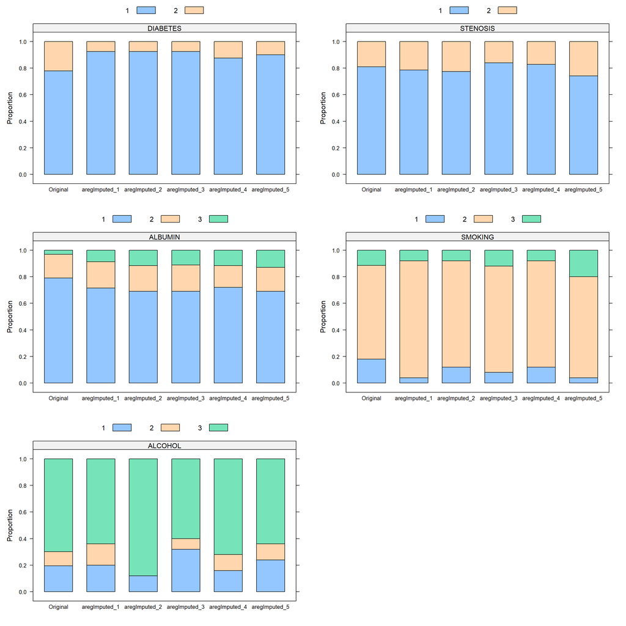

```r
##################################
# Evaluating the plausibility of the
# AREG-imputed values for the
# numerical variables
##################################

DIABETES_complete <- (DPP$DIABETES[complete.cases(DPP$DIABETES)])

DPP.AREGIMPUTED_aregImpute_DIABETES <- as.data.frame(DPP.AREGIMPUTED$imputed$DIABETES)

DIABETES_aregImpute_1 <- DPP.AREGIMPUTED_aregImpute_DIABETES$V1
DIABETES_aregImpute_2 <- DPP.AREGIMPUTED_aregImpute_DIABETES$V2
DIABETES_aregImpute_3 <- DPP.AREGIMPUTED_aregImpute_DIABETES$V3
DIABETES_aregImpute_4 <- DPP.AREGIMPUTED_aregImpute_DIABETES$V4
DIABETES_aregImpute_5 <- DPP.AREGIMPUTED_aregImpute_DIABETES$V5

DIABETES_values <- c(DIABETES_complete,
                       DIABETES_aregImpute_1,
                       DIABETES_aregImpute_2,
                       DIABETES_aregImpute_3,
                       DIABETES_aregImpute_4,
                       DIABETES_aregImpute_5)

DIABETES_labels <- c(rep("Original",length(DIABETES_complete)),
            rep("aregImputed_1",length(DIABETES_aregImpute_1)),
            rep("aregImputed_2",length(DIABETES_aregImpute_2)),
            rep("aregImputed_3",length(DIABETES_aregImpute_3)),
            rep("aregImputed_4",length(DIABETES_aregImpute_4)),
            rep("aregImputed_5",length(DIABETES_aregImpute_5)))

DIABETES_postimputation <- cbind(DIABETES_values,
                                 DIABETES_labels)

DIABETES_postimputation <- as.data.frame(DIABETES_postimputation)

colnames(DIABETES_postimputation) <- c("Value",
                                       "Category")

DIABETES_postimputation_proportion <- as.data.frame(prop.table(table(DIABETES_postimputation), 2))

DIABETES_postimputation_proportion$Category <- factor(DIABETES_postimputation_proportion$Category,
                                         levels=c("Original",
                                                  "aregImputed_1",
                                                  "aregImputed_2",
                                                  "aregImputed_3",
                                                  "aregImputed_4",
                                                  "aregImputed_5"))

DIABETES_postimputation_proportion$Variable <- rep("DIABETES",nrow(DIABETES_postimputation_proportion))

BAR_DIABETES <- barchart(Freq ~ Category | Variable,
         data=DIABETES_postimputation_proportion,
         groups = Value,
         stack=TRUE,
         ylab = "Proportion",
         auto.key = list(adj=1, space="top", columns=2))


STENOSIS_complete <- (DPP$STENOSIS[complete.cases(DPP$STENOSIS)])

DPP.AREGIMPUTED_aregImpute_STENOSIS <- as.data.frame(DPP.AREGIMPUTED$imputed$STENOSIS)

STENOSIS_aregImpute_1 <- DPP.AREGIMPUTED_aregImpute_STENOSIS$V1
STENOSIS_aregImpute_2 <- DPP.AREGIMPUTED_aregImpute_STENOSIS$V2
STENOSIS_aregImpute_3 <- DPP.AREGIMPUTED_aregImpute_STENOSIS$V3
STENOSIS_aregImpute_4 <- DPP.AREGIMPUTED_aregImpute_STENOSIS$V4
STENOSIS_aregImpute_5 <- DPP.AREGIMPUTED_aregImpute_STENOSIS$V5

STENOSIS_values <- c(STENOSIS_complete,
                       STENOSIS_aregImpute_1,
                       STENOSIS_aregImpute_2,
                       STENOSIS_aregImpute_3,
                       STENOSIS_aregImpute_4,
                       STENOSIS_aregImpute_5)

STENOSIS_labels <- c(rep("Original",length(STENOSIS_complete)),
            rep("aregImputed_1",length(STENOSIS_aregImpute_1)),
            rep("aregImputed_2",length(STENOSIS_aregImpute_2)),
            rep("aregImputed_3",length(STENOSIS_aregImpute_3)),
            rep("aregImputed_4",length(STENOSIS_aregImpute_4)),
            rep("aregImputed_5",length(STENOSIS_aregImpute_5)))

STENOSIS_postimputation <- cbind(STENOSIS_values,
                                 STENOSIS_labels)

STENOSIS_postimputation <- as.data.frame(STENOSIS_postimputation)

colnames(STENOSIS_postimputation) <- c("Value",
                                       "Category")

STENOSIS_postimputation_proportion <- as.data.frame(prop.table(table(STENOSIS_postimputation), 2))

STENOSIS_postimputation_proportion$Category <- factor(STENOSIS_postimputation_proportion$Category,
                                         levels=c("Original",
                                                  "aregImputed_1",
                                                  "aregImputed_2",
                                                  "aregImputed_3",
                                                  "aregImputed_4",
                                                  "aregImputed_5"))

STENOSIS_postimputation_proportion$Variable <- rep("STENOSIS",nrow(STENOSIS_postimputation_proportion))

BAR_STENOSIS <- barchart(Freq ~ Category | Variable,
         data=STENOSIS_postimputation_proportion,
         groups = Value,
         stack=TRUE,
         ylab = "Proportion",
         auto.key = list(adj=1, space="top", columns=2))

ALBUMIN_complete <- (DPP$ albumin [complete.cases(DPP$albumin)])

DPP.AREGIMPUTED_aregImpute_ALBUMIN <- as.data.frame(DPP.AREGIMPUTED$imputed$ albumin)

ALBUMIN_aregImpute_1 <- DPP.AREGIMPUTED_aregImpute_ALBUMIN$V1
ALBUMIN_aregImpute_2 <- DPP.AREGIMPUTED_aregImpute_ALBUMIN$V2
ALBUMIN_aregImpute_3 <- DPP.AREGIMPUTED_aregImpute_ALBUMIN$V3
ALBUMIN_aregImpute_4 <- DPP.AREGIMPUTED_aregImpute_ALBUMIN$V4
ALBUMIN_aregImpute_5 <- DPP.AREGIMPUTED_aregImpute_ALBUMIN$V5

ALBUMIN_values <- c(ALBUMIN_complete,
                       ALBUMIN_aregImpute_1,
                       ALBUMIN_aregImpute_2,
                       ALBUMIN_aregImpute_3,
                       ALBUMIN_aregImpute_4,
                       ALBUMIN_aregImpute_5)

ALBUMIN_labels <- c(rep("Original",length(ALBUMIN_complete)),
            rep("aregImputed_1",length(ALBUMIN_aregImpute_1)),
            rep("aregImputed_2",length(ALBUMIN_aregImpute_2)),
            rep("aregImputed_3",length(ALBUMIN_aregImpute_3)),
            rep("aregImputed_4",length(ALBUMIN_aregImpute_4)),
            rep("aregImputed_5",length(ALBUMIN_aregImpute_5)))

ALBUMIN_postimputation <- cbind(ALBUMIN_values,
                                 ALBUMIN_labels)

ALBUMIN_postimputation <- as.data.frame(ALBUMIN_postimputation)

colnames(ALBUMIN_postimputation) <- c("Value",
                                       "Category")

ALBUMIN_postimputation_proportion <- as.data.frame(prop.table(table(ALBUMIN_postimputation), 2))

ALBUMIN_postimputation_proportion$Category <- factor(ALBUMIN_postimputation_proportion$Category,
                                         levels=c("Original",
                                                  "aregImputed_1",
                                                  "aregImputed_2",
                                                  "aregImputed_3",
                                                  "aregImputed_4",
                                                  "aregImputed_5"))

ALBUMIN_postimputation_proportion$Variable <- rep("ALBUMIN",nrow(ALBUMIN_postimputation_proportion))

BAR_ALBUMIN <- barchart(Freq ~ Category | Variable,
         data=ALBUMIN_postimputation_proportion,
         groups = Value,
         stack=TRUE,
         ylab = "Proportion",
         auto.key = list(adj=1, space="top", columns=3))

SMOKING_complete <- (DPP$ SMOKING [complete.cases(DPP$SMOKING)])

DPP.AREGIMPUTED_aregImpute_SMOKING <- as.data.frame(DPP.AREGIMPUTED$imputed$SMOKING)

SMOKING_aregImpute_1 <- DPP.AREGIMPUTED_aregImpute_SMOKING$V1
SMOKING_aregImpute_2 <- DPP.AREGIMPUTED_aregImpute_SMOKING$V2
SMOKING_aregImpute_3 <- DPP.AREGIMPUTED_aregImpute_SMOKING$V3
SMOKING_aregImpute_4 <- DPP.AREGIMPUTED_aregImpute_SMOKING$V4
SMOKING_aregImpute_5 <- DPP.AREGIMPUTED_aregImpute_SMOKING$V5

SMOKING_values <- c(SMOKING_complete,
                       SMOKING_aregImpute_1,
                       SMOKING_aregImpute_2,
                       SMOKING_aregImpute_3,
                       SMOKING_aregImpute_4,
                       SMOKING_aregImpute_5)

SMOKING_labels <- c(rep("Original",length(SMOKING_complete)),
            rep("aregImputed_1",length(SMOKING_aregImpute_1)),
            rep("aregImputed_2",length(SMOKING_aregImpute_2)),
            rep("aregImputed_3",length(SMOKING_aregImpute_3)),
            rep("aregImputed_4",length(SMOKING_aregImpute_4)),
            rep("aregImputed_5",length(SMOKING_aregImpute_5)))

SMOKING_postimputation <- cbind(SMOKING_values,
                                 SMOKING_labels)

SMOKING_postimputation <- as.data.frame(SMOKING_postimputation)

colnames(SMOKING_postimputation) <- c("Value",
                                       "Category")

SMOKING_postimputation_proportion <- as.data.frame(prop.table(table(SMOKING_postimputation), 2))

SMOKING_postimputation_proportion$Category <- factor(SMOKING_postimputation_proportion$Category,
                                         levels=c("Original",
                                                  "aregImputed_1",
                                                  "aregImputed_2",
                                                  "aregImputed_3",
                                                  "aregImputed_4",
                                                  "aregImputed_5"))

SMOKING_postimputation_proportion$Variable <- rep("SMOKING",nrow(SMOKING_postimputation_proportion))

BAR_SMOKING <- barchart(Freq ~ Category | Variable,
         data=SMOKING_postimputation_proportion,
         groups = Value,
         stack=TRUE,
         ylab = "Proportion",
         auto.key = list(adj=1, space="top", columns=3))

ALCOHOL_complete <- (DPP$ alcohol [complete.cases(DPP$alcohol)])

DPP.AREGIMPUTED_aregImpute_ALCOHOL <- as.data.frame(DPP.AREGIMPUTED$imputed$alcohol)

ALCOHOL_aregImpute_1 <- DPP.AREGIMPUTED_aregImpute_ALCOHOL$V1
ALCOHOL_aregImpute_2 <- DPP.AREGIMPUTED_aregImpute_ALCOHOL$V2
ALCOHOL_aregImpute_3 <- DPP.AREGIMPUTED_aregImpute_ALCOHOL$V3
ALCOHOL_aregImpute_4 <- DPP.AREGIMPUTED_aregImpute_ALCOHOL$V4
ALCOHOL_aregImpute_5 <- DPP.AREGIMPUTED_aregImpute_ALCOHOL$V5

ALCOHOL_values <- c(ALCOHOL_complete,
                       ALCOHOL_aregImpute_1,
                       ALCOHOL_aregImpute_2,
                       ALCOHOL_aregImpute_3,
                       ALCOHOL_aregImpute_4,
                       ALCOHOL_aregImpute_5)

ALCOHOL_labels <- c(rep("Original",length(ALCOHOL_complete)),
            rep("aregImputed_1",length(ALCOHOL_aregImpute_1)),
            rep("aregImputed_2",length(ALCOHOL_aregImpute_2)),
            rep("aregImputed_3",length(ALCOHOL_aregImpute_3)),
            rep("aregImputed_4",length(ALCOHOL_aregImpute_4)),
            rep("aregImputed_5",length(ALCOHOL_aregImpute_5)))

ALCOHOL_postimputation <- cbind(ALCOHOL_values,
                                 ALCOHOL_labels)

ALCOHOL_postimputation <- as.data.frame(ALCOHOL_postimputation)

colnames(ALCOHOL_postimputation) <- c("Value",
                                       "Category")

ALCOHOL_postimputation_proportion <- as.data.frame(prop.table(table(ALCOHOL_postimputation), 2))

ALCOHOL_postimputation_proportion$Category <- factor(ALCOHOL_postimputation_proportion$Category,
                                         levels=c("Original",
                                                  "aregImputed_1",
                                                  "aregImputed_2",
                                                  "aregImputed_3",
                                                  "aregImputed_4",
                                                  "aregImputed_5"))

ALCOHOL_postimputation_proportion$Variable <- rep("ALCOHOL",nrow(ALCOHOL_postimputation_proportion))

BAR_ALCOHOL <- barchart(Freq ~ Category | Variable,
         data=ALCOHOL_postimputation_proportion,
         groups = Value,
         stack=TRUE,
         ylab = "Proportion",
         auto.key = list(adj=1, space="top", columns=3))


grid.arrange(BAR_DIABETES,
             BAR_STENOSIS,
             BAR_ALBUMIN,
             BAR_SMOKING,
             BAR_ALCOHOL,
             ncol = 2)
```

### 1.2.5 Model Specification

Missing data imputation evaluation using full model specification:  
**[A]** Certain variables were initially excluded for modelling in order to (1) reduce potential multicollinearity among predictors (those which reported high variance inflation factor values); (2) remove variables which were minimally associated to the outcome based from initial data exploration (those which reported low Wald chi-squared values); and (3) only retain important and standard risk factors (those which have been previously shown as significant clinical survival predictors based from expert recommendations and/or literature review) :  
**[A.1]** DIASTH variable (numeric)  
**[A.2]** DIASBP variable (numeric)  
**[A.3]** SYSTBP variable (numeric)  
**[A.4]** LENGTH variable (numeric)  
**[A.5]** WEIGHT variable (numeric)  
**[A.6]** CHOL variable (numeric)  
**[A.7]** LDL variable (numeric)  
**[A.8]** TRIG variable (numeric)  
**[A.9]** GLUT variable (numeric)  
**[A.10]** PACKYRS variable (numeric)  
**[B]** The variables selected to be a part of the full model comprised of the following:  
**[B.1]** AGE variable (numeric) coded using its squared value after 50 years [if (AGE>50) then (AGE-50)^2 else 0]  
**[B.2]** SEX variable (factor)  
**[B.3]** SMOKING variable (factor)  
**[B.4]** ALCOHOL variable (factor)  
**[B.5]** BMI variable (numeric)  
**[B.6]** SYSTH variable (numeric)  
**[B.7]** HDL variable (numeric)  
**[B.8]** DIABETES variable (factor)  
**[B.9]** CEREBRAL variable (numeric), CARDIAC variable (numeric), AAA variable (numeric) and PERIPH variable (numeric) coded using their linear combination [CEREBRAL + CARDIAC + (2*AAA) + PERIPH] called SUMSCORE_5LEVELS variable (numeric)  
**[B.10]** HOMOC variable (numeric)  
**[B.11]** CREAT variable (numeric) coded using its logarithm [log(CREAT)]  
**[B.12]** ALBUMIN variable (factor)  
**[B.13]** STENOSIS variable (factor)  
**[B.14]** IMT variable (numeric)  
**[B.15]** HOMOC variable (numeric)  
**[C]** The five imputed datasets (aregImputed_1, aregImputed_2, aregImputed_3, aregImputed_4 and aregImputed_5) demonstrated generally stable estimated coefficients for the full cox proportional hazards model. The imputed data from iteration 3 (aregImputed_3) was assigned for the subsequent model selection process.

**Code Chunk | Output**

```r
##################################
# Loading the modelling dataset
# by combining the complete and imputed values
##################################

##################################
# Combining the complete and
# 1ST imputation results from AREG
##################################
DPP.AREGIMPUTED_1 <- impute.transcan(DPP.AREGIMPUTED,
                                     imputation=1,
                                     data=DPP,
                                     list.out=TRUE,
                                     pr=FALSE,
                                     check=FALSE)

SMART.AREGIMPUTED_1 <- SMART

SMART.AREGIMPUTED_1[names(DPP.AREGIMPUTED_1)] <- DPP.AREGIMPUTED_1

SMART.AREGIMPUTED_1$CEREBRAL  <- as.numeric(as.character(SMART.AREGIMPUTED_1$CEREBRAL))
SMART.AREGIMPUTED_1$CARDIAC   <- as.numeric(as.character(SMART.AREGIMPUTED_1$CARDIAC))
SMART.AREGIMPUTED_1$AAA       <- as.numeric(as.character(SMART.AREGIMPUTED_1$AAA))
SMART.AREGIMPUTED_1$PERIPH    <- as.numeric(as.character(SMART.AREGIMPUTED_1$PERIPH))

SMART.AREGIMPUTED_1$SUMSCORE_5LEVELS  <- SMART.AREGIMPUTED_1$CEREBRAL +
  SMART.AREGIMPUTED_1$CARDIAC +
  (2*SMART.AREGIMPUTED_1$AAA) +
  SMART.AREGIMPUTED_1$PERIPH

##################################
# Combining the complete and
# 2ND imputation results from AREG
##################################
DPP.AREGIMPUTED_2 <- impute.transcan(DPP.AREGIMPUTED,
                                     imputation=2,
                                     data=DPP,
                                     list.out=TRUE,
                                     pr=FALSE,
                                     check=FALSE)

SMART.AREGIMPUTED_2 <- SMART

SMART.AREGIMPUTED_2[names(DPP.AREGIMPUTED_2)] <- DPP.AREGIMPUTED_2

SMART.AREGIMPUTED_2$CEREBRAL  <- as.numeric(as.character(SMART.AREGIMPUTED_2$CEREBRAL))
SMART.AREGIMPUTED_2$CARDIAC   <- as.numeric(as.character(SMART.AREGIMPUTED_2$CARDIAC))
SMART.AREGIMPUTED_2$AAA       <- as.numeric(as.character(SMART.AREGIMPUTED_2$AAA))
SMART.AREGIMPUTED_2$PERIPH    <- as.numeric(as.character(SMART.AREGIMPUTED_2$PERIPH))

SMART.AREGIMPUTED_2$SUMSCORE_5LEVELS  <- SMART.AREGIMPUTED_2$CEREBRAL +
  SMART.AREGIMPUTED_2$CARDIAC +
  (2*SMART.AREGIMPUTED_2$AAA) +
  SMART.AREGIMPUTED_2$PERIPH

##################################
# Combining the complete and
# 3RD imputation results from AREG
##################################
DPP.AREGIMPUTED_3 <- impute.transcan(DPP.AREGIMPUTED,
                                     imputation=3,
                                     data=DPP,
                                     list.out=TRUE,
                                     pr=FALSE,
                                     check=FALSE)

SMART.AREGIMPUTED_3 <- SMART

SMART.AREGIMPUTED_3[names(DPP.AREGIMPUTED_3)] <- DPP.AREGIMPUTED_3

SMART.AREGIMPUTED_3$CEREBRAL  <- as.numeric(as.character(SMART.AREGIMPUTED_3$CEREBRAL))
SMART.AREGIMPUTED_3$CARDIAC   <- as.numeric(as.character(SMART.AREGIMPUTED_3$CARDIAC))
SMART.AREGIMPUTED_3$AAA       <- as.numeric(as.character(SMART.AREGIMPUTED_3$AAA))
SMART.AREGIMPUTED_3$PERIPH    <- as.numeric(as.character(SMART.AREGIMPUTED_3$PERIPH))

SMART.AREGIMPUTED_3$SUMSCORE_5LEVELS  <- SMART.AREGIMPUTED_3$CEREBRAL +
  SMART.AREGIMPUTED_3$CARDIAC +
  (2*SMART.AREGIMPUTED_3$AAA) +
  SMART.AREGIMPUTED_3$PERIPH

##################################
# Combining the complete and
# 4TH imputation results from AREG
##################################
DPP.AREGIMPUTED_4 <- impute.transcan(DPP.AREGIMPUTED,
                                     imputation=4,
                                     data=DPP,
                                     list.out=TRUE,
                                     pr=FALSE,
                                     check=FALSE)

SMART.AREGIMPUTED_4 <- SMART

SMART.AREGIMPUTED_4[names(DPP.AREGIMPUTED_4)] <- DPP.AREGIMPUTED_4

SMART.AREGIMPUTED_4$CEREBRAL  <- as.numeric(as.character(SMART.AREGIMPUTED_4$CEREBRAL))
SMART.AREGIMPUTED_4$CARDIAC   <- as.numeric(as.character(SMART.AREGIMPUTED_4$CARDIAC))
SMART.AREGIMPUTED_4$AAA       <- as.numeric(as.character(SMART.AREGIMPUTED_4$AAA))
SMART.AREGIMPUTED_4$PERIPH    <- as.numeric(as.character(SMART.AREGIMPUTED_4$PERIPH))

SMART.AREGIMPUTED_4$SUMSCORE_5LEVELS  <- SMART.AREGIMPUTED_4$CEREBRAL +
  SMART.AREGIMPUTED_4$CARDIAC +
  (2*SMART.AREGIMPUTED_4$AAA) +
  SMART.AREGIMPUTED_4$PERIPH

##################################
# Combining the complete and
# 5TH imputation results from AREG
##################################
DPP.AREGIMPUTED_5 <- impute.transcan(DPP.AREGIMPUTED,
                                     imputation=5,
                                     data=DPP,
                                     list.out=TRUE,
                                     pr=FALSE,
                                     check=FALSE)

SMART.AREGIMPUTED_5 <- SMART

SMART.AREGIMPUTED_5[names(DPP.AREGIMPUTED_5)] <- DPP.AREGIMPUTED_5

SMART.AREGIMPUTED_5$CEREBRAL  <- as.numeric(as.character(SMART.AREGIMPUTED_5$CEREBRAL))
SMART.AREGIMPUTED_5$CARDIAC   <- as.numeric(as.character(SMART.AREGIMPUTED_5$CARDIAC))
SMART.AREGIMPUTED_5$AAA       <- as.numeric(as.character(SMART.AREGIMPUTED_5$AAA))
SMART.AREGIMPUTED_5$PERIPH    <- as.numeric(as.character(SMART.AREGIMPUTED_5$PERIPH))

SMART.AREGIMPUTED_5$SUMSCORE_5LEVELS  <- SMART.AREGIMPUTED_5$CEREBRAL +
  SMART.AREGIMPUTED_5$CARDIAC +
  (2*SMART.AREGIMPUTED_5$AAA) +
  SMART.AREGIMPUTED_5$PERIPH

##################################
# Exploring the single imputation
# results using AREG
##################################

describe(SMART.AREGIMPUTED_1)
```

```
## SMART.AREGIMPUTED_1
##
##  30  Variables      3873  Observations
## --------------------------------------------------------------------------------
## TEVENT
##        n  missing distinct     Info     Mean      Gmd      .05      .10
##     3873        0     1934        1     1370     1078     98.6    197.0
##      .25      .50      .75      .90      .95
##    555.0   1213.0   2165.0   2762.4   3017.4
##
## lowest : 0.1  1    2    3    4   , highest: 3451 3452 3463 3465 3466
## --------------------------------------------------------------------------------
## EVENT
##        n  missing distinct
##     3873        0        2
##
## Value          0     1
## Frequency   3413   460
## Proportion 0.881 0.119
## --------------------------------------------------------------------------------
## SEX
##        n  missing distinct
##     3873        0        2
##
## Value          1     2
## Frequency   2897   976
## Proportion 0.748 0.252
## --------------------------------------------------------------------------------
## AGE
##        n  missing distinct     Info     Mean      Gmd      .05      .10
##     3873        0       62    0.999    59.56    11.94       41       46
##      .25      .50      .75      .90      .95
##       52       60       68       73       76
##
## lowest : 19 20 23 24 25, highest: 78 79 80 81 82
## --------------------------------------------------------------------------------
## DIABETES
##        n  missing  imputed distinct
##     3873        0       40        2
##
```

[output cut: 179 more lines]

```
##
## Value          1     2     3
## Frequency    756   412  2705
## Proportion 0.195 0.106 0.698
## --------------------------------------------------------------------------------
## SUMSCORE_5LEVELS
##        n  missing distinct     Info     Mean      Gmd
##     3873        0        5    0.532    1.311    0.511
##
## Value          1     2     3     4     5
## Frequency   2999   605   211    53     5
## Proportion 0.774 0.156 0.054 0.014 0.001
##
## For the frequency table, variable is rounded to the nearest 0
## --------------------------------------------------------------------------------
```

```r
describe(SMART.AREGIMPUTED_2)
```

```
## SMART.AREGIMPUTED_2
##
##  30  Variables      3873  Observations
## --------------------------------------------------------------------------------
## TEVENT
##        n  missing distinct     Info     Mean      Gmd      .05      .10
##     3873        0     1934        1     1370     1078     98.6    197.0
##      .25      .50      .75      .90      .95
##    555.0   1213.0   2165.0   2762.4   3017.4
##
## lowest : 0.1  1    2    3    4   , highest: 3451 3452 3463 3465 3466
## --------------------------------------------------------------------------------
## EVENT
##        n  missing distinct
##     3873        0        2
##
## Value          0     1
## Frequency   3413   460
## Proportion 0.881 0.119
## --------------------------------------------------------------------------------
## SEX
##        n  missing distinct
##     3873        0        2
##
## Value          1     2
## Frequency   2897   976
## Proportion 0.748 0.252
## --------------------------------------------------------------------------------
## AGE
##        n  missing distinct     Info     Mean      Gmd      .05      .10
##     3873        0       62    0.999    59.56    11.94       41       46
##      .25      .50      .75      .90      .95
##       52       60       68       73       76
##
## lowest : 19 20 23 24 25, highest: 78 79 80 81 82
## --------------------------------------------------------------------------------
## DIABETES
##        n  missing  imputed distinct
##     3873        0       40        2
##
```

[output cut: 179 more lines]

```
##
## Value          1     2     3
## Frequency    754   408  2711
## Proportion 0.195 0.105 0.700
## --------------------------------------------------------------------------------
## SUMSCORE_5LEVELS
##        n  missing distinct     Info     Mean      Gmd
##     3873        0        5    0.532    1.311    0.511
##
## Value          1     2     3     4     5
## Frequency   2999   605   211    53     5
## Proportion 0.774 0.156 0.054 0.014 0.001
##
## For the frequency table, variable is rounded to the nearest 0
## --------------------------------------------------------------------------------
```

```r
describe(SMART.AREGIMPUTED_3)
```

```
## SMART.AREGIMPUTED_3
##
##  30  Variables      3873  Observations
## --------------------------------------------------------------------------------
## TEVENT
##        n  missing distinct     Info     Mean      Gmd      .05      .10
##     3873        0     1934        1     1370     1078     98.6    197.0
##      .25      .50      .75      .90      .95
##    555.0   1213.0   2165.0   2762.4   3017.4
##
## lowest : 0.1  1    2    3    4   , highest: 3451 3452 3463 3465 3466
## --------------------------------------------------------------------------------
## EVENT
##        n  missing distinct
##     3873        0        2
##
## Value          0     1
## Frequency   3413   460
## Proportion 0.881 0.119
## --------------------------------------------------------------------------------
## SEX
##        n  missing distinct
##     3873        0        2
##
## Value          1     2
## Frequency   2897   976
## Proportion 0.748 0.252
## --------------------------------------------------------------------------------
## AGE
##        n  missing distinct     Info     Mean      Gmd      .05      .10
##     3873        0       62    0.999    59.56    11.94       41       46
##      .25      .50      .75      .90      .95
##       52       60       68       73       76
##
## lowest : 19 20 23 24 25, highest: 78 79 80 81 82
## --------------------------------------------------------------------------------
## DIABETES
##        n  missing  imputed distinct
##     3873        0       40        2
##
```

[output cut: 179 more lines]

```
##
## Value          1     2     3
## Frequency    759   410  2704
## Proportion 0.196 0.106 0.698
## --------------------------------------------------------------------------------
## SUMSCORE_5LEVELS
##        n  missing distinct     Info     Mean      Gmd
##     3873        0        5    0.532    1.311    0.511
##
## Value          1     2     3     4     5
## Frequency   2999   605   211    53     5
## Proportion 0.774 0.156 0.054 0.014 0.001
##
## For the frequency table, variable is rounded to the nearest 0
## --------------------------------------------------------------------------------
```

```r
describe(SMART.AREGIMPUTED_4)
```

```
## SMART.AREGIMPUTED_4
##
##  30  Variables      3873  Observations
## --------------------------------------------------------------------------------
## TEVENT
##        n  missing distinct     Info     Mean      Gmd      .05      .10
##     3873        0     1934        1     1370     1078     98.6    197.0
##      .25      .50      .75      .90      .95
##    555.0   1213.0   2165.0   2762.4   3017.4
##
## lowest : 0.1  1    2    3    4   , highest: 3451 3452 3463 3465 3466
## --------------------------------------------------------------------------------
## EVENT
##        n  missing distinct
##     3873        0        2
##
## Value          0     1
## Frequency   3413   460
## Proportion 0.881 0.119
## --------------------------------------------------------------------------------
## SEX
##        n  missing distinct
##     3873        0        2
##
## Value          1     2
## Frequency   2897   976
## Proportion 0.748 0.252
## --------------------------------------------------------------------------------
## AGE
##        n  missing distinct     Info     Mean      Gmd      .05      .10
##     3873        0       62    0.999    59.56    11.94       41       46
##      .25      .50      .75      .90      .95
##       52       60       68       73       76
##
## lowest : 19 20 23 24 25, highest: 78 79 80 81 82
## --------------------------------------------------------------------------------
## DIABETES
##        n  missing  imputed distinct
##     3873        0       40        2
##
```

[output cut: 179 more lines]

```
##
## Value          1     2     3
## Frequency    755   411  2707
## Proportion 0.195 0.106 0.699
## --------------------------------------------------------------------------------
## SUMSCORE_5LEVELS
##        n  missing distinct     Info     Mean      Gmd
##     3873        0        5    0.532    1.311    0.511
##
## Value          1     2     3     4     5
## Frequency   2999   605   211    53     5
## Proportion 0.774 0.156 0.054 0.014 0.001
##
## For the frequency table, variable is rounded to the nearest 0
## --------------------------------------------------------------------------------
```

```r
describe(SMART.AREGIMPUTED_5)
```

```
## SMART.AREGIMPUTED_5
##
##  30  Variables      3873  Observations
## --------------------------------------------------------------------------------
## TEVENT
##        n  missing distinct     Info     Mean      Gmd      .05      .10
##     3873        0     1934        1     1370     1078     98.6    197.0
##      .25      .50      .75      .90      .95
##    555.0   1213.0   2165.0   2762.4   3017.4
##
## lowest : 0.1  1    2    3    4   , highest: 3451 3452 3463 3465 3466
## --------------------------------------------------------------------------------
## EVENT
##        n  missing distinct
##     3873        0        2
##
## Value          0     1
## Frequency   3413   460
## Proportion 0.881 0.119
## --------------------------------------------------------------------------------
## SEX
##        n  missing distinct
##     3873        0        2
##
## Value          1     2
## Frequency   2897   976
## Proportion 0.748 0.252
## --------------------------------------------------------------------------------
## AGE
##        n  missing distinct     Info     Mean      Gmd      .05      .10
##     3873        0       62    0.999    59.56    11.94       41       46
##      .25      .50      .75      .90      .95
##       52       60       68       73       76
##
## lowest : 19 20 23 24 25, highest: 78 79 80 81 82
## --------------------------------------------------------------------------------
## DIABETES
##        n  missing  imputed distinct
##     3873        0       40        2
##
```

[output cut: 179 more lines]

```
##
## Value          1     2     3
## Frequency    757   411  2705
## Proportion 0.195 0.106 0.698
## --------------------------------------------------------------------------------
## SUMSCORE_5LEVELS
##        n  missing distinct     Info     Mean      Gmd
##     3873        0        5    0.532    1.311    0.511
##
## Value          1     2     3     4     5
## Frequency   2999   605   211    53     5
## Proportion 0.774 0.156 0.054 0.014 0.001
##
## For the frequency table, variable is rounded to the nearest 0
## --------------------------------------------------------------------------------
```

```r
##################################
# Formulating the FULL
# Cox Proportional Hazards Model
# Using the combined complete and
# 1ST imputation results from AREG
##################################

SMART.AREGIMPUTED_1$EVENT <- as.numeric(SMART.AREGIMPUTED_1$EVENT)
SMART.AREGIMPUTED_1$SMOKING <- as.factor(SMART.AREGIMPUTED_1$SMOKING)
SMART.AREGIMPUTED_1$alcohol <- as.factor(SMART.AREGIMPUTED_1$alcohol)
SMART.AREGIMPUTED_1$albumin <- as.factor(SMART.AREGIMPUTED_1$albumin)

dd <- datadist(SMART.AREGIMPUTED_1)
options(datadist="dd")

##################################
# FULL COMPLETE
##################################

COXPH.FULL.COMPLETE.AREGIMPUTED_1 <-cph(Surv(TEVENT,EVENT) ~  ifelse(AGE>50, (AGE-50)^2,0) +
                                 SEX +
                                 SMOKING +
                                 alcohol +
                                 BMI +
                                 SYSTH +
                                 SYSTBP +
                                 DIASTH +
                                 DIASTBP +
                                 WEIGHT +
                                 LENGTH +
                                 CHOL +
                                 LDL +
                                 HDL+
                                 DIABETES +
                                 SUMSCORE_5LEVELS +
                                 HOMOC +
                                 log(CREAT) +
                                 albumin +
                                 STENOSIS +
                                 IMT +
                                 TRIG +
                                 GLUT +
                                 packyrs,
                               data = SMART.AREGIMPUTED_1,
                               x=T,
                               y=T,
                               surv=T)
anova(COXPH.FULL.COMPLETE.AREGIMPUTED_1)
```

```
##                 Wald Statistics          Response: Surv(TEVENT, EVENT)
##
##  Factor           Chi-Square d.f. P
##  AGE               36.78      1   <.0001
##  SEX                0.88      1   0.3477
##  SMOKING            0.13      2   0.9381
##  alcohol            1.83      2   0.4004
##  BMI                0.70      1   0.4029
##  SYSTH              0.27      1   0.6059
##  SYSTBP             0.01      1   0.9269
##  DIASTH             2.02      1   0.1556
##  DIASTBP            0.18      1   0.6745
##  WEIGHT             1.28      1   0.2575
##  LENGTH             0.64      1   0.4242
##  CHOL               0.14      1   0.7100
##  LDL                0.19      1   0.6664
##  HDL                0.00      1   0.9978
##  DIABETES           0.17      1   0.6790
##  SUMSCORE_5LEVELS  34.66      1   <.0001
##  HOMOC              0.01      1   0.9157
##  CREAT             18.21      1   <.0001
##  albumin            9.55      2   0.0084
##  STENOSIS           2.29      1   0.1302
##  IMT                9.33      1   0.0023
##  TRIG               0.14      1   0.7067
##  GLUT               2.83      1   0.0922
##  packyrs            5.29      1   0.0214
##  TOTAL            328.92     27   <.0001
```

```r
summary(COXPH.FULL.COMPLETE.AREGIMPUTED_1)
```

```
##              Effects              Response : Surv(TEVENT, EVENT)
##
##  Factor           Low    High   Diff. Effect     S.E.     Lower 0.95 Upper 0.95
##  AGE               52.00  68.00 16.00  0.4359300 0.071877  0.2950500  0.576800
##   Hazard Ratio     52.00  68.00 16.00  1.5464000       NA  1.3432000  1.780300
##  BMI               24.11  28.73  4.62  0.4127800 0.493520 -0.5545000  1.380100
##   Hazard Ratio     24.11  28.73  4.62  1.5110000       NA  0.5743600  3.975100
##  SYSTH            127.00 157.00 30.00 -0.0614390 0.119090 -0.2948400  0.171960
##   Hazard Ratio    127.00 157.00 30.00  0.9404100       NA  0.7446500  1.187600
##  SYSTBP           126.00 153.00 27.00 -0.0105570 0.115110 -0.2361700  0.215050
##   Hazard Ratio    126.00 153.00 27.00  0.9895000       NA  0.7896500  1.239900
##  DIASTH            74.00  89.00 15.00  0.1512000 0.106460 -0.0574710  0.359860
##   Hazard Ratio     74.00  89.00 15.00  1.1632000       NA  0.9441500  1.433100
##  DIASTBP           73.00  86.00 13.00 -0.0410810 0.097805 -0.2327800  0.150610
##   Hazard Ratio     73.00  86.00 13.00  0.9597500       NA  0.7923300  1.162500
##  WEIGHT            72.00  89.00 17.00 -0.6868900 0.606660 -1.8759000  0.502160
##   Hazard Ratio     72.00  89.00 17.00  0.5031400       NA  0.1532100  1.652300
##  LENGTH             1.68   1.80  0.12  0.3213700 0.402110 -0.4667600  1.109500
##   Hazard Ratio      1.68   1.80  0.12  1.3790000       NA  0.6270300  3.032800
##  CHOL               4.40   5.90  1.50 -0.5446400 1.464600 -3.4152000  2.325900
##   Hazard Ratio      4.40   5.90  1.50  0.5800500       NA  0.0328700 10.236000
##  LDL                2.37   3.83  1.46  0.6199000 1.438000 -2.1985000  3.438300
##   Hazard Ratio      2.37   3.83  1.46  1.8587000       NA  0.1109600 31.135000
##  HDL                0.96   1.42  0.46 -0.0012456 0.455170 -0.8933600  0.890870
##   Hazard Ratio      0.96   1.42  0.46  0.9987600       NA  0.4092800  2.437300
##  SUMSCORE_5LEVELS   1.00   5.00  4.00  1.3307000 0.226020  0.8876800  1.773700
##   Hazard Ratio      1.00   5.00  4.00  3.7836000       NA  2.4295000  5.892400
##  HOMOC             10.50  16.20  5.70 -0.0052107 0.049239 -0.1017200  0.091297
##   Hazard Ratio     10.50  16.20  5.70  0.9948000       NA  0.9032800  1.095600
##  CREAT             78.00 101.00 23.00  0.1653600 0.038752  0.0894030  0.241310
##   Hazard Ratio     78.00 101.00 23.00  1.1798000       NA  1.0935000  1.272900
##  IMT                0.75   1.07  0.32  0.1772100 0.058007  0.0635150  0.290900
##   Hazard Ratio      0.75   1.07  0.32  1.1939000       NA  1.0656000  1.337600
##  TRIG               1.12   2.23  1.11  0.1800500 0.478510 -0.7578200  1.117900
##   Hazard Ratio      1.12   2.23  1.11  1.1973000       NA  0.4686900  3.058500
##  GLUT               5.30   6.50  1.20  0.0593030 0.035222 -0.0097303  0.128340
##   Hazard Ratio      5.30   6.50  1.20  1.0611000       NA  0.9903200  1.136900
##  packyrs            5.90  34.20 28.30  0.1585500 0.068926  0.0234600  0.293650
##   Hazard Ratio      5.90  34.20 28.30  1.1718000       NA  1.0237000  1.341300
##  SEX - 2:1          1.00   2.00    NA -0.1524500 0.162350 -0.4706500  0.165750
##   Hazard Ratio      1.00   2.00    NA  0.8586000       NA  0.6246000  1.180300
##  SMOKING - 1:2      2.00   1.00    NA -0.0262960 0.161320 -0.3424800  0.289890
##   Hazard Ratio      2.00   1.00    NA  0.9740500       NA  0.7100000  1.336300
##  SMOKING - 3:2      2.00   3.00    NA  0.0602720 0.201840 -0.3353300  0.455880
##   Hazard Ratio      2.00   3.00    NA  1.0621000       NA  0.7151000  1.577600
##  alcohol - 1:3      3.00   1.00    NA  0.1474700 0.121360 -0.0903840  0.385330
##   Hazard Ratio      3.00   1.00    NA  1.1589000       NA  0.9135800  1.470100
##  alcohol - 2:3      3.00   2.00    NA -0.0417340 0.148450 -0.3326900  0.249220
##   Hazard Ratio      3.00   2.00    NA  0.9591200       NA  0.7169900  1.283000
##  DIABETES - 1:0     1.00   2.00    NA  0.0645840 0.156090 -0.2413400  0.370510
##   Hazard Ratio      1.00   2.00    NA  1.0667000       NA  0.7855700  1.448500
##  albumin - 2:1      1.00   2.00    NA  0.2609800 0.117980  0.0297510  0.492210
##   Hazard Ratio      1.00   2.00    NA  1.2982000       NA  1.0302000  1.635900
##  albumin - 3:1      1.00   3.00    NA  0.5620000 0.208220  0.1538900  0.970110
##   Hazard Ratio      1.00   3.00    NA  1.7542000       NA  1.1664000  2.638200
##  STENOSIS - 1:0     1.00   2.00    NA  0.1637700 0.108210 -0.0483250  0.375870
##   Hazard Ratio      1.00   2.00    NA  1.1779000       NA  0.9528200  1.456300
```

```r
vif(COXPH.FULL.COMPLETE.AREGIMPUTED_1)
```

```
##              AGE            SEX=2        SMOKING=2        SMOKING=3
##         1.422223         1.839738         1.917030         1.535045
##        alcohol=2        alcohol=3              BMI            SYSTH
##         1.439301         1.576363        63.830100         3.778977
##           SYSTBP           DIASTH          DIASTBP           WEIGHT
##         3.466886         3.098436         2.731506        89.258836
##           LENGTH             CHOL              LDL              HDL
##        34.868141       499.517309       446.035588        46.254999
##       DIABETES=1 SUMSCORE_5LEVELS            HOMOC            CREAT
##         2.268709         1.173653         1.521747         1.920921
##        albumin=2        albumin=3       STENOSIS=1              IMT
##         1.194679         1.573030         1.206110         1.329620
##             TRIG             GLUT          packyrs
##       117.623369         2.191857         1.355974
```

```r
COXPH.FULL.COMPLETE.AREGIMPUTED_1
```

```
## Cox Proportional Hazards Model
##
## cph(formula = Surv(TEVENT, EVENT) ~ ifelse(AGE > 50, (AGE - 50)^2,
##     0) + SEX + SMOKING + alcohol + BMI + SYSTH + SYSTBP + DIASTH +
##     DIASTBP + WEIGHT + LENGTH + CHOL + LDL + HDL + DIABETES +
##     SUMSCORE_5LEVELS + HOMOC + log(CREAT) + albumin + STENOSIS +
##     IMT + TRIG + GLUT + packyrs, data = SMART.AREGIMPUTED_1,
##     x = T, y = T, surv = T)
##
##                        Model Tests      Discrimination
##                                                Indexes
## Obs      3873    LR chi2    291.65      R2       0.087
## Events    460    d.f.           27    R2(27,3873)0.066
## Center 8.2501    Pr(> chi2) 0.0000     R2(27,460)0.437
##                  Score chi2 362.97      Dxy      0.395
##                  Pr(> chi2) 0.0000
##
##                  Coef    S.E.   Wald Z Pr(>|Z|)
## AGE               0.0014 0.0002  6.06  <0.0001
## SEX=2            -0.1524 0.1623 -0.94  0.3477
## SMOKING=2         0.0263 0.1613  0.16  0.8705
## SMOKING=3         0.0866 0.2445  0.35  0.7232
## alcohol=2        -0.1892 0.1673 -1.13  0.2581
## alcohol=3        -0.1475 0.1214 -1.22  0.2243
## BMI               0.0893 0.1068  0.84  0.4029
## SYSTH            -0.0020 0.0040 -0.52  0.6059
## SYSTBP           -0.0004 0.0043 -0.09  0.9269
## DIASTH            0.0101 0.0071  1.42  0.1556
## DIASTBP          -0.0032 0.0075 -0.42  0.6745
## WEIGHT           -0.0404 0.0357 -1.13  0.2575
## LENGTH            2.6781 3.3509  0.80  0.4242
## CHOL             -0.3631 0.9764 -0.37  0.7100
## LDL               0.4246 0.9849  0.43  0.6664
## HDL              -0.0027 0.9895  0.00  0.9978
## DIABETES=1        0.0646 0.1561  0.41  0.6790
## SUMSCORE_5LEVELS  0.3327 0.0565  5.89  <0.0001
## HOMOC            -0.0009 0.0086 -0.11  0.9157
## CREAT             0.6399 0.1500  4.27  <0.0001
## albumin=2         0.2610 0.1180  2.21  0.0270
## albumin=3         0.5620 0.2082  2.70  0.0070
## STENOSIS=1        0.1638 0.1082  1.51  0.1302
## IMT               0.5538 0.1813  3.05  0.0023
## TRIG              0.1622 0.4311  0.38  0.7067
## GLUT              0.0494 0.0294  1.68  0.0922
## packyrs           0.0056 0.0024  2.30  0.0214
```

```r
##################################
# FULL
# After removing variables which are:
# High multicollinearity contributors
# Non-standard risk factors
# Minimal predictors of survival outcome based from initial exploration
# Minimal predictors of survival outcome based from domain knowledge and literature
##################################

COXPH.FULL.AREGIMPUTED_1 <-cph(Surv(TEVENT,EVENT) ~  ifelse(AGE>50, (AGE-50)^2,0) +
                                 SEX +
                                 SMOKING +
                                 alcohol +
                                 BMI +
                                 SYSTH +
                                 HDL+
                                 DIABETES +
                                 SUMSCORE_5LEVELS +
                                 HOMOC +
                                 log(CREAT) +
                                 albumin +
                                 STENOSIS +
                                 IMT,
                               data = SMART.AREGIMPUTED_1,
                               x=T,
                               y=T,
                               surv=T)
anova(COXPH.FULL.AREGIMPUTED_1)
```

```
##                 Wald Statistics          Response: Surv(TEVENT, EVENT)
##
##  Factor           Chi-Square d.f. P
##  AGE               37.92      1   <.0001
##  SEX                0.15      1   0.6941
##  SMOKING            1.83      2   0.3998
##  alcohol            1.31      2   0.5189
##  BMI                3.06      1   0.0802
##  SYSTH              0.24      1   0.6232
##  HDL                5.61      1   0.0178
##  DIABETES           3.62      1   0.0570
##  SUMSCORE_5LEVELS  35.39      1   <.0001
##  HOMOC              0.01      1   0.9047
##  CREAT             16.77      1   <.0001
##  albumin            9.89      2   0.0071
##  STENOSIS           2.56      1   0.1099
##  IMT                8.73      1   0.0031
##  TOTAL            314.86     17   <.0001
```

```r
summary(COXPH.FULL.AREGIMPUTED_1)
```

```
##              Effects              Response : Surv(TEVENT, EVENT)
##
##  Factor           Low    High   Diff. Effect    S.E.     Lower 0.95 Upper 0.95
##  AGE               52.00  68.00 16.00  0.422220 0.068568  0.2878300  0.556610
##   Hazard Ratio     52.00  68.00 16.00  1.525300       NA  1.3335000  1.744800
##  BMI               24.11  28.73  4.62 -0.114360 0.065359 -0.2424600  0.013741
##   Hazard Ratio     24.11  28.73  4.62  0.891940       NA  0.7846900  1.013800
##  SYSTH            127.00 157.00 30.00  0.032049 0.065222 -0.0957840  0.159880
##   Hazard Ratio    127.00 157.00 30.00  1.032600       NA  0.9086600  1.173400
##  HDL                0.96   1.42  0.46 -0.173710 0.073314 -0.3174000 -0.030015
##   Hazard Ratio      0.96   1.42  0.46  0.840540       NA  0.7280400  0.970430
##  SUMSCORE_5LEVELS   1.00   5.00  4.00  1.327400 0.223150  0.8900700  1.764800
##   Hazard Ratio      1.00   5.00  4.00  3.771400       NA  2.4353000  5.840500
##  HOMOC             10.50  16.20  5.70  0.005793 0.048361 -0.0889930  0.100580
##   Hazard Ratio     10.50  16.20  5.70  1.005800       NA  0.9148500  1.105800
##  CREAT             78.00 101.00 23.00  0.155040 0.037857  0.0808410  0.229240
##   Hazard Ratio     78.00 101.00 23.00  1.167700       NA  1.0842000  1.257600
##  IMT                0.75   1.07  0.32  0.168820 0.057133  0.0568450  0.280800
##   Hazard Ratio      0.75   1.07  0.32  1.183900       NA  1.0585000  1.324200
##  SEX - 2:1          1.00   2.00    NA -0.053230 0.135340 -0.3184900  0.212030
##   Hazard Ratio      1.00   2.00    NA  0.948160       NA  0.7272400  1.236200
##  SMOKING - 1:2      2.00   1.00    NA -0.183620 0.144760 -0.4673500  0.100120
##   Hazard Ratio      2.00   1.00    NA  0.832250       NA  0.6266600  1.105300
##  SMOKING - 3:2      2.00   3.00    NA  0.066860 0.200970 -0.3270300  0.460750
##   Hazard Ratio      2.00   3.00    NA  1.069100       NA  0.7210600  1.585300
##  alcohol - 1:3      3.00   1.00    NA  0.126340 0.120810 -0.1104500  0.363130
##   Hazard Ratio      3.00   1.00    NA  1.134700       NA  0.8954300  1.437800
##  alcohol - 2:3      3.00   2.00    NA -0.029509 0.147220 -0.3180500  0.259030
##   Hazard Ratio      3.00   2.00    NA  0.970920       NA  0.7275700  1.295700
##  DIABETES - 1:0     1.00   2.00    NA  0.208900 0.109740 -0.0061847  0.423990
##   Hazard Ratio      1.00   2.00    NA  1.232300       NA  0.9938300  1.528000
##  albumin - 2:1      1.00   2.00    NA  0.264540 0.117310  0.0346040  0.494470
##   Hazard Ratio      1.00   2.00    NA  1.302800       NA  1.0352000  1.639600
##  albumin - 3:1      1.00   3.00    NA  0.562210 0.205920  0.1586100  0.965820
##   Hazard Ratio      1.00   3.00    NA  1.754600       NA  1.1719000  2.626900
##  STENOSIS - 1:0     1.00   2.00    NA  0.170850 0.106860 -0.0385980  0.380290
##   Hazard Ratio      1.00   2.00    NA  1.186300       NA  0.9621400  1.462700
```

```r
vif(COXPH.FULL.AREGIMPUTED_1)
```

```
##              AGE            SEX=2        SMOKING=2        SMOKING=3
##         1.299339         1.278601         1.543592         1.412798
##        alcohol=2        alcohol=3              BMI            SYSTH
##         1.422216         1.562523         1.108005         1.152175
##              HDL       DIABETES=1 SUMSCORE_5LEVELS            HOMOC
##         1.209756         1.121312         1.156664         1.473997
##            CREAT        albumin=2        albumin=3       STENOSIS=1
##         1.847485         1.181861         1.539938         1.175423
##              IMT
##         1.303815
```

```r
COXPH.FULL.AREGIMPUTED_1
```

```
## Cox Proportional Hazards Model
##
## cph(formula = Surv(TEVENT, EVENT) ~ ifelse(AGE > 50, (AGE - 50)^2,
##     0) + SEX + SMOKING + alcohol + BMI + SYSTH + HDL + DIABETES +
##     SUMSCORE_5LEVELS + HOMOC + log(CREAT) + albumin + STENOSIS +
##     IMT, data = SMART.AREGIMPUTED_1, x = T, y = T, surv = T)
##
##                        Model Tests      Discrimination
##                                                Indexes
## Obs      3873    LR chi2    276.30      R2       0.082
## Events    460    d.f.           17    R2(17,3873)0.065
## Center 3.1178    Pr(> chi2) 0.0000     R2(17,460)0.431
##                  Score chi2 347.73      Dxy      0.392
##                  Pr(> chi2) 0.0000
##
##                  Coef    S.E.   Wald Z Pr(>|Z|)
## AGE               0.0013 0.0002  6.16  <0.0001
## SEX=2            -0.0532 0.1353 -0.39  0.6941
## SMOKING=2         0.1836 0.1448  1.27  0.2047
## SMOKING=3         0.2505 0.2345  1.07  0.2855
## alcohol=2        -0.1559 0.1663 -0.94  0.3488
## alcohol=3        -0.1263 0.1208 -1.05  0.2957
## BMI              -0.0248 0.0141 -1.75  0.0802
## SYSTH             0.0011 0.0022  0.49  0.6232
## HDL              -0.3776 0.1594 -2.37  0.0178
## DIABETES=1        0.2089 0.1097  1.90  0.0570
## SUMSCORE_5LEVELS  0.3319 0.0558  5.95  <0.0001
## HOMOC             0.0010 0.0085  0.12  0.9047
## CREAT             0.6000 0.1465  4.10  <0.0001
## albumin=2         0.2645 0.1173  2.25  0.0241
## albumin=3         0.5622 0.2059  2.73  0.0063
## STENOSIS=1        0.1708 0.1069  1.60  0.1099
## IMT               0.5276 0.1785  2.95  0.0031
```

```r
##################################
# Formulating the FULL
# Cox Proportional Hazards Model
# Using the combined complete and
# 2ND imputation results from AREG
##################################

SMART.AREGIMPUTED_2$EVENT <- as.numeric(SMART.AREGIMPUTED_2$EVENT)
SMART.AREGIMPUTED_2$SMOKING <- as.factor(SMART.AREGIMPUTED_2$SMOKING)
SMART.AREGIMPUTED_2$alcohol <- as.factor(SMART.AREGIMPUTED_2$alcohol)
SMART.AREGIMPUTED_2$albumin <- as.factor(SMART.AREGIMPUTED_2$albumin)

dd <- datadist(SMART.AREGIMPUTED_2)
options(datadist="dd")

##################################
# FULL COMPLETE
##################################

COXPH.FULL.COMPLETE.AREGIMPUTED_2 <-cph(Surv(TEVENT,EVENT) ~  ifelse(AGE>50, (AGE-50)^2,0) +
                                 SEX +
                                 SMOKING +
                                 alcohol +
                                 BMI +
                                 SYSTH +
                                 SYSTBP +
                                 DIASTH +
                                 DIASTBP +
                                 WEIGHT +
                                 LENGTH +
                                 CHOL +
                                 LDL +
                                 HDL+
                                 DIABETES +
                                 SUMSCORE_5LEVELS +
                                 HOMOC +
                                 log(CREAT) +
                                 albumin +
                                 STENOSIS +
                                 IMT +
                                 TRIG +
                                 GLUT +
                                 packyrs,
                               data = SMART.AREGIMPUTED_2,
                               x=T,
                               y=T,
                               surv=T)
anova(COXPH.FULL.COMPLETE.AREGIMPUTED_2)
```

```
##                 Wald Statistics          Response: Surv(TEVENT, EVENT)
##
##  Factor           Chi-Square d.f. P
##  AGE               35.47      1   <.0001
##  SEX                0.46      1   0.4990
##  SMOKING            0.06      2   0.9682
##  alcohol            1.70      2   0.4283
##  BMI                0.75      1   0.3850
##  SYSTH              1.60      1   0.2055
##  SYSTBP             3.89      1   0.0485
##  DIASTH             0.04      1   0.8409
##  DIASTBP            1.88      1   0.1708
##  WEIGHT             1.34      1   0.2479
##  LENGTH             0.69      1   0.4045
##  CHOL               0.08      1   0.7736
##  LDL                0.12      1   0.7307
##  HDL                0.01      1   0.9305
##  DIABETES           0.09      1   0.7655
##  SUMSCORE_5LEVELS  36.02      1   <.0001
##  HOMOC              0.09      1   0.7672
##  CREAT             15.96      1   0.0001
##  albumin           11.13      2   0.0038
##  STENOSIS           2.17      1   0.1411
##  IMT               10.54      1   0.0012
##  TRIG               0.09      1   0.7673
##  GLUT               3.16      1   0.0753
##  packyrs            5.60      1   0.0180
##  TOTAL            332.03     27   <.0001
```

```r
summary(COXPH.FULL.COMPLETE.AREGIMPUTED_2)
```

```
##              Effects              Response : Surv(TEVENT, EVENT)
##
##  Factor           Low    High   Diff. Effect    S.E.     Lower 0.95  Upper 0.95
##  AGE               52.00  68.00 16.00  0.427070 0.071709  0.28652000  0.5676200
##   Hazard Ratio     52.00  68.00 16.00  1.532800       NA  1.33180000  1.7641000
##  BMI               24.11  28.73  4.62  0.430730 0.495820 -0.54105000  1.4025000
##   Hazard Ratio     24.11  28.73  4.62  1.538400       NA  0.58214000  4.0654000
##  SYSTH            127.00 157.00 30.00  0.151300 0.119500 -0.08291300  0.3855200
##   Hazard Ratio    127.00 157.00 30.00  1.163300       NA  0.92043000  1.4704000
##  SYSTBP           126.00 153.00 27.00 -0.223730 0.113390 -0.44597000 -0.0014791
##   Hazard Ratio    126.00 153.00 27.00  0.799530       NA  0.64020000  0.9985200
##  DIASTH            74.00  90.00 16.00 -0.022334 0.111270 -0.24041000  0.1957500
##   Hazard Ratio     74.00  90.00 16.00  0.977910       NA  0.78630000  1.2162000
##  DIASTBP           73.00  86.00 13.00  0.128540 0.093857 -0.05542000  0.3124900
##   Hazard Ratio     73.00  86.00 13.00  1.137200       NA  0.94609000  1.3668000
##  WEIGHT            72.00  89.00 17.00 -0.704430 0.609600 -1.89920000  0.4903500
##   Hazard Ratio     72.00  89.00 17.00  0.494390       NA  0.14968000  1.6329000
##  LENGTH             1.68   1.80  0.12  0.336580 0.403770 -0.45478000  1.1279000
##   Hazard Ratio      1.68   1.80  0.12  1.400200       NA  0.63458000  3.0893000
##  CHOL               4.40   5.90  1.50 -0.422550 1.468700 -3.30110000  2.4560000
##   Hazard Ratio      4.40   5.90  1.50  0.655370       NA  0.03684200 11.6580000
##  LDL                2.37   3.83  1.46  0.495510 1.439800 -2.32650000  3.3175000
##   Hazard Ratio      2.37   3.83  1.46  1.641300       NA  0.09763400 27.5930000
##  HDL                0.96   1.42  0.46 -0.039806 0.456530 -0.93459000  0.8549800
##   Hazard Ratio      0.96   1.42  0.46  0.960980       NA  0.39275000  2.3513000
##  SUMSCORE_5LEVELS   1.00   5.00  4.00  1.357300 0.226150  0.91409000  1.8006000
##   Hazard Ratio      1.00   5.00  4.00  3.885900       NA  2.49450000  6.0533000
##  HOMOC             10.50  16.00  5.50  0.014223 0.048052 -0.07995600  0.1084000
##   Hazard Ratio     10.50  16.00  5.50  1.014300       NA  0.92316000  1.1145000
##  CREAT             78.00 101.00 23.00  0.155110 0.038821  0.07902000  0.2312000
##   Hazard Ratio     78.00 101.00 23.00  1.167800       NA  1.08220000  1.2601000
##  IMT                0.75   1.07  0.32  0.188340 0.058019  0.07462800  0.3020600
##   Hazard Ratio      0.75   1.07  0.32  1.207200       NA  1.07750000  1.3526000
##  TRIG               1.12   2.23  1.11  0.142450 0.481340 -0.80096000  1.0859000
##   Hazard Ratio      1.12   2.23  1.11  1.153100       NA  0.44890000  2.9620000
##  GLUT               5.30   6.50  1.20  0.061953 0.034827 -0.00630670  0.1302100
##   Hazard Ratio      5.30   6.50  1.20  1.063900       NA  0.99371000  1.1391000
##  packyrs            5.90  34.20 28.30  0.165940 0.070146  0.02845400  0.3034200
##   Hazard Ratio      5.90  34.20 28.30  1.180500       NA  1.02890000  1.3545000
##  SEX - 2:1          1.00   2.00    NA -0.109690 0.162250 -0.42770000  0.2083200
##   Hazard Ratio      1.00   2.00    NA  0.896110       NA  0.65201000  1.2316000
##  SMOKING - 1:2      2.00   1.00    NA -0.017550 0.161910 -0.33488000  0.2997800
##   Hazard Ratio      2.00   1.00    NA  0.982600       NA  0.71542000  1.3496000
##  SMOKING - 3:2      2.00   3.00    NA  0.043922 0.201980 -0.35195000  0.4397900
##   Hazard Ratio      2.00   3.00    NA  1.044900       NA  0.70332000  1.5524000
##  alcohol - 1:3      3.00   1.00    NA  0.147610 0.121350 -0.09023100  0.3854400
##   Hazard Ratio      3.00   1.00    NA  1.159100       NA  0.91372000  1.4703000
##  alcohol - 2:3      3.00   2.00    NA -0.024662 0.148250 -0.31522000  0.2658900
##   Hazard Ratio      3.00   2.00    NA  0.975640       NA  0.72963000  1.3046000
##  DIABETES - 1:0     1.00   2.00    NA  0.046684 0.156520 -0.26009000  0.3534600
##   Hazard Ratio      1.00   2.00    NA  1.047800       NA  0.77098000  1.4240000
##  albumin - 2:1      1.00   2.00    NA  0.234650 0.119250  0.00093568  0.4683700
##   Hazard Ratio      1.00   2.00    NA  1.264500       NA  1.00090000  1.5974000
##  albumin - 3:1      1.00   3.00    NA  0.637920 0.202230  0.24155000  1.0343000
##   Hazard Ratio      1.00   3.00    NA  1.892500       NA  1.27320000  2.8131000
##  STENOSIS - 1:0     1.00   2.00    NA  0.159590 0.108420 -0.05291900  0.3721000
##   Hazard Ratio      1.00   2.00    NA  1.173000       NA  0.94846000  1.4508000
```

```r
vif(COXPH.FULL.COMPLETE.AREGIMPUTED_2)
```

```
##              AGE            SEX=2        SMOKING=2        SMOKING=3
##         1.415309         1.837522         1.930927         1.547808
##        alcohol=2        alcohol=3              BMI            SYSTH
##         1.431119         1.572093        64.453293         3.876986
##           SYSTBP           DIASTH          DIASTBP           WEIGHT
##         3.362049         3.035763         2.601137        90.131708
##           LENGTH             CHOL              LDL              HDL
##        35.159350       502.529866       449.417395        46.213107
##       DIABETES=1 SUMSCORE_5LEVELS            HOMOC            CREAT
##         2.271060         1.170919         1.542203         1.941807
##        albumin=2        albumin=3       STENOSIS=1              IMT
##         1.184876         1.614102         1.209187         1.346155
##             TRIG             GLUT          packyrs
##       119.680408         2.177683         1.362550
```

```r
COXPH.FULL.COMPLETE.AREGIMPUTED_2
```

```
## Cox Proportional Hazards Model
##
## cph(formula = Surv(TEVENT, EVENT) ~ ifelse(AGE > 50, (AGE - 50)^2,
##     0) + SEX + SMOKING + alcohol + BMI + SYSTH + SYSTBP + DIASTH +
##     DIASTBP + WEIGHT + LENGTH + CHOL + LDL + HDL + DIABETES +
##     SUMSCORE_5LEVELS + HOMOC + log(CREAT) + albumin + STENOSIS +
##     IMT + TRIG + GLUT + packyrs, data = SMART.AREGIMPUTED_2,
##     x = T, y = T, surv = T)
##
##                        Model Tests      Discrimination
##                                                Indexes
## Obs      3873    LR chi2    298.32      R2       0.089
## Events    460    d.f.           27    R2(27,3873)0.068
## Center 8.4099    Pr(> chi2) 0.0000     R2(27,460)0.446
##                  Score chi2 372.48      Dxy      0.397
##                  Pr(> chi2) 0.0000
##
##                  Coef    S.E.   Wald Z Pr(>|Z|)
## AGE               0.0013 0.0002  5.96  <0.0001
## SEX=2            -0.1097 0.1623 -0.68  0.4990
## SMOKING=2         0.0175 0.1619  0.11  0.9137
## SMOKING=3         0.0615 0.2454  0.25  0.8022
## alcohol=2        -0.1723 0.1681 -1.02  0.3054
## alcohol=3        -0.1476 0.1213 -1.22  0.2238
## BMI               0.0932 0.1073  0.87  0.3850
## SYSTH             0.0050 0.0040  1.27  0.2055
## SYSTBP           -0.0083 0.0042 -1.97  0.0485
## DIASTH           -0.0014 0.0070 -0.20  0.8409
## DIASTBP           0.0099 0.0072  1.37  0.1708
## WEIGHT           -0.0414 0.0359 -1.16  0.2479
## LENGTH            2.8049 3.3647  0.83  0.4045
## CHOL             -0.2817 0.9791 -0.29  0.7736
## LDL               0.3394 0.9862  0.34  0.7307
## HDL              -0.0865 0.9925 -0.09  0.9305
## DIABETES=1        0.0467 0.1565  0.30  0.7655
## SUMSCORE_5LEVELS  0.3393 0.0565  6.00  <0.0001
## HOMOC             0.0026 0.0087  0.30  0.7672
## CREAT             0.6002 0.1502  4.00  <0.0001
## albumin=2         0.2347 0.1192  1.97  0.0491
## albumin=3         0.6379 0.2022  3.15  0.0016
## STENOSIS=1        0.1596 0.1084  1.47  0.1411
## IMT               0.5886 0.1813  3.25  0.0012
## TRIG              0.1283 0.4336  0.30  0.7673
## GLUT              0.0516 0.0290  1.78  0.0753
## packyrs           0.0059 0.0025  2.37  0.0180
```

```r
##################################
# FULL
# After removing variables which are:
# High multicollinearity contributors
# Non-standard risk factors
# Minimal predictors of survival outcome based from initial exploration
# Minimal predictors of survival outcome based from domain knowledge and literature
##################################

COXPH.FULL.AREGIMPUTED_2 <-cph(Surv(TEVENT,EVENT) ~  ifelse(AGE>50, (AGE-50)^2,0) +
                                 SEX +
                                 SMOKING +
                                 alcohol +
                                 BMI +
                                 SYSTH +
                                 HDL+
                                 DIABETES +
                                 SUMSCORE_5LEVELS +
                                 HOMOC +
                                 log(CREAT) +
                                 albumin +
                                 STENOSIS +
                                 IMT,
                               data = SMART.AREGIMPUTED_2,
                               x=T,
                               y=T,
                               surv=T)
anova(COXPH.FULL.AREGIMPUTED_2)
```

```
##                 Wald Statistics          Response: Surv(TEVENT, EVENT)
##
##  Factor           Chi-Square d.f. P
##  AGE               36.20      1   <.0001
##  SEX                0.15      1   0.6996
##  SMOKING            1.81      2   0.4040
##  alcohol            1.25      2   0.5347
##  BMI                2.77      1   0.0959
##  SYSTH              1.01      1   0.3157
##  HDL                5.80      1   0.0161
##  DIABETES           2.84      1   0.0919
##  SUMSCORE_5LEVELS  35.74      1   <.0001
##  HOMOC              0.18      1   0.6730
##  CREAT             14.49      1   0.0001
##  albumin           11.33      2   0.0035
##  STENOSIS           2.63      1   0.1046
##  IMT                9.41      1   0.0022
##  TOTAL            318.65     17   <.0001
```

```r
summary(COXPH.FULL.AREGIMPUTED_2)
```

```
##              Effects              Response : Surv(TEVENT, EVENT)
##
##  Factor           Low    High   Diff. Effect    S.E.     Lower 0.95 Upper 0.95
##  AGE               52.00  68.00 16.00  0.412890 0.068624  0.2783900  0.547400
##   Hazard Ratio     52.00  68.00 16.00  1.511200       NA  1.3210000  1.728700
##  BMI               24.11  28.73  4.62 -0.109170 0.065571 -0.2376900  0.019344
##   Hazard Ratio     24.11  28.73  4.62  0.896580       NA  0.7884500  1.019500
##  SYSTH            127.00 157.00 30.00  0.066168 0.065951 -0.0630930  0.195430
##   Hazard Ratio    127.00 157.00 30.00  1.068400       NA  0.9388600  1.215800
##  HDL                0.96   1.42  0.46 -0.176910 0.073475 -0.3209200 -0.032900
##   Hazard Ratio      0.96   1.42  0.46  0.837860       NA  0.7254800  0.967640
##  SUMSCORE_5LEVELS   1.00   5.00  4.00  1.333000 0.222970  0.8959500  1.770000
##   Hazard Ratio      1.00   5.00  4.00  3.792300       NA  2.4496000  5.870800
##  HOMOC             10.50  16.00  5.50  0.020056 0.047525 -0.0730920  0.113200
##   Hazard Ratio     10.50  16.00  5.50  1.020300       NA  0.9295200  1.119900
##  CREAT             78.00 101.00 23.00  0.144220 0.037890  0.0699530  0.218480
##   Hazard Ratio     78.00 101.00 23.00  1.155100       NA  1.0725000  1.244200
##  IMT                0.75   1.07  0.32  0.174920 0.057034  0.0631390  0.286710
##   Hazard Ratio      0.75   1.07  0.32  1.191200       NA  1.0652000  1.332000
##  SEX - 2:1          1.00   2.00    NA -0.052169 0.135210 -0.3171800  0.212840
##   Hazard Ratio      1.00   2.00    NA  0.949170       NA  0.7282000  1.237200
##  SMOKING - 1:2      2.00   1.00    NA -0.184270 0.144830 -0.4681400  0.099591
##   Hazard Ratio      2.00   1.00    NA  0.831710       NA  0.6261700  1.104700
##  SMOKING - 3:2      2.00   3.00    NA  0.060750 0.201060 -0.3333200  0.454820
##   Hazard Ratio      2.00   3.00    NA  1.062600       NA  0.7165400  1.575900
##  alcohol - 1:3      3.00   1.00    NA  0.119670 0.120890 -0.1172600  0.356600
##   Hazard Ratio      3.00   1.00    NA  1.127100       NA  0.8893500  1.428500
##  alcohol - 2:3      3.00   2.00    NA -0.040309 0.147650 -0.3297000  0.249080
##   Hazard Ratio      3.00   2.00    NA  0.960490       NA  0.7191400  1.282900
##  DIABETES - 1:0     1.00   2.00    NA  0.185690 0.110160 -0.0302130  0.401600
##   Hazard Ratio      1.00   2.00    NA  1.204100       NA  0.9702400  1.494200
##  albumin - 2:1      1.00   2.00    NA  0.230480 0.118490 -0.0017567  0.462710
##   Hazard Ratio      1.00   2.00    NA  1.259200       NA  0.9982400  1.588400
##  albumin - 3:1      1.00   3.00    NA  0.636100 0.199770  0.2445500  1.027700
##   Hazard Ratio      1.00   3.00    NA  1.889100       NA  1.2771000  2.794500
##  STENOSIS - 1:0     1.00   2.00    NA  0.174090 0.107260 -0.0361370  0.384320
##   Hazard Ratio      1.00   2.00    NA  1.190200       NA  0.9645100  1.468600
```

```r
vif(COXPH.FULL.AREGIMPUTED_2)
```

```
##              AGE            SEX=2        SMOKING=2        SMOKING=3
##         1.299593         1.276089         1.544960         1.418226
##        alcohol=2        alcohol=3              BMI            SYSTH
##         1.417444         1.560499         1.109009         1.190620
##              HDL       DIABETES=1 SUMSCORE_5LEVELS            HOMOC
##         1.209404         1.124695         1.158816         1.507124
##            CREAT        albumin=2        albumin=3       STENOSIS=1
##         1.869956         1.170582         1.576933         1.182581
##              IMT
##         1.309736
```

```r
COXPH.FULL.AREGIMPUTED_2
```

```
## Cox Proportional Hazards Model
##
## cph(formula = Surv(TEVENT, EVENT) ~ ifelse(AGE > 50, (AGE - 50)^2,
##     0) + SEX + SMOKING + alcohol + BMI + SYSTH + HDL + DIABETES +
##     SUMSCORE_5LEVELS + HOMOC + log(CREAT) + albumin + STENOSIS +
##     IMT, data = SMART.AREGIMPUTED_2, x = T, y = T, surv = T)
##
##                        Model Tests      Discrimination
##                                                Indexes
## Obs      3873    LR chi2    280.67      R2       0.084
## Events    460    d.f.           17    R2(17,3873)0.066
## Center 3.1607    Pr(> chi2) 0.0000     R2(17,460)0.436
##                  Score chi2 355.08      Dxy      0.393
##                  Pr(> chi2) 0.0000
##
##                  Coef    S.E.   Wald Z Pr(>|Z|)
## AGE               0.0013 0.0002  6.02  <0.0001
## SEX=2            -0.0522 0.1352 -0.39  0.6996
## SMOKING=2         0.1843 0.1448  1.27  0.2033
## SMOKING=3         0.2450 0.2349  1.04  0.2969
## alcohol=2        -0.1600 0.1673 -0.96  0.3389
## alcohol=3        -0.1197 0.1209 -0.99  0.3222
## BMI              -0.0236 0.0142 -1.66  0.0959
## SYSTH             0.0022 0.0022  1.00  0.3157
## HDL              -0.3846 0.1597 -2.41  0.0161
## DIABETES=1        0.1857 0.1102  1.69  0.0919
## SUMSCORE_5LEVELS  0.3332 0.0557  5.98  <0.0001
## HOMOC             0.0036 0.0086  0.42  0.6730
## CREAT             0.5581 0.1466  3.81  0.0001
## albumin=2         0.2305 0.1185  1.95  0.0518
## albumin=3         0.6361 0.1998  3.18  0.0015
## STENOSIS=1        0.1741 0.1073  1.62  0.1046
## IMT               0.5466 0.1782  3.07  0.0022
```

```r
##################################
# Formulating the FULL
# Cox Proportional Hazards Model
# Using the combined complete and
# 3RD imputation results from AREG
##################################

SMART.AREGIMPUTED_3$EVENT <- as.numeric(SMART.AREGIMPUTED_3$EVENT)
SMART.AREGIMPUTED_3$SMOKING <- as.factor(SMART.AREGIMPUTED_3$SMOKING)
SMART.AREGIMPUTED_3$alcohol <- as.factor(SMART.AREGIMPUTED_3$alcohol)
SMART.AREGIMPUTED_3$albumin <- as.factor(SMART.AREGIMPUTED_3$albumin)

dd <- datadist(SMART.AREGIMPUTED_3)
options(datadist="dd")

##################################
# FULL COMPLETE
##################################

COXPH.FULL.COMPLETE.AREGIMPUTED_3 <-cph(Surv(TEVENT,EVENT) ~  ifelse(AGE>50, (AGE-50)^2,0) +
                                 SEX +
                                 SMOKING +
                                 alcohol +
                                 BMI +
                                 SYSTH +
                                 SYSTBP +
                                 DIASTH +
                                 DIASTBP +
                                 WEIGHT +
                                 LENGTH +
                                 CHOL +
                                 LDL +
                                 HDL+
                                 DIABETES +
                                 SUMSCORE_5LEVELS +
                                 HOMOC +
                                 log(CREAT) +
                                 albumin +
                                 STENOSIS +
                                 IMT +
                                 TRIG +
                                 GLUT +
                                 packyrs,
                               data = SMART.AREGIMPUTED_3,
                               x=T,
                               y=T,
                               surv=T)
anova(COXPH.FULL.COMPLETE.AREGIMPUTED_3)
```

```
##                 Wald Statistics          Response: Surv(TEVENT, EVENT)
##
##  Factor           Chi-Square d.f. P
##  AGE               36.90      1   <.0001
##  SEX                0.75      1   0.3869
##  SMOKING            0.35      2   0.8388
##  alcohol            1.46      2   0.4817
##  BMI                0.68      1   0.4083
##  SYSTH              0.15      1   0.6983
##  SYSTBP             0.44      1   0.5070
##  DIASTH             0.66      1   0.4168
##  DIASTBP            0.19      1   0.6599
##  WEIGHT             1.27      1   0.2590
##  LENGTH             0.59      1   0.4439
##  CHOL               0.55      1   0.4581
##  LDL                0.65      1   0.4218
##  HDL                0.09      1   0.7588
##  DIABETES           0.19      1   0.6617
##  SUMSCORE_5LEVELS  34.76      1   <.0001
##  HOMOC              0.06      1   0.8014
##  CREAT             17.68      1   <.0001
##  albumin            7.20      2   0.0274
##  STENOSIS           3.01      1   0.0825
##  IMT                7.65      1   0.0057
##  TRIG               0.56      1   0.4530
##  GLUT               2.49      1   0.1143
##  packyrs            5.86      1   0.0155
##  TOTAL            320.20     27   <.0001
```

```r
summary(COXPH.FULL.COMPLETE.AREGIMPUTED_3)
```

```
##              Effects              Response : Surv(TEVENT, EVENT)
##
##  Factor           Low    High   Diff. Effect    S.E.     Lower 0.95 Upper 0.95
##  AGE               52.00  68.00 16.00  0.435920 0.071766  0.295260   0.57658
##   Hazard Ratio     52.00  68.00 16.00  1.546400       NA  1.343500   1.77990
##  BMI               24.11  28.73  4.62  0.406580 0.491680 -0.557090   1.37030
##   Hazard Ratio     24.11  28.73  4.62  1.501700       NA  0.572870   3.93640
##  SYSTH            127.00 156.00 29.00  0.045244 0.116720 -0.183520   0.27401
##   Hazard Ratio    127.00 156.00 29.00  1.046300       NA  0.832330   1.31520
##  SYSTBP           126.00 153.00 27.00 -0.074237 0.111870 -0.293510   0.14503
##   Hazard Ratio    126.00 153.00 27.00  0.928450       NA  0.745640   1.15610
##  DIASTH            74.00  90.00 16.00  0.088751 0.109310 -0.125490   0.30299
##   Hazard Ratio     74.00  90.00 16.00  1.092800       NA  0.882060   1.35390
##  DIASTBP           73.00  86.00 13.00  0.041562 0.094439 -0.143530   0.22666
##   Hazard Ratio     73.00  86.00 13.00  1.042400       NA  0.866290   1.25440
##  WEIGHT            72.00  89.00 17.00 -0.681140 0.603430 -1.863800   0.50155
##   Hazard Ratio     72.00  89.00 17.00  0.506040       NA  0.155080   1.65130
##  LENGTH             1.68   1.80  0.12  0.306690 0.400570 -0.478400   1.09180
##   Hazard Ratio      1.68   1.80  0.12  1.358900       NA  0.619770   2.97960
##  CHOL               4.40   5.90  1.50 -0.991960 1.336800 -3.612000   1.62810
##   Hazard Ratio      4.40   5.90  1.50  0.370850       NA  0.026997   5.09420
##  LDL                2.37   3.83  1.46  1.054400 1.312500 -1.518100   3.62690
##   Hazard Ratio      2.37   3.83  1.46  2.870100       NA  0.219120  37.59400
##  HDL                0.96   1.42  0.46  0.127730 0.416070 -0.687750   0.94322
##   Hazard Ratio      0.96   1.42  0.46  1.136200       NA  0.502700   2.56820
##  SUMSCORE_5LEVELS   1.00   5.00  4.00  1.337900 0.226920  0.893180   1.78270
##   Hazard Ratio      1.00   5.00  4.00  3.811200       NA  2.442900   5.94580
##  HOMOC             10.50  16.00  5.50  0.011972 0.047590 -0.081302   0.10525
##   Hazard Ratio     10.50  16.00  5.50  1.012000       NA  0.921920   1.11100
##  CREAT             78.00 101.00 23.00  0.162680 0.038689  0.086847   0.23850
##   Hazard Ratio     78.00 101.00 23.00  1.176700       NA  1.090700   1.26930
##  IMT                0.75   1.07  0.32  0.160880 0.058184  0.046842   0.27492
##   Hazard Ratio      0.75   1.07  0.32  1.174500       NA  1.048000   1.31640
##  TRIG               1.13   2.23  1.10  0.327860 0.436890 -0.528420   1.18410
##   Hazard Ratio      1.13   2.23  1.10  1.388000       NA  0.589540   3.26790
##  GLUT               5.30   6.50  1.20  0.055650 0.035244 -0.013426   0.12473
##   Hazard Ratio      5.30   6.50  1.20  1.057200       NA  0.986660   1.13280
##  packyrs            5.90  34.20 28.30  0.172410 0.071214  0.032828   0.31198
##   Hazard Ratio      5.90  34.20 28.30  1.188200       NA  1.033400   1.36610
##  SEX - 2:1          1.00   2.00    NA -0.141230 0.163230 -0.461150   0.17869
##   Hazard Ratio      1.00   2.00    NA  0.868290       NA  0.630560   1.19570
##  SMOKING - 1:2      2.00   1.00    NA -0.024508 0.161910 -0.341850   0.29283
##   Hazard Ratio      2.00   1.00    NA  0.975790       NA  0.710460   1.34020
##  SMOKING - 3:2      2.00   3.00    NA  0.110050 0.198790 -0.279580   0.49967
##   Hazard Ratio      2.00   3.00    NA  1.116300       NA  0.756100   1.64820
##  alcohol - 1:3      3.00   1.00    NA  0.133760 0.120890 -0.103180   0.37071
##   Hazard Ratio      3.00   1.00    NA  1.143100       NA  0.901960   1.44880
##  alcohol - 2:3      3.00   2.00    NA -0.029839 0.147830 -0.319570   0.25990
##   Hazard Ratio      3.00   2.00    NA  0.970600       NA  0.726460   1.29680
##  DIABETES - 1:0     1.00   2.00    NA  0.068163 0.155790 -0.237180   0.37351
##   Hazard Ratio      1.00   2.00    NA  1.070500       NA  0.788850   1.45280
##  albumin - 2:1      1.00   2.00    NA  0.188130 0.119630 -0.046335   0.42259
##   Hazard Ratio      1.00   2.00    NA  1.207000       NA  0.954720   1.52590
##  albumin - 3:1      1.00   3.00    NA  0.532280 0.209570  0.121520   0.94303
##   Hazard Ratio      1.00   3.00    NA  1.702800       NA  1.129200   2.56770
##  STENOSIS - 1:0     1.00   2.00    NA  0.187470 0.107970 -0.024146   0.39908
##   Hazard Ratio      1.00   2.00    NA  1.206200       NA  0.976140   1.49050
```

```r
vif(COXPH.FULL.COMPLETE.AREGIMPUTED_3)
```

```
##              AGE            SEX=2        SMOKING=2        SMOKING=3
##         1.420179         1.859980         1.945645         1.558441
##        alcohol=2        alcohol=3              BMI            SYSTH
##         1.426484         1.568374        63.258403         3.781325
##           SYSTBP           DIASTH          DIASTBP           WEIGHT
##         3.316955         3.055128         2.581655        88.682439
##           LENGTH             CHOL              LDL              HDL
##        34.592113       414.210018       374.656141        38.295659
##       DIABETES=1 SUMSCORE_5LEVELS            HOMOC            CREAT
##         2.249795         1.180905         1.455960         1.929293
##        albumin=2        albumin=3       STENOSIS=1              IMT
##         1.184010         1.626924         1.203558         1.339445
##             TRIG             GLUT          packyrs
##        99.397839         2.164191         1.362993
```

```r
COXPH.FULL.COMPLETE.AREGIMPUTED_3
```

```
## Cox Proportional Hazards Model
##
## cph(formula = Surv(TEVENT, EVENT) ~ ifelse(AGE > 50, (AGE - 50)^2,
##     0) + SEX + SMOKING + alcohol + BMI + SYSTH + SYSTBP + DIASTH +
##     DIASTBP + WEIGHT + LENGTH + CHOL + LDL + HDL + DIABETES +
##     SUMSCORE_5LEVELS + HOMOC + log(CREAT) + albumin + STENOSIS +
##     IMT + TRIG + GLUT + packyrs, data = SMART.AREGIMPUTED_3,
##     x = T, y = T, surv = T)
##
##                        Model Tests      Discrimination
##                                                Indexes
## Obs      3873    LR chi2    289.89      R2       0.086
## Events    460    d.f.           27    R2(27,3873)0.066
## Center 8.2833    Pr(> chi2) 0.0000     R2(27,460)0.435
##                  Score chi2 357.27      Dxy      0.393
##                  Pr(> chi2) 0.0000
##
##                  Coef    S.E.   Wald Z Pr(>|Z|)
## AGE               0.0014 0.0002  6.07  <0.0001
## SEX=2            -0.1412 0.1632 -0.87  0.3869
## SMOKING=2         0.0245 0.1619  0.15  0.8797
## SMOKING=3         0.1346 0.2424  0.56  0.5789
## alcohol=2        -0.1636 0.1666 -0.98  0.3260
## alcohol=3        -0.1338 0.1209 -1.11  0.2685
## BMI               0.0880 0.1064  0.83  0.4083
## SYSTH             0.0016 0.0040  0.39  0.6983
## SYSTBP           -0.0027 0.0041 -0.66  0.5070
## DIASTH            0.0055 0.0068  0.81  0.4168
## DIASTBP           0.0032 0.0073  0.44  0.6599
## WEIGHT           -0.0401 0.0355 -1.13  0.2590
## LENGTH            2.5558 3.3380  0.77  0.4439
## CHOL             -0.6613 0.8912 -0.74  0.4581
## LDL               0.7222 0.8990  0.80  0.4218
## HDL               0.2777 0.9045  0.31  0.7588
## DIABETES=1        0.0682 0.1558  0.44  0.6617
## SUMSCORE_5LEVELS  0.3345 0.0567  5.90  <0.0001
## HOMOC             0.0022 0.0087  0.25  0.8014
## CREAT             0.6295 0.1497  4.20  <0.0001
## albumin=2         0.1881 0.1196  1.57  0.1158
## albumin=3         0.5323 0.2096  2.54  0.0111
## STENOSIS=1        0.1875 0.1080  1.74  0.0825
## IMT               0.5027 0.1818  2.77  0.0057
## TRIG              0.2981 0.3972  0.75  0.4530
## GLUT              0.0464 0.0294  1.58  0.1143
## packyrs           0.0061 0.0025  2.42  0.0155
```

```r
##################################
# FULL
# After removing variables which are:
# High multicollinearity contributors
# Non-standard risk factors
# Minimal predictors of survival outcome based from initial exploration
# Minimal predictors of survival outcome based from domain knowledge and literature
##################################

COXPH.FULL.AREGIMPUTED_3 <-cph(Surv(TEVENT,EVENT) ~  ifelse(AGE>50, (AGE-50)^2,0) +
                                 SEX +
                                 SMOKING +
                                 alcohol +
                                 BMI +
                                 SYSTH +
                                 HDL+
                                 DIABETES +
                                 SUMSCORE_5LEVELS +
                                 HOMOC +
                                 log(CREAT) +
                                 albumin +
                                 STENOSIS +
                                 IMT,
                               data = SMART.AREGIMPUTED_3,
                               x=T,
                               y=T,
                               surv=T)
anova(COXPH.FULL.AREGIMPUTED_3)
```

```
##                 Wald Statistics          Response: Surv(TEVENT, EVENT)
##
##  Factor           Chi-Square d.f. P
##  AGE               37.94      1   <.0001
##  SEX                0.12      1   0.7269
##  SMOKING            2.25      2   0.3250
##  alcohol            1.11      2   0.5753
##  BMI                2.88      1   0.0899
##  SYSTH              1.69      1   0.1939
##  HDL                6.08      1   0.0137
##  DIABETES           3.15      1   0.0761
##  SUMSCORE_5LEVELS  36.05      1   <.0001
##  HOMOC              0.24      1   0.6207
##  CREAT             15.67      1   0.0001
##  albumin            7.32      2   0.0257
##  STENOSIS           3.43      1   0.0642
##  IMT                6.57      1   0.0103
##  TOTAL            311.06     17   <.0001
```

```r
summary(COXPH.FULL.AREGIMPUTED_3)
```

```
##              Effects              Response : Surv(TEVENT, EVENT)
##
##  Factor           Low    High   Diff. Effect    S.E.     Lower 0.95 Upper 0.95
##  AGE               52.00  68.00 16.00  0.421290 0.068396  0.287240   0.555340
##   Hazard Ratio     52.00  68.00 16.00  1.523900       NA  1.332700   1.742500
##  BMI               24.11  28.73  4.62 -0.111310 0.065642 -0.239960   0.017347
##   Hazard Ratio     24.11  28.73  4.62  0.894660       NA  0.786660   1.017500
##  SYSTH            127.00 156.00 29.00  0.083927 0.064609 -0.042704   0.210560
##   Hazard Ratio    127.00 156.00 29.00  1.087500       NA  0.958200   1.234400
##  HDL                0.96   1.42  0.46 -0.181520 0.073610 -0.325790  -0.037244
##   Hazard Ratio      0.96   1.42  0.46  0.834000       NA  0.721960   0.963440
##  SUMSCORE_5LEVELS   1.00   5.00  4.00  1.338700 0.222960  0.901750   1.775700
##   Hazard Ratio      1.00   5.00  4.00  3.814200       NA  2.463900   5.904600
##  HOMOC             10.50  16.00  5.50  0.023263 0.047004 -0.068862   0.115390
##   Hazard Ratio     10.50  16.00  5.50  1.023500       NA  0.933460   1.122300
##  CREAT             78.00 101.00 23.00  0.150200 0.037942  0.075835   0.224570
##   Hazard Ratio     78.00 101.00 23.00  1.162100       NA  1.078800   1.251800
##  IMT                0.75   1.07  0.32  0.146240 0.057032  0.034457   0.258020
##   Hazard Ratio      0.75   1.07  0.32  1.157500       NA  1.035100   1.294400
##  SEX - 2:1          1.00   2.00    NA -0.047213 0.135210 -0.312210   0.217790
##   Hazard Ratio      1.00   2.00    NA  0.953880       NA  0.731830   1.243300
##  SMOKING - 1:2      2.00   1.00    NA -0.193240 0.144660 -0.476770   0.090286
##   Hazard Ratio      2.00   1.00    NA  0.824280       NA  0.620780   1.094500
##  SMOKING - 3:2      2.00   3.00    NA  0.105120 0.197840 -0.282640   0.492880
##   Hazard Ratio      2.00   3.00    NA  1.110800       NA  0.753790   1.637000
##  alcohol - 1:3      3.00   1.00    NA  0.114520 0.120600 -0.121850   0.350880
##   Hazard Ratio      3.00   1.00    NA  1.121300       NA  0.885280   1.420300
##  alcohol - 2:3      3.00   2.00    NA -0.030120 0.147370 -0.318970   0.258730
##   Hazard Ratio      3.00   2.00    NA  0.970330       NA  0.726900   1.295300
##  DIABETES - 1:0     1.00   2.00    NA  0.195840 0.110430 -0.020590   0.412270
##   Hazard Ratio      1.00   2.00    NA  1.216300       NA  0.979620   1.510200
##  albumin - 2:1      1.00   2.00    NA  0.194770 0.118990 -0.038447   0.427990
##   Hazard Ratio      1.00   2.00    NA  1.215000       NA  0.962280   1.534200
##  albumin - 3:1      1.00   3.00    NA  0.525450 0.207680  0.118400   0.932500
##   Hazard Ratio      1.00   3.00    NA  1.691200       NA  1.125700   2.540900
##  STENOSIS - 1:0     1.00   2.00    NA  0.197860 0.106910 -0.011678   0.407410
##   Hazard Ratio      1.00   2.00    NA  1.218800       NA  0.988390   1.502900
```

```r
vif(COXPH.FULL.AREGIMPUTED_3)
```

```
##              AGE            SEX=2        SMOKING=2        SMOKING=3
##         1.295338         1.276244         1.553076         1.428452
##        alcohol=2        alcohol=3              BMI            SYSTH
##         1.414689         1.560807         1.108995         1.175784
##              HDL       DIABETES=1 SUMSCORE_5LEVELS            HOMOC
##         1.214632         1.130052         1.153692         1.418524
##            CREAT        albumin=2        albumin=3       STENOSIS=1
##         1.872846         1.172256         1.599649         1.179656
##              IMT
##         1.303127
```

```r
COXPH.FULL.AREGIMPUTED_3
```

```
## Cox Proportional Hazards Model
##
## cph(formula = Surv(TEVENT, EVENT) ~ ifelse(AGE > 50, (AGE - 50)^2,
##     0) + SEX + SMOKING + alcohol + BMI + SYSTH + HDL + DIABETES +
##     SUMSCORE_5LEVELS + HOMOC + log(CREAT) + albumin + STENOSIS +
##     IMT, data = SMART.AREGIMPUTED_3, x = T, y = T, surv = T)
##
##                        Model Tests      Discrimination
##                                                Indexes
## Obs      3873    LR chi2    274.70      R2       0.082
## Events    460    d.f.           17    R2(17,3873)0.064
## Center 3.2859    Pr(> chi2) 0.0000     R2(17,460)0.429
##                  Score chi2 344.55      Dxy      0.391
##                  Pr(> chi2) 0.0000
##
##                  Coef    S.E.   Wald Z Pr(>|Z|)
## AGE               0.0013 0.0002  6.16  <0.0001
## SEX=2            -0.0472 0.1352 -0.35  0.7269
## SMOKING=2         0.1932 0.1447  1.34  0.1816
## SMOKING=3         0.2984 0.2320  1.29  0.1985
## alcohol=2        -0.1446 0.1659 -0.87  0.3833
## alcohol=3        -0.1145 0.1206 -0.95  0.3423
## BMI              -0.0241 0.0142 -1.70  0.0899
## SYSTH             0.0029 0.0022  1.30  0.1939
## HDL              -0.3946 0.1600 -2.47  0.0137
## DIABETES=1        0.1958 0.1104  1.77  0.0761
## SUMSCORE_5LEVELS  0.3347 0.0557  6.00  <0.0001
## HOMOC             0.0042 0.0085  0.49  0.6207
## CREAT             0.5812 0.1468  3.96  <0.0001
## albumin=2         0.1948 0.1190  1.64  0.1017
## albumin=3         0.5255 0.2077  2.53  0.0114
## STENOSIS=1        0.1979 0.1069  1.85  0.0642
## IMT               0.4570 0.1782  2.56  0.0103
```

```r
##################################
# Formulating the FULL
# Cox Proportional Hazards Model
# Using the combined complete and
# 4TH imputation results from AREG
##################################

SMART.AREGIMPUTED_4$EVENT <- as.numeric(SMART.AREGIMPUTED_4$EVENT)
SMART.AREGIMPUTED_4$SMOKING <- as.factor(SMART.AREGIMPUTED_4$SMOKING)
SMART.AREGIMPUTED_4$alcohol <- as.factor(SMART.AREGIMPUTED_4$alcohol)
SMART.AREGIMPUTED_4$albumin <- as.factor(SMART.AREGIMPUTED_4$albumin)

dd <- datadist(SMART.AREGIMPUTED_4)
options(datadist="dd")

##################################
# FULL COMPLETE
##################################

COXPH.FULL.COMPLETE.AREGIMPUTED_4 <-cph(Surv(TEVENT,EVENT) ~  ifelse(AGE>50, (AGE-50)^2,0) +
                                 SEX +
                                 SMOKING +
                                 alcohol +
                                 BMI +
                                 SYSTH +
                                 SYSTBP +
                                 DIASTH +
                                 DIASTBP +
                                 WEIGHT +
                                 LENGTH +
                                 CHOL +
                                 LDL +
                                 HDL+
                                 DIABETES +
                                 SUMSCORE_5LEVELS +
                                 HOMOC +
                                 log(CREAT) +
                                 albumin +
                                 STENOSIS +
                                 IMT +
                                 TRIG +
                                 GLUT +
                                 packyrs,
                               data = SMART.AREGIMPUTED_4,
                               x=T,
                               y=T,
                               surv=T)
anova(COXPH.FULL.COMPLETE.AREGIMPUTED_4)
```

```
##                 Wald Statistics          Response: Surv(TEVENT, EVENT)
##
##  Factor           Chi-Square d.f. P
##  AGE               32.02      1   <.0001
##  SEX                0.65      1   0.4189
##  SMOKING            0.06      2   0.9706
##  alcohol            1.76      2   0.4157
##  BMI                1.03      1   0.3107
##  SYSTH              0.14      1   0.7122
##  SYSTBP             0.48      1   0.4866
##  DIASTH             1.49      1   0.2221
##  DIASTBP            0.01      1   0.9432
##  WEIGHT             1.72      1   0.1892
##  LENGTH             0.92      1   0.3388
##  CHOL               0.00      1   0.9449
##  LDL                0.00      1   0.9841
##  HDL                0.17      1   0.6797
##  DIABETES           0.19      1   0.6617
##  SUMSCORE_5LEVELS  32.02      1   <.0001
##  HOMOC              2.03      1   0.1541
##  CREAT             16.44      1   0.0001
##  albumin            8.32      2   0.0156
##  STENOSIS           1.89      1   0.1693
##  IMT                9.93      1   0.0016
##  TRIG               0.01      1   0.9395
##  GLUT               3.35      1   0.0673
##  packyrs            5.40      1   0.0202
##  TOTAL            326.89     27   <.0001
```

```r
summary(COXPH.FULL.COMPLETE.AREGIMPUTED_4)
```

```
##              Effects              Response : Surv(TEVENT, EVENT)
##
##  Factor           Low    High   Diff. Effect     S.E.     Lower 0.95 Upper 0.95
##  AGE               52.00  68.00 16.00  0.4076500 0.072045  0.2664400  0.54885
##   Hazard Ratio     52.00  68.00 16.00  1.5033000       NA  1.3053000  1.73130
##  BMI               24.11  28.73  4.62  0.5012000 0.494450 -0.4679000  1.47030
##   Hazard Ratio     24.11  28.73  4.62  1.6507000       NA  0.6263100  4.35060
##  SYSTH            127.00 157.00 30.00  0.0448550 0.121590 -0.1934600  0.28317
##   Hazard Ratio    127.00 157.00 30.00  1.0459000       NA  0.8241100  1.32730
##  SYSTBP           126.00 152.00 26.00 -0.0768050 0.110390 -0.2931600  0.13955
##   Hazard Ratio    126.00 152.00 26.00  0.9260700       NA  0.7459000  1.14980
##  DIASTH            74.00  90.00 16.00  0.1377800 0.112850 -0.0833960  0.35895
##   Hazard Ratio     74.00  90.00 16.00  1.1477000       NA  0.9199900  1.43180
##  DIASTBP           73.00  86.00 13.00  0.0068640 0.096422 -0.1821200  0.19585
##   Hazard Ratio     73.00  86.00 13.00  1.0069000       NA  0.8335000  1.21630
##  WEIGHT            72.00  89.00 17.00 -0.7990600 0.608650 -1.9920000  0.39387
##   Hazard Ratio     72.00  89.00 17.00  0.4497500       NA  0.1364200  1.48270
##  LENGTH             1.68   1.80  0.12  0.3853400 0.402830 -0.4041900  1.17490
##   Hazard Ratio      1.68   1.80  0.12  1.4701000       NA  0.6675200  3.23770
##  CHOL               4.40   5.90  1.50  0.1124800 1.626600 -3.0756000  3.30060
##   Hazard Ratio      4.40   5.90  1.50  1.1191000       NA  0.0461620 27.12800
##  LDL                2.37   3.83  1.46 -0.0317260 1.590600 -3.1492000  3.08580
##   Hazard Ratio      2.37   3.83  1.46  0.9687700       NA  0.0428860 21.88400
##  HDL                0.96   1.42  0.46 -0.2087600 0.505560 -1.1996000  0.78212
##   Hazard Ratio      0.96   1.42  0.46  0.8115900       NA  0.3013000  2.18610
##  SUMSCORE_5LEVELS   1.00   5.00  4.00  1.2765000 0.225590  0.8343900  1.71870
##   Hazard Ratio      1.00   5.00  4.00  3.5842000       NA  2.3034000  5.57720
##  HOMOC             10.50  16.00  5.50  0.0641290 0.045001 -0.0240710  0.15233
##   Hazard Ratio     10.50  16.00  5.50  1.0662000       NA  0.9762200  1.16450
##  CREAT             78.00 101.00 23.00  0.1523000 0.037558  0.0786910  0.22591
##   Hazard Ratio     78.00 101.00 23.00  1.1645000       NA  1.0819000  1.25350
##  IMT                0.75   1.07  0.32  0.1836600 0.058280  0.0694360  0.29789
##   Hazard Ratio      0.75   1.07  0.32  1.2016000       NA  1.0719000  1.34700
##  TRIG               1.13   2.23  1.10 -0.0404980 0.533860 -1.0869000  1.00590
##   Hazard Ratio      1.13   2.23  1.10  0.9603100       NA  0.3372800  2.73420
##  GLUT               5.30   6.50  1.20  0.0641980 0.035088 -0.0045735  0.13297
##   Hazard Ratio      5.30   6.50  1.20  1.0663000       NA  0.9954400  1.14220
##  packyrs            5.90  34.20 28.30  0.1662400 0.071570  0.0259670  0.30652
##   Hazard Ratio      5.90  34.20 28.30  1.1809000       NA  1.0263000  1.35870
##  SEX - 2:1          1.00   2.00    NA -0.1310400 0.162110 -0.4487700  0.18668
##   Hazard Ratio      1.00   2.00    NA  0.8771800       NA  0.6384200  1.20520
##  SMOKING - 1:2      2.00   1.00    NA -0.0013686 0.161460 -0.3178100  0.31508
##   Hazard Ratio      2.00   1.00    NA  0.9986300       NA  0.7277400  1.37040
##  SMOKING - 3:2      2.00   3.00    NA  0.0488110 0.201850 -0.3468100  0.44443
##   Hazard Ratio      2.00   3.00    NA  1.0500000       NA  0.7069400  1.55960
##  alcohol - 1:3      3.00   1.00    NA  0.1445200 0.120930 -0.0925020  0.38154
##   Hazard Ratio      3.00   1.00    NA  1.1555000       NA  0.9116500  1.46450
##  alcohol - 2:3      3.00   2.00    NA -0.0393420 0.147710 -0.3288400  0.25016
##   Hazard Ratio      3.00   2.00    NA  0.9614200       NA  0.7197600  1.28420
##  DIABETES - 1:0     1.00   2.00    NA  0.0680540 0.155510 -0.2367400  0.37285
##   Hazard Ratio      1.00   2.00    NA  1.0704000       NA  0.7892000  1.45190
##  albumin - 2:1      1.00   2.00    NA  0.2732000 0.117180  0.0435270  0.50287
##   Hazard Ratio      1.00   2.00    NA  1.3142000       NA  1.0445000  1.65350
##  albumin - 3:1      1.00   3.00    NA  0.4784600 0.209270  0.0683080  0.88862
##   Hazard Ratio      1.00   3.00    NA  1.6136000       NA  1.0707000  2.43180
##  STENOSIS - 1:0     1.00   2.00    NA  0.1494800 0.108760 -0.0636870  0.36266
##   Hazard Ratio      1.00   2.00    NA  1.1612000       NA  0.9383000  1.43710
```

```r
vif(COXPH.FULL.COMPLETE.AREGIMPUTED_4)
```

```
##              AGE            SEX=2        SMOKING=2        SMOKING=3
##         1.423801         1.834715         1.936069         1.535325
##        alcohol=2        alcohol=3              BMI            SYSTH
##         1.429097         1.569112        64.065892         3.937466
##           SYSTBP           DIASTH          DIASTBP           WEIGHT
##         3.435346         3.206930         2.673371        89.404506
##           LENGTH             CHOL              LDL              HDL
##        35.040767       611.492448       544.551054        56.706677
##       DIABETES=1 SUMSCORE_5LEVELS            HOMOC            CREAT
##         2.251743         1.164305         1.432342         1.777291
##        albumin=2        albumin=3       STENOSIS=1              IMT
##         1.178710         1.552418         1.212514         1.352500
##             TRIG             GLUT          packyrs
##       149.510494         2.164995         1.379450
```

```r
COXPH.FULL.COMPLETE.AREGIMPUTED_4
```

```
## Cox Proportional Hazards Model
##
## cph(formula = Surv(TEVENT, EVENT) ~ ifelse(AGE > 50, (AGE - 50)^2,
##     0) + SEX + SMOKING + alcohol + BMI + SYSTH + SYSTBP + DIASTH +
##     DIASTBP + WEIGHT + LENGTH + CHOL + LDL + HDL + DIABETES +
##     SUMSCORE_5LEVELS + HOMOC + log(CREAT) + albumin + STENOSIS +
##     IMT + TRIG + GLUT + packyrs, data = SMART.AREGIMPUTED_4,
##     x = T, y = T, surv = T)
##
##                        Model Tests      Discrimination
##                                                Indexes
## Obs      3873    LR chi2    296.57      R2       0.088
## Events    460    d.f.           27    R2(27,3873)0.067
## Center 9.3809    Pr(> chi2) 0.0000     R2(27,460)0.443
##                  Score chi2 363.32      Dxy      0.402
##                  Pr(> chi2) 0.0000
##
##                  Coef    S.E.   Wald Z Pr(>|Z|)
## AGE               0.0013 0.0002  5.66  <0.0001
## SEX=2            -0.1310 0.1621 -0.81  0.4189
## SMOKING=2         0.0014 0.1615  0.01  0.9932
## SMOKING=3         0.0502 0.2444  0.21  0.8373
## alcohol=2        -0.1839 0.1667 -1.10  0.2702
## alcohol=3        -0.1445 0.1209 -1.20  0.2321
## BMI               0.1085 0.1070  1.01  0.3107
## SYSTH             0.0015 0.0041  0.37  0.7122
## SYSTBP           -0.0030 0.0042 -0.70  0.4866
## DIASTH            0.0086 0.0071  1.22  0.2221
## DIASTBP           0.0005 0.0074  0.07  0.9432
## WEIGHT           -0.0470 0.0358 -1.31  0.1892
## LENGTH            3.2112 3.3569  0.96  0.3388
## CHOL              0.0750 1.0844  0.07  0.9449
## LDL              -0.0217 1.0894 -0.02  0.9841
## HDL              -0.4538 1.0990 -0.41  0.6797
## DIABETES=1        0.0681 0.1555  0.44  0.6617
## SUMSCORE_5LEVELS  0.3191 0.0564  5.66  <0.0001
## HOMOC             0.0117 0.0082  1.43  0.1541
## CREAT             0.5894 0.1453  4.06  <0.0001
## albumin=2         0.2732 0.1172  2.33  0.0197
## albumin=3         0.4785 0.2093  2.29  0.0222
## STENOSIS=1        0.1495 0.1088  1.37  0.1693
## IMT               0.5739 0.1821  3.15  0.0016
## TRIG             -0.0368 0.4853 -0.08  0.9395
## GLUT              0.0535 0.0292  1.83  0.0673
## packyrs           0.0059 0.0025  2.32  0.0202
```

```r
##################################
# FULL
# After removing variables which are:
# High multicollinearity contributors
# Non-standard risk factors
# Minimal predictors of survival outcome based from initial exploration
# Minimal predictors of survival outcome based from domain knowledge and literature
##################################

COXPH.FULL.AREGIMPUTED_4 <-cph(Surv(TEVENT,EVENT) ~  ifelse(AGE>50, (AGE-50)^2,0) +
                                 SEX +
                                 SMOKING +
                                 alcohol +
                                 BMI +
                                 SYSTH +
                                 HDL+
                                 DIABETES +
                                 SUMSCORE_5LEVELS +
                                 HOMOC +
                                 log(CREAT) +
                                 albumin +
                                 STENOSIS +
                                 IMT,
                               data = SMART.AREGIMPUTED_4,
                               x=T,
                               y=T,
                               surv=T)
anova(COXPH.FULL.AREGIMPUTED_4)
```

```
##                 Wald Statistics          Response: Surv(TEVENT, EVENT)
##
##  Factor           Chi-Square d.f. P
##  AGE               31.66      1   <.0001
##  SEX                0.08      1   0.7798
##  SMOKING            1.53      2   0.4659
##  alcohol            1.32      2   0.5159
##  BMI                3.03      1   0.0816
##  SYSTH              1.97      1   0.1606
##  HDL                5.63      1   0.0177
##  DIABETES           3.77      1   0.0521
##  SUMSCORE_5LEVELS  33.70      1   <.0001
##  HOMOC              3.03      1   0.0816
##  CREAT             14.89      1   0.0001
##  albumin            7.74      2   0.0208
##  STENOSIS           2.04      1   0.1537
##  IMT                8.53      1   0.0035
##  TOTAL            315.74     17   <.0001
```

```r
summary(COXPH.FULL.AREGIMPUTED_4)
```

```
##              Effects              Response : Surv(TEVENT, EVENT)
##
##  Factor           Low    High   Diff. Effect    S.E.     Lower 0.95 Upper 0.95
##  AGE               52.00  68.00 16.00  0.388080 0.068969  0.2529000  0.523250
##   Hazard Ratio     52.00  68.00 16.00  1.474100       NA  1.2878000  1.687500
##  BMI               24.11  28.73  4.62 -0.114050 0.065492 -0.2424100  0.014314
##   Hazard Ratio     24.11  28.73  4.62  0.892210       NA  0.7847300  1.014400
##  SYSTH            127.00 157.00 30.00  0.092473 0.065911 -0.0367100  0.221660
##   Hazard Ratio    127.00 157.00 30.00  1.096900       NA  0.9639600  1.248100
##  HDL                0.96   1.42  0.46 -0.174110 0.073384 -0.3179400 -0.030275
##   Hazard Ratio      0.96   1.42  0.46  0.840210       NA  0.7276500  0.970180
##  SUMSCORE_5LEVELS   1.00   5.00  4.00  1.289000 0.222030  0.8538400  1.724200
##   Hazard Ratio      1.00   5.00  4.00  3.629200       NA  2.3487000  5.607900
##  HOMOC             10.50  16.00  5.50  0.076810 0.044099 -0.0096231  0.163240
##   Hazard Ratio     10.50  16.00  5.50  1.079800       NA  0.9904200  1.177300
##  CREAT             78.00 101.00 23.00  0.143120 0.037091  0.0704260  0.215820
##   Hazard Ratio     78.00 101.00 23.00  1.153900       NA  1.0730000  1.240900
##  IMT                0.75   1.07  0.32  0.167110 0.057217  0.0549680  0.279250
##   Hazard Ratio      0.75   1.07  0.32  1.181900       NA  1.0565000  1.322100
##  SEX - 2:1          1.00   2.00    NA -0.037842 0.135330 -0.3030800  0.227390
##   Hazard Ratio      1.00   2.00    NA  0.962860       NA  0.7385400  1.255300
##  SMOKING - 1:2      2.00   1.00    NA -0.167830 0.143840 -0.4497600  0.114090
##   Hazard Ratio      2.00   1.00    NA  0.845500       NA  0.6377800  1.120900
##  SMOKING - 3:2      2.00   3.00    NA  0.056140 0.200990 -0.3377900  0.450070
##   Hazard Ratio      2.00   3.00    NA  1.057700       NA  0.7133400  1.568400
##  alcohol - 1:3      3.00   1.00    NA  0.126330 0.120170 -0.1092000  0.361860
##   Hazard Ratio      3.00   1.00    NA  1.134700       NA  0.8965500  1.436000
##  alcohol - 2:3      3.00   2.00    NA -0.029610 0.146650 -0.3170400  0.257820
##   Hazard Ratio      3.00   2.00    NA  0.970820       NA  0.7283000  1.294100
##  DIABETES - 1:0     1.00   2.00    NA  0.213620 0.109970 -0.0019123  0.429140
##   Hazard Ratio      1.00   2.00    NA  1.238100       NA  0.9980900  1.535900
##  albumin - 2:1      1.00   2.00    NA  0.273640 0.116500  0.0452980  0.501980
##   Hazard Ratio      1.00   2.00    NA  1.314700       NA  1.0463000  1.652000
##  albumin - 3:1      1.00   3.00    NA  0.431190 0.207600  0.0242960  0.838080
##   Hazard Ratio      1.00   3.00    NA  1.539100       NA  1.0246000  2.311900
##  STENOSIS - 1:0     1.00   2.00    NA  0.153770 0.107790 -0.0574970  0.365040
##   Hazard Ratio      1.00   2.00    NA  1.166200       NA  0.9441200  1.440600
```

```r
vif(COXPH.FULL.AREGIMPUTED_4)
```

```
##              AGE            SEX=2        SMOKING=2        SMOKING=3
##         1.310056         1.278569         1.536609         1.410042
##        alcohol=2        alcohol=3              BMI            SYSTH
##         1.413500         1.549665         1.106940         1.173223
##              HDL       DIABETES=1 SUMSCORE_5LEVELS            HOMOC
##         1.206997         1.125698         1.143414         1.378802
##            CREAT        albumin=2        albumin=3       STENOSIS=1
##         1.735913         1.165891         1.528349         1.190245
##              IMT
##         1.315947
```

```r
COXPH.FULL.AREGIMPUTED_4
```

```
## Cox Proportional Hazards Model
##
## cph(formula = Surv(TEVENT, EVENT) ~ ifelse(AGE > 50, (AGE - 50)^2,
##     0) + SEX + SMOKING + alcohol + BMI + SYSTH + HDL + DIABETES +
##     SUMSCORE_5LEVELS + HOMOC + log(CREAT) + albumin + STENOSIS +
##     IMT, data = SMART.AREGIMPUTED_4, x = T, y = T, surv = T)
##
##                        Model Tests      Discrimination
##                                                Indexes
## Obs      3873    LR chi2    280.66      R2       0.084
## Events    460    d.f.           17    R2(17,3873)0.066
## Center 3.3281    Pr(> chi2) 0.0000     R2(17,460)0.436
##                  Score chi2 349.00      Dxy      0.402
##                  Pr(> chi2) 0.0000
##
##                  Coef    S.E.   Wald Z Pr(>|Z|)
## AGE               0.0012 0.0002  5.63  <0.0001
## SEX=2            -0.0378 0.1353 -0.28  0.7798
## SMOKING=2         0.1678 0.1438  1.17  0.2433
## SMOKING=3         0.2240 0.2342  0.96  0.3389
## alcohol=2        -0.1559 0.1658 -0.94  0.3470
## alcohol=3        -0.1263 0.1202 -1.05  0.2932
## BMI              -0.0247 0.0142 -1.74  0.0816
## SYSTH             0.0031 0.0022  1.40  0.1606
## HDL              -0.3785 0.1595 -2.37  0.0177
## DIABETES=1        0.2136 0.1100  1.94  0.0521
## SUMSCORE_5LEVELS  0.3223 0.0555  5.81  <0.0001
## HOMOC             0.0140 0.0080  1.74  0.0816
## CREAT             0.5539 0.1435  3.86  0.0001
## albumin=2         0.2736 0.1165  2.35  0.0188
## albumin=3         0.4312 0.2076  2.08  0.0378
## STENOSIS=1        0.1538 0.1078  1.43  0.1537
## IMT               0.5222 0.1788  2.92  0.0035
```

```r
##################################
# Formulating the FULL
# Cox Proportional Hazards Model
# Using the combined complete and
# 5TH imputation results from AREG
##################################

SMART.AREGIMPUTED_5$EVENT <- as.numeric(SMART.AREGIMPUTED_5$EVENT)
SMART.AREGIMPUTED_5$SMOKING <- as.factor(SMART.AREGIMPUTED_5$SMOKING)
SMART.AREGIMPUTED_5$alcohol <- as.factor(SMART.AREGIMPUTED_5$alcohol)
SMART.AREGIMPUTED_5$albumin <- as.factor(SMART.AREGIMPUTED_5$albumin)

dd <- datadist(SMART.AREGIMPUTED_5)
options(datadist="dd")

##################################
# FULL COMPLETE
##################################

COXPH.FULL.COMPLETE.AREGIMPUTED_5 <-cph(Surv(TEVENT,EVENT) ~  ifelse(AGE>50, (AGE-50)^2,0) +
                                 SEX +
                                 SMOKING +
                                 alcohol +
                                 BMI +
                                 SYSTH +
                                 SYSTBP +
                                 DIASTH +
                                 DIASTBP +
                                 WEIGHT +
                                 LENGTH +
                                 CHOL +
                                 LDL +
                                 HDL+
                                 DIABETES +
                                 SUMSCORE_5LEVELS +
                                 HOMOC +
                                 log(CREAT) +
                                 albumin +
                                 STENOSIS +
                                 IMT +
                                 TRIG +
                                 GLUT +
                                 packyrs,
                               data = SMART.AREGIMPUTED_5,
                               x=T,
                               y=T,
                               surv=T)
anova(COXPH.FULL.COMPLETE.AREGIMPUTED_5)
```

```
##                 Wald Statistics          Response: Surv(TEVENT, EVENT)
##
##  Factor           Chi-Square d.f. P
##  AGE               35.82      1   <.0001
##  SEX                0.69      1   0.4062
##  SMOKING            0.08      2   0.9595
##  alcohol            2.09      2   0.3509
##  BMI                0.80      1   0.3712
##  SYSTH              0.53      1   0.4685
##  SYSTBP             1.28      1   0.2581
##  DIASTH             0.09      1   0.7600
##  DIASTBP            0.44      1   0.5092
##  WEIGHT             1.39      1   0.2376
##  LENGTH             0.76      1   0.3844
##  CHOL               0.26      1   0.6099
##  LDL                0.21      1   0.6498
##  HDL                0.74      1   0.3886
##  DIABETES           0.10      1   0.7462
##  SUMSCORE_5LEVELS  33.23      1   <.0001
##  HOMOC              0.02      1   0.8773
##  CREAT             15.93      1   0.0001
##  albumin           14.22      2   0.0008
##  STENOSIS           1.98      1   0.1590
##  IMT                8.67      1   0.0032
##  TRIG               0.25      1   0.6152
##  GLUT               2.79      1   0.0950
##  packyrs            4.68      1   0.0305
##  TOTAL            328.34     27   <.0001
```

```r
summary(COXPH.FULL.COMPLETE.AREGIMPUTED_5)
```

```
##              Effects              Response : Surv(TEVENT, EVENT)
##
##  Factor           Low    High   Diff. Effect     S.E.     Lower 0.95 Upper 0.95
##  AGE               52.00  68.00 16.00  0.4301400 0.071865  0.289280   0.570990
##   Hazard Ratio     52.00  68.00 16.00  1.5375000       NA  1.335500   1.770000
##  BMI               24.11  28.73  4.62  0.4403300 0.492380 -0.524720   1.405400
##   Hazard Ratio     24.11  28.73  4.62  1.5532000       NA  0.591720   4.077100
##  SYSTH            127.00 156.00 29.00  0.0844850 0.116530 -0.143920   0.312890
##   Hazard Ratio    127.00 156.00 29.00  1.0882000       NA  0.865960   1.367400
##  SYSTBP           126.00 152.00 26.00 -0.1252400 0.110750 -0.342300   0.091818
##   Hazard Ratio    126.00 152.00 26.00  0.8822800       NA  0.710140   1.096200
##  DIASTH            74.00  89.00 15.00  0.0319010 0.104430 -0.172780   0.236580
##   Hazard Ratio     74.00  89.00 15.00  1.0324000       NA  0.841330   1.266900
##  DIASTBP           73.00  86.00 13.00  0.0640560 0.097036 -0.126130   0.254240
##   Hazard Ratio     73.00  86.00 13.00  1.0662000       NA  0.881500   1.289500
##  WEIGHT            72.00  89.00 17.00 -0.7144200 0.604960 -1.900100   0.471290
##   Hazard Ratio     72.00  89.00 17.00  0.4894800       NA  0.149550   1.602100
##  LENGTH             1.68   1.80  0.12  0.3486800 0.400830 -0.436950   1.134300
##   Hazard Ratio      1.68   1.80  0.12  1.4172000       NA  0.646010   3.109000
##  CHOL               4.40   5.90  1.50  0.7892000 1.546700 -2.242200   3.820600
##   Hazard Ratio      4.40   5.90  1.50  2.2016000       NA  0.106230  45.631000
##  LDL                2.37   3.83  1.46 -0.6877900 1.515000 -3.657100   2.281500
##   Hazard Ratio      2.37   3.83  1.46  0.5026900       NA  0.025808   9.791300
##  HDL                0.96   1.42  0.46 -0.4164300 0.483040 -1.363200   0.530310
##   Hazard Ratio      0.96   1.42  0.46  0.6594000       NA  0.255850   1.699500
##  SUMSCORE_5LEVELS   1.00   5.00  4.00  1.3091000 0.227090  0.863980   1.754100
##   Hazard Ratio      1.00   5.00  4.00  3.7027000       NA  2.372600   5.778500
##  HOMOC             10.50  16.10  5.60  0.0071533 0.046316 -0.083623   0.097930
##   Hazard Ratio     10.50  16.10  5.60  1.0072000       NA  0.919780   1.102900
##  CREAT             78.00 101.00 23.00  0.1488100 0.037288  0.075728   0.221900
##   Hazard Ratio     78.00 101.00 23.00  1.1605000       NA  1.078700   1.248400
##  IMT                0.75   1.07  0.32  0.1701200 0.057789  0.056857   0.283390
##   Hazard Ratio      0.75   1.07  0.32  1.1855000       NA  1.058500   1.327600
##  TRIG               1.13   2.23  1.10 -0.2556900 0.508600 -1.252500   0.741160
##   Hazard Ratio      1.13   2.23  1.10  0.7743900       NA  0.285780   2.098400
##  GLUT               5.30   6.50  1.20  0.0588280 0.035239 -0.010239   0.127900
##   Hazard Ratio      5.30   6.50  1.20  1.0606000       NA  0.989810   1.136400
##  packyrs            5.90  34.20 28.30  0.1556900 0.071942  0.014681   0.296690
##   Hazard Ratio      5.90  34.20 28.30  1.1685000       NA  1.014800   1.345400
##  SEX - 2:1          1.00   2.00    NA -0.1345300 0.161970 -0.451990   0.182920
##   Hazard Ratio      1.00   2.00    NA  0.8741200       NA  0.636360   1.200700
##  SMOKING - 1:2      2.00   1.00    NA -0.0140640 0.161680 -0.330940   0.302820
##   Hazard Ratio      2.00   1.00    NA  0.9860300       NA  0.718250   1.353700
##  SMOKING - 3:2      2.00   3.00    NA  0.0520460 0.198480 -0.336970   0.441060
##   Hazard Ratio      2.00   3.00    NA  1.0534000       NA  0.713930   1.554400
##  alcohol - 1:3      3.00   1.00    NA  0.1590900 0.121030 -0.078122   0.396300
##   Hazard Ratio      3.00   1.00    NA  1.1724000       NA  0.924850   1.486300
##  alcohol - 2:3      3.00   2.00    NA -0.0402250 0.147920 -0.330130   0.249680
##   Hazard Ratio      3.00   2.00    NA  0.9605700       NA  0.718830   1.283600
##  DIABETES - 1:0     1.00   2.00    NA  0.0505060 0.156070 -0.255380   0.356390
##   Hazard Ratio      1.00   2.00    NA  1.0518000       NA  0.774620   1.428200
##  albumin - 2:1      1.00   2.00    NA  0.2777100 0.118500  0.045455   0.509960
##   Hazard Ratio      1.00   2.00    NA  1.3201000       NA  1.046500   1.665200
##  albumin - 3:1      1.00   3.00    NA  0.6964900 0.197790  0.308820   1.084200
##   Hazard Ratio      1.00   3.00    NA  2.0067000       NA  1.361800   2.956900
##  STENOSIS - 1:0     1.00   2.00    NA  0.1528100 0.108490 -0.059828   0.365450
##   Hazard Ratio      1.00   2.00    NA  1.1651000       NA  0.941930   1.441200
```

```r
vif(COXPH.FULL.COMPLETE.AREGIMPUTED_5)
```

```
##              AGE            SEX=2        SMOKING=2        SMOKING=3
##         1.418819         1.831725         1.955859         1.544054
##        alcohol=2        alcohol=3              BMI            SYSTH
##         1.435126         1.571437        63.692998         3.876737
##           SYSTBP           DIASTH          DIASTBP           WEIGHT
##         3.436950         3.081005         2.682241        88.457160
##           LENGTH             CHOL              LDL              HDL
##        34.762923       558.992648       495.027328        52.120441
##       DIABETES=1 SUMSCORE_5LEVELS            HOMOC            CREAT
##         2.257665         1.183474         1.509397         1.793220
##        albumin=2        albumin=3       STENOSIS=1              IMT
##         1.192460         1.610680         1.211036         1.337456
##             TRIG             GLUT          packyrs
##       134.677350         2.172496         1.385593
```

```r
COXPH.FULL.COMPLETE.AREGIMPUTED_5
```

```
## Cox Proportional Hazards Model
##
## cph(formula = Surv(TEVENT, EVENT) ~ ifelse(AGE > 50, (AGE - 50)^2,
##     0) + SEX + SMOKING + alcohol + BMI + SYSTH + SYSTBP + DIASTH +
##     DIASTBP + WEIGHT + LENGTH + CHOL + LDL + HDL + DIABETES +
##     SUMSCORE_5LEVELS + HOMOC + log(CREAT) + albumin + STENOSIS +
##     IMT + TRIG + GLUT + packyrs, data = SMART.AREGIMPUTED_5,
##     x = T, y = T, surv = T)
##
##                        Model Tests      Discrimination
##                                                Indexes
## Obs      3873    LR chi2    293.29      R2       0.087
## Events    460    d.f.           27    R2(27,3873)0.066
## Center 8.4236    Pr(> chi2) 0.0000     R2(27,460)0.439
##                  Score chi2 368.04      Dxy      0.396
##                  Pr(> chi2) 0.0000
##
##                  Coef    S.E.   Wald Z Pr(>|Z|)
## AGE               0.0013 0.0002  5.99  <0.0001
## SEX=2            -0.1345 0.1620 -0.83  0.4062
## SMOKING=2         0.0141 0.1617  0.09  0.9307
## SMOKING=3         0.0661 0.2412  0.27  0.7840
## alcohol=2        -0.1993 0.1671 -1.19  0.2329
## alcohol=3        -0.1591 0.1210 -1.31  0.1887
## BMI               0.0953 0.1066  0.89  0.3712
## SYSTH             0.0029 0.0040  0.72  0.4685
## SYSTBP           -0.0048 0.0043 -1.13  0.2581
## DIASTH            0.0021 0.0070  0.31  0.7600
## DIASTBP           0.0049 0.0075  0.66  0.5092
## WEIGHT           -0.0420 0.0356 -1.18  0.2376
## LENGTH            2.9056 3.3403  0.87  0.3844
## CHOL              0.5261 1.0311  0.51  0.6099
## LDL              -0.4711 1.0376 -0.45  0.6498
## HDL              -0.9053 1.0501 -0.86  0.3886
## DIABETES=1        0.0505 0.1561  0.32  0.7462
## SUMSCORE_5LEVELS  0.3273 0.0568  5.76  <0.0001
## HOMOC             0.0013 0.0083  0.15  0.8773
## CREAT             0.5759 0.1443  3.99  <0.0001
## albumin=2         0.2777 0.1185  2.34  0.0191
## albumin=3         0.6965 0.1978  3.52  0.0004
## STENOSIS=1        0.1528 0.1085  1.41  0.1590
## IMT               0.5316 0.1806  2.94  0.0032
## TRIG             -0.2324 0.4624 -0.50  0.6152
## GLUT              0.0490 0.0294  1.67  0.0950
## packyrs           0.0055 0.0025  2.16  0.0305
```

```r
##################################
# FULL
# After removing variables which are:
# High multicollinearity contributors
# Non-standard risk factors
# Minimal predictors of survival outcome based from initial exploration
# Minimal predictors of survival outcome based from domain knowledge and literature
##################################

COXPH.FULL.AREGIMPUTED_5 <-cph(Surv(TEVENT,EVENT) ~  ifelse(AGE>50, (AGE-50)^2,0) +
                                 SEX +
                                 SMOKING +
                                 alcohol +
                                 BMI +
                                 SYSTH +
                                 HDL+
                                 DIABETES +
                                 SUMSCORE_5LEVELS +
                                 HOMOC +
                                 log(CREAT) +
                                 albumin +
                                 STENOSIS +
                                 IMT,
                               data = SMART.AREGIMPUTED_5,
                               x=T,
                               y=T,
                               surv=T)
anova(COXPH.FULL.AREGIMPUTED_5)
```

```
##                 Wald Statistics          Response: Surv(TEVENT, EVENT)
##
##  Factor           Chi-Square d.f. P
##  AGE               36.75      1   <.0001
##  SEX                0.23      1   0.6330
##  SMOKING            1.54      2   0.4621
##  alcohol            1.65      2   0.4376
##  BMI                2.85      1   0.0913
##  SYSTH              0.73      1   0.3927
##  HDL                5.79      1   0.0161
##  DIABETES           2.87      1   0.0902
##  SUMSCORE_5LEVELS  34.24      1   <.0001
##  HOMOC              0.12      1   0.7297
##  CREAT             14.31      1   0.0002
##  albumin           14.00      2   0.0009
##  STENOSIS           2.29      1   0.1301
##  IMT                8.16      1   0.0043
##  TOTAL            319.93     17   <.0001
```